# 什么是应用范畴论？What is Applied Category Theory?

泰-达娜埃·布拉德利

Tai-Danae Bradley

纽约市立大学研究生中心数学系，美国纽约州纽约市

Department of Mathematics, CUNY Graduate Center, New York, New York

电子邮箱：tbradley@gradcenter.cuny.edu

tbradley@gradcenter.cuny.edu

## 什么是应用范畴论？What is applied category theory?

听到“应用范畴论”这个说法，你心里或许会冒出以下两种想法之一：

Upon hearing the phrase “applied category theory,” you *might* be thinking either one of two thoughts:

1. 应用范畴论？这不是自相矛盾吗？

   *Applied category theory? Isn’t that an oxymoron?*
2. 应用范畴论？有什么好大惊小怪的？范畴论不是一直都在被应用吗？

   *Applied category theory? What’s the hoopla? Hasn’t category theory always been applied?*

对于抱有第一种想法的读者，我希望能让你相信，答案是：才不是呢！范畴论确实有时会被称为“一般的抽象废话”，这或许会让你以为它太过不切实际，不可能对“真实世界”产生什么影响。我希望这些笔记能让你相信，事实远非如此！

For those thinking thought #1, I hope to convince you that the answer is *No way*! It’s true that category theory sometimes goes by the name of *general abstract nonsense*, which might incline you to think that category theory is too pie-in-the-sky to have any impact on the “real world.” My hope is that these notes will convince you that that’s *far* from the truth!

对于抱有第二种想法的读者，没错，范畴论的思想和结果确实已经应用于计算机科学和量子物理学，更不用说纯数学本身了。不过，“应用范畴论”中的“应用”所指的，并不只有这些应用。那么，究竟什么是应用范畴论呢？

For those thinking thought #2, *yes* it’s true that ideas and results from category theory have found applications in computer science and quantum physics (not to mention pure mathematics itself), but these are not the only applications to which the word *applied* in *applied category theory* is being applied. So what *is* applied category theory?

请继续读下去。

*Read on.*

## 给读者的简短说明A quick note to the reader

开始之前，我先说明一下：本文汇集了我参加2018年应用范畴论伴随学校期间积累的一些笔记。这是一个非常棒的线上研讨班，从2018年1月持续到4月，随后在同年5月以洛伦兹中心为期两周的研讨会收尾。和那里的伙伴们一起学习让我乐在其中，因此我想把所学的一些内容分享给所有感兴趣的人。（所以，谢谢你的兴趣！）稍后我会介绍研讨会上讨论过的几个研究项目。这个PDF里的大部分内容都能在各种期刊论文、博客文章和会议报告视频中找到，其中大多数都可以免费在线获取。我在文中相应位置提供了引文。还有几件事需要说明：

Before we get started, I’ll mention that this document is a collection of notes I amassed while participating in the [2018 Applied Category Theory Adjoint School](http://www.appliedcategorytheory.org/school/)—a wonderful online seminar that ran from January - April 2018 and culminated in a two-week workshop at the [Lorentz Center](http://www.lorentzcenter.nl/lc/web/2018/969/info.php3?wsid=969&venue=Oort) in May 2018. I had a blast learning from the folks there, and I want to share some of the things I learned with anyone who’s interested. (So thanks for being interested!) Later, I’ll describe a couple of the research projects discussed during the workshop. Much of the information in this PDF can be found in various journal articles, blog posts, and videos of conference talks, most of which are freely available online. I’ve provided citations to these throughout. Here are a few other things to know:

- 我会假定读者熟悉范畴论的基础：范畴、函子和自然变换。如果希望获得这些主题的友好入门介绍，不妨浏览我在博客Math3ma上发表、列在页边的那些文章。[^1]

  I’ll assume the reader is comfortable with the basics of category theory: *categories, functors* and *natural transformations*. For a friendly introduction to these topics, feel free to browse through the articles from my blog [Math3ma](https://www.math3ma.com) listed in the margin. [^1]
- 我会大量使用超链接，正如前面已经做的那样，也会偶尔在文字中使用颜色。因此，阅读这个PDF时，最好使用电脑，而不是打印出来。

  I’ll make heavy use of hyperlinks, as I have already, and I’ll also incorporate the occasional use of color throughout the text. For these reasons, it’s probably best to read this PDF on a computer rather than in print form.
- 最后预先提醒一句：我特别爱用斜体，也常常插入括号说明。我还喜欢感叹号！而且，我的许多句子都以连词开头。

  Finally, a fair warning: I use italics *a lot* (along with frequent parenthetical remarks). I also like exclamation points! And many of my sentences begin with a conjunction.

感谢2018年ACT研讨会的参与者和导师，我从他们那里学到了很多。我还要感谢John Baez、Joseph Hirsh、Maximilien Péroux和Todd Trimble，他们对这些笔记的初稿提出了宝贵意见。

*My gratitude goes to the participants and mentors of the 2018 ACT Workshop from whom I learned a great deal. I also thank John Baez, Joseph Hirsh, Maximilien Péroux, and Todd Trimble for providing valuable feedback on a first draft of these notes.*

## 引言Introduction

诞生于20世纪40年代的范畴论有一个重要特点：人们用它的组织原则来重塑、重新表述纯数学中的问题，包括拓扑学、同伦论和代数几何中的问题。范畴论为这些问题带来了启发，使其更容易解决，并为新的研究方向打开了大门。因此，从历史上看，范畴论在数学内部有着极为广泛的应用。正如John Baez最近指出的：“［范畴论］本来就是为了应用而生的。”

One of the great features of category theory, birthed in the 1940s, is that its organizing principles have been used to reshape and reformulate problems within pure mathematics, including topology, homotopy theory and algebraic geometry. Category theory has light on those problems, making them easier to solve and opening doors for new avenues of research. Historically, then, category theory has found immense application within mathematics. As John Baez [recently noted](https://forum.azimuthproject.org/discussion/1808/lecture-2-what-is-applied-category-theory), “[category theory] *was meant to be applied.*”

而在较近的时期，范畴论也开始应用于纯数学之外的广泛领域，甚至超出了与它密切相关的计算机科学和量子物理学。这些领域包括化学、神经科学、系统生物学、自然语言处理、因果关系、网络理论、动力系统和数据库理论等等。它们究竟有什么共同之处？这正是当今应用范畴论试图发现的主要内容之一。换句话说，人们正在使用范畴论的技术、工具和思想，辨认不同学科中反复出现的主题，以便将它们表述得更加形式化。这就是这些笔记中“应用范畴论”（ACT）一词的含义。正如ACT 2018研讨会网页所说：

More recently, however, category theory has found applications in a wide range of disciplines outside of pure mathematics—even beyond the closely related fields of computer science and quantum physics. These disciplines include chemistry, neuroscience, systems biology, natural language processing, causality, network theory, dynamical systems, and database theory to name a few. And what do they all have in common? That’s much of what current-day applied category theory is seeking to discover. In other words, the techniques, tools, and ideas of category theory are being used to identify recurring themes across these various disciplines with the purpose of making them a little more formal. And that’s what the phrase **applied category theory** (ACT) refers to in these notes. As explained on the [ACT 2018 workshop webpage](http://www.appliedcategorytheory.org/workshops/),

> ……我们应当把范畴概念的运用，看作跨学科传递和整合知识的自然组成部分。应用范畴论所采用的重组方式能穿透术语的壁垒，帮助揭示不同学科之间的共同主题。事实上，正是对共同语言的追求，以及对代数和拓扑中相似结构的比较，最初促成了范畴论的发展；而近期的一些迹象表明，这种方法不仅适用于数学各分支之间，也适用于科学各学科之间。

> ...we should treat the use of categorical concepts as a natural part of transferring and integrating knowledge across disciplines. The restructuring employed in applied category theory cuts through jargon, helping to elucidate common themes across disciplines. Indeed, the drive for a common language and comparison of similar structures in algebra and topology is what led to the development category theory in the first place, and recent hints show that this approach is not only useful between mathematical disciplines, but between scientific ones as well.

当然，使用范畴论跨学科传递和整合知识的一个挑战，是让更广泛的科学界能够理解范畴论本身。John Baez和Brendan Fong在2016年关于电路图的论文中，恰好谈到了这一点[^2]：

Of course, one of the challenges of using category theory to transfer and integrate knowledge across disciplines is making category theory itself accessible to the broader scientific audience. John Baez and Brendan Fong address this very point in their 2016 paper on electrical circuit diagrams[^2]:

> 尽管许多学科都独立引入了网络图，我们并不指望把这些图形式化后，就能立刻帮助那些学科的实践者。起初，信息的流动主要会沿着相反方向进行：把这些学科的思想译成现代数学的语言，能为数学家提供思考的材料，以及值得解决的有趣新问题。我们希望从长远来看，数学家可以投桃报李，带来新的洞见。

> While diagrams of networks have been independently introduced in many disciplines, we do not expect formalizing these diagrams to immediately help the practitioners of these disciplines. At first the flow of information will mainly go in the other direction: by translating ideas from these disciplines into the language of modern mathematics, we can provide mathematicians with food for thought and interesting new problems to solve. We hope that in the long run mathematicians can return the favor by bringing new insights to the table.

虽然这番话针对的是某个具体项目，但它同样适用于整个领域。

Although their comments refer to a particular project, they can apply to the field at large, too.

[^4] 我喜欢把范畴论想成一杯黑咖啡，把纯数学之外的领域想成鲜奶油。两者各自都很美好，混合起来更会成为一杯绝佳饮品。

[^4] I like to imagine that category theory is like a cup of black coffee, while fields outside of pure mathematics are like fresh cream. Both are lovely on their own, but blending them makes for a beverage *par excellence*.

希望你和我一样喜欢它！

I hope you’ll enjoy it as much as I do!

## 两个主题Two Themes

应用范畴论中反复出现，反复、反复、再反复出现的两个主题，是函子语义学和组合性。我们先谈第一个。

Two themes that appear over and over (and *over and over and over*) in applied category theory are **functorial semantics** and **compositionality.** Let’s talk about the first one first.

### 函子语义学Functorial Semantics

函子语义学涉及这样一种想法：范畴之间的保结构函子[^5]
$$\textsf{C}\to\textsf{D}$$
，可以看作在$\textsf{D}.$中对$\textsf{C}$的一种解释。

Functorial semantics relates to the idea that a structure-preserving functor between categories [^5]
$$\textsf{C}\to\textsf{D}$$
can be viewed as an *interpretation* of $\textsf{C}$ within $\textsf{D}.$

把$\textsf{C}$想成以某种方式编码句法，而把$\textsf{D}$想成提供语义，往往很有帮助。句法指把事物组合起来的规则，语义则指这些事物的意义。函子
$$\textsf{syntax} \to \textsf{semantics}$$
提供了一种让句法“活起来”的方式。

It’s often helpful to think of $\textsf{C}$ as somehow encoding for *syntax* while $\textsf{D}$ provides *semantics*. Syntax refers to rules for putting things together and semantics refers to the meaning of those things. A functor
$$\textsf{syntax} \to \textsf{semantics}$$
provides a way to bring the syntax to *life*.

为了更好地理解句法与语义的区别，不妨想想英语。语言交流有两个重要方面：一是语法，它给出把词语组合成句子的规则；二是这些词语和句子实际传达的意义。[^6]语法就是句法，而意义就是语义。

To get a better idea of syntax vs. semantics, think of the English language where two important features of communication are 1) grammar, which provides rules for combining words to form sentences, and 2) the actual *meaning* conveyed by those words and sentences. [^6] Grammar is the syntax, and the meaning is the semantics.

语法$\rightsquigarrow$句法；意义$\rightsquigarrow$语义。

grammar $\rightsquigarrow$ syntax meaning $\rightsquigarrow$ semantics.

当然，两者单独存在都没有用。例如，我们很容易造出一个语法正确却毫无意义的句子。MadLibs填词游戏玩的正是这一点！[^7]再举一个例子，下面这个句子出自语言学家诺姆·乔姆斯基：

Of course, neither is useful on their own. For instance, it’s easy to come up with a sentence that is grammatically correct and yet has no meaning. That’s the whole point behind MadLibs! [^7] As another example, here’s a sentence attributed to linguist [Noam Chomsky](https://en.wikipedia.org/wiki/Colorless_green_ideas_sleep_furiously):

> 无色的绿色观念狂怒地沉睡。（Colorless green ideas sleep furiously.）

> *Colorless green ideas sleep furiously.*

它的语法没有问题，却没有意义。这里想说的是，句法与语义的区分并不新鲜。因此，当应用范畴论研究者想要为“真实世界”中的某种现象建立模型时，如果这个模型最终是一个从句法范畴到语义范畴的函子，请不要惊讶！

It is grammatically correct, yet it has no meaning. The point here is that *syntax vs. semantics* is nothing new. So when an applied category theorist wants to model some phenomena in the “real world,” don’t be surprised if their model is ultimately a functor from a syntax category to a semantics category!

### 一段不算太小的题外话……A small-ish digression...

虽然这个想法有个听起来很高深的名字——函子语义学，但它并非“范畴论专属”。介意我暂时岔开话题，详细说明一下吗？[^8]

Even though the idea goes by the fancy name of *functorial semantics*, it is *not* just a “category theory thing.” Mind if I digress for a while to elaborate on this?[^8]

如果你对群稍有了解，那你其实已经见过函子语义学如何发挥作用了！怎么说呢？群是一个带有额外结构的集合，但这样的说法丝毫没有告诉我们群为什么有用。更好的想法是：群编码了某种作用或变换。[^9]这正是群表示如此精彩的原因！群表示让你能够把抽象的群元素，看成某个向量空间上的具体线性变换。明确地说，给定向量空间$V$，群表示是从$G$到$\text{Aut}(V)$的群同态，其中后者是$V$的所有自同构组成的群。[^10]
$$G\to \text{Aut}(V)$$
它为每个群元素指定一个线性同构$V\to V.$

If you know a little bit about *groups*, then you’ve seen functorial semantics in action before! How so? A group is a set endowed with some extra structure, though that [tells us nothing](https://twitter.com/evelynjlamb/status/968618077003825152) about why groups are useful. It’s better to think of a group as encoding for some kind of action or transformation. [^9] And this is why group representations are so great! A *group representation* provides a way to view your *abstract* group elements as *concrete* linear transformations of some vector space. Explicitly, given a vector space $V$, a **group representation** is a group homomorphism from $G$ to $\text{Aut}(V)$, the group of all automorphisms of $V$ [^10]
$$G\to \text{Aut}(V)$$
It assigns to each group element a linear isomorphism $V\to V.$

更一般地，我们可以认为群$G$提供句法，而自同构$\text{Aut}(V)$提供语义。
$$G\rightsquigarrow \textsf{syntax} \qquad \qquad \text{Aut}(V)\rightsquigarrow \textsf{semantics}$$
因此，群表示就像一个保结构的态射
$$\textsf{syntax}\to\textsf{semantics}$$
。实际上……不是“像”，它本来就是！如果把群$G$和$\text{Aut}(V)$都视作只有一个对象[^12]的范畴[^13]，那么群表示
$$G\to \text{Aut}(V)$$
就是一个从句法到语义的函子。因为当群被看成单对象范畴时，每个群同态都是函子！所以，尽管“函子语义学”这个词里有“函子”，也不要认为其背后的思想为范畴论所独有。事实上，表示论正是利用了句法与语义的关系：表示为抽象的代数装置，也就是句法，赋予某种具体意义，也就是语义。

More generally then, we can think of a group $G$ as providing the *syntax* while automorphisms $\text{Aut}(V)$ provide the *semantics*
$$G\rightsquigarrow \textsf{syntax} \qquad \qquad \text{Aut}(V)\rightsquigarrow \textsf{semantics}$$
So a group representation is like a (structure-preserving) morphism
$$\textsf{syntax}\to\textsf{semantics}$$
In fact... it’s not *like* that. It **IS** that. If we view both the groups $G$ and $\text{Aut}(V)$ as one-object[^12] categories, [^13] then a group representation
$$G\to \text{Aut}(V)$$
**IS** a functor from syntax to semantics. That’s because every group homomorphism *is* a functor when the groups are viewed as one-object categories! So although **functor**ial semantics has the word “functor” in it, don’t think that the idea behind it is unique to category theory. Indeed, representation theory capitalizes on the relationship between syntax and semantics: a *representation* assigns to an abstract algebraic gadget (the syntax) some concrete meaning (the semantics).

这段题外话本来可以到此结束，不过我还想再分享一个函子语义学在纯数学中发挥作用的例子。接下来的几个例子涉及幺半群和幺半范畴，因此我会假定你熟悉这些词。如果你还不熟悉，也不必担心，你很幸运！第2.1节专门介绍幺半群和幺半范畴，你可以先读那一节，再回到这里。不管怎样，我们继续来看另一个漂亮的函子语义学实例：[^14]

I could end our digression here, but I’d like to share one more instance of functorial semantics at work in pure mathematics. The next few examples involve monoids and monoidal categories, so I’ll assume you are familiar with those words. If you are *not* familiar with those words, don’t fret—you’re in luck! Section 2.1 is all about monoids and monoidal categories, so feel free to read that section first then come back here. In either case, let’s proceed with another neat example of functorial semantics in action: [^14]

例子：幺半群是一个从某个句法范畴到某个语义范畴的函子的像。

Example: *a **monoid** is the image of a functor from a certain syntax category to a certain semantics category.*

更具体地说，[^15]

More specifically,[^15]

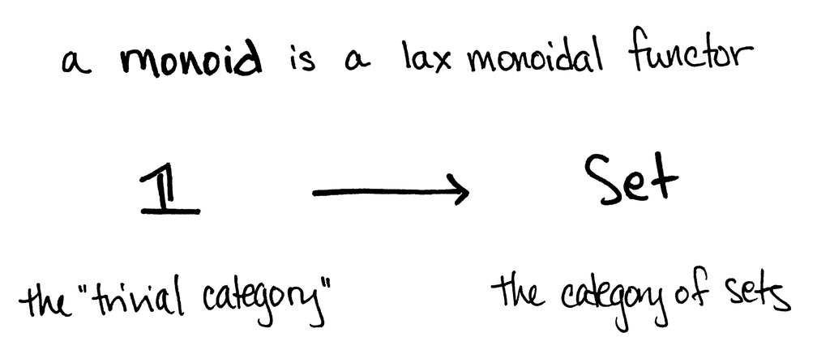

这里，我把$\mathbb{1}$和$\textsf{Set}$都看成幺半范畴。符号$\mathbb{1}$表示只有一个对象、一个态射（恒等态射）的范畴；它可以以唯一的方式被视为幺半范畴$(\mathbb{1},\otimes,\mathbb{1})$。集合范畴具有由笛卡尔积给出的幺半结构，幺半单位对象是只有一个元素的集合，记为$\{\ast\}$。因此，严格地说，

Here I’m viewing both $\mathbb{1}$ and $\textsf{Set}$ as monoidal categories. The symbol $\mathbb{1}$ is meant to represent the category with one object and only one morphism (the identity), which we can view as a monoidal category $(\mathbb{1},\otimes,\mathbb{1})$ in exactly one way. The category of sets has a monoidal structure given by the Cartesian product with the set containing one element, denoted $\{\ast\}$, as the monoidal unit. *Technically* then,

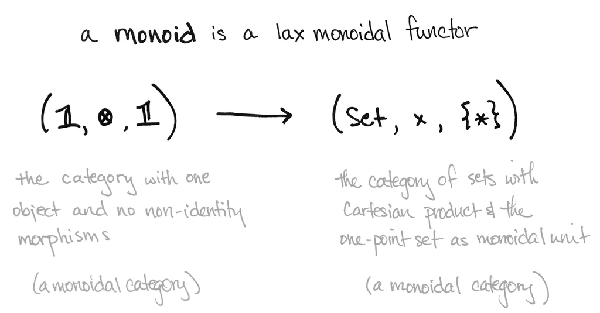

[^16]为什么如此？首先注意，函子$F\colon \mathbb{1}\to\textsf{Set}$选出了一个集合$F\mathbb{1}:=M$。而松幺半函子$F\colon (\mathbb{1},\otimes,\mathbb{1}) \to (\textsf{Set},\times,\{\ast\})$的数据包括一个态射
$$\bullet\colon F\mathbb{1}\times F\mathbb{1}\to F(\mathbb{1}\otimes \mathbb{1}) \qquad \text{i.e.}\qquad \bullet\colon M\times M\to M$$
，以及另一个态射
$$1\colon \{\ast\}\to F\mathbb{1}\qquad \text{i.e.}\qquad 1\colon \{\ast\}\to M$$
，两者都必须使某些图交换。我不在这里画出这些图，不过其中一张图的意思是“$\bullet$满足结合律”，另一张图的意思是“$1$充当$\bullet.$的单位元”。总之，松幺半函子$F\colon (\mathbb{1},\otimes,\mathbb{1}) \to (\textsf{Set},\times,\{\ast\})$的数据包括：

[^16] Why is this true? First observe that a functor $F\colon \mathbb{1}\to\textsf{Set}$ picks out a set, $F\mathbb{1}:=M$. And the data of a *lax monoidal* functor $F\colon (\mathbb{1},\otimes,\mathbb{1}) \to (\textsf{Set},\times,\{\ast\})$ consists of a morphism
$$\bullet\colon F\mathbb{1}\times F\mathbb{1}\to F(\mathbb{1}\otimes \mathbb{1}) \qquad \text{i.e.}\qquad \bullet\colon M\times M\to M$$
along with a morphism
$$1\colon \{\ast\}\to F\mathbb{1}\qquad \text{i.e.}\qquad 1\colon \{\ast\}\to M$$
both of which are required to fit into some commuting diagrams. I won’t write them here, but one diagram says “$\bullet$ is associative” and the other diagram says, “$1$ serves as an identity for $\bullet.$” In summary, the data of a lax monoidal functor $F\colon (\mathbb{1},\otimes,\mathbb{1}) \to (\textsf{Set},\times,\{\ast\})$ are

1. 一个集合$M$；

   a set $M$
2. 一个满足结合律的二元运算$\bullet\colon M\times M\to M$；

   an associative binary operation $\bullet\colon M\times M\to M$
3. 一个特殊元素$1:=1(\{\ast\})\in M$，它充当$\bullet$的“乘法单位元”。

   a special element $1:=1(\{\ast\})\in M$ that serves as a “multiplicative identity” for $\bullet$.

这个三元组$(M,\bullet,1)$恰好就是幺半群！借用Lawvere的说法，这个函子，等价地说这个幺半群，就是在$\textsf{Set}$中对范畴$\mathbb{1}$的一种解释。有趣的是，$\mathbb{1}$还可以在其他范畴中得到解释，从而产生其他熟悉的幺半结构。事实上，如果把$(\textsf{Set},\times,\{\ast\})$换成任意幺半范畴$(\textsf{C},\otimes,1)$，那么松幺半函子
$$(\mathbb{1},\otimes,\mathbb{1})\to(\textsf{C},\otimes,1)$$
就是范畴$\textsf{C}$中的幺半群。有时，这种幺半群有一个熟悉的名字。下面是几个例子。

This triple $(M,\bullet,1)$ is *precisely* a monoid! Or to borrow from Lawvere’s terminology, the functor (equivalently, the monoid) is one *interpretation* of the category $\mathbb{1}$ in the $\textsf{Set}$. Interestingly, $\mathbb{1}$ may be interpreted in other categories as well. This leads to other familiar monoidal structures. Indeed, if we replace $(\textsf{Set},\times,\{\ast\})$ by any monoidal category $(\textsf{C},\otimes,1)$, then a lax monoidal functor
$$(\mathbb{1},\otimes,\mathbb{1})\to(\textsf{C},\otimes,1)$$
is a **monoid in the category $\textsf{C}$**. Sometimes this monoid goes by a familiar name. Here are some examples.

- 令$(\textsf{Top},\times,\ast)$表示由拓扑空间和连续映射组成的范畴[^17]，并把它看成一个幺半范畴：幺半积为笛卡尔积$\times$，幺半单位对象为单点空间$\ast$。松幺半函子
  $$(\mathbb{1},\otimes,\mathbb{1}) \to (\textsf{Top},\times,\ast)$$
  就是拓扑幺半群。也就是说，拓扑幺半群就是拓扑空间范畴中的幺半群。

  Let $(\textsf{Top},\times,\ast)$ denote the category of topological spaces and continuous functions, [^17] viewed as a monoidal category with the Cartesian product $\times$, with the one-point space $\ast$ as monoidal unit. A lax monoidal functor
  $$(\mathbb{1},\otimes,\mathbb{1}) \to (\textsf{Top},\times,\ast)$$
  is a topological monoid. That is, **a topological monoid is a monoid in the category of topological spaces.**
- 令$(\textsf{AbGroup},\otimes,\mathbb{Z})$表示由阿贝尔群（视为$\mathbb{Z}$模）和阿贝尔群同态组成的范畴，并把它看成一个幺半范畴：幺半积为张量积$\otimes$，幺半单位对象为整数$\mathbb{Z}$。松幺半函子
  $$(\mathbb{1},\otimes,\mathbb{1}) \to (\textsf{AbGroup},\otimes,\mathbb{Z})$$
  就是一个有单位元的环。也就是说，环就是阿贝尔群范畴中的幺半群。

  Let $(\textsf{AbGroup},\otimes,\mathbb{Z})$ denote the category of abelian groups (viewed as $\mathbb{Z}$-modules) and abelian group homomorphisms, viewed as a monoidal category with the tensor product $\otimes$, with the integers $\mathbb{Z}$ as monoidal unit. A lax monoidal functor
  $$(\mathbb{1},\otimes,\mathbb{1}) \to (\textsf{AbGroup},\otimes,\mathbb{Z})$$
  is a ring (with unit). That is, **a ring is a monoid in the category of abelian groups.**
- 令$(\textsf{FVect},\otimes,\mathbb{k})$表示由域$\mathbb{k}$上的有限维向量空间和线性映射组成的范畴，并把它看成一个幺半范畴：幺半积为张量积$\otimes$，幺半单位对象为$\mathbb{k}$。松幺半函子
  $$(\mathbb{1},\otimes,\mathbb{1}) \to (\textsf{FVect},\otimes,\mathbb{k})$$
  就是一个有单位元的代数。也就是说，代数就是向量空间范畴中的幺半群。

  Let $(\textsf{FVect},\otimes,\mathbb{k})$ denote the category of finite-dimensional vector spaces over a field $\mathbb{k}$ and linear maps, viewed as a monoidal category with the tensor product $\otimes$, with $\mathbb{k}$ as monoidal unit. A lax monoidal functor
  $$(\mathbb{1},\otimes,\mathbb{1}) \to (\textsf{FVect},\otimes,\mathbb{k})$$
  is an algebra (with unit). That is, **an algebra is a monoid in the category of vector spaces.**
- 令$\textsf{C}$为一个范畴，令$\textsf{End}_\textsf{C}$表示这样一个范畴：其对象是函子$\textsf{C}\to\textsf{C}$，其态射是自然变换。（所以，$\textsf{End}_\textsf{C}$是$\textsf{C}$上的自函子范畴。）注意，$\textsf{End}_\textsf{C}$可以具有幺半范畴的结构：幺半积为函子的复合，也就是说，如果$F,G$是$\textsf{End}_\textsf{C}$中的对象，那么$F$和$G$的幺半积就是$F\circ G$；幺半单位对象是$\textsf{C}$上的恒等函子$1_{\textsf{C}}$，即$1_{\textsf{C}}$把$\textsf{C}$中的每个对象和态射都映到它自身。于是，松幺半函子
  $$(\mathbb{1},\otimes,\mathbb{1}) \to (\textsf{End}_\textsf{C},\circ,1_{\textsf{C}})$$
  就是单子。也就是说，单子就是$\textsf{C}$上的自函子范畴中的幺半群。

  Let $\textsf{C}$ be a category and let $\textsf{End}_\textsf{C}$ denote the category whose objects are functors $\textsf{C}\to\textsf{C}$ and whose morphisms are natural transformations. (So $\textsf{End}_\textsf{C}$ is the category of *endofunctors* on $\textsf{C}$.) Note that $\textsf{End}_\textsf{C}$ can be given the structure of a monoidal category: the monoidal product is composition of functors (i.e. if $F,G$ are objects in $\textsf{End}_\textsf{C}$, then the monoidal product of $F$ and $G$ is $F\circ G$), and the monoidal unit is the identity functor $1_{\textsf{C}}$ on $\textsf{C}$ (i.e. $1_{\textsf{C}}$ assigns each object and morphism in $\textsf{C}$ to itself). Then a lax monoidal functor
  $$(\mathbb{1},\otimes,\mathbb{1}) \to (\textsf{End}_\textsf{C},\circ,1_{\textsf{C}})$$
  is a monad. That is, **a monad is a monoid in the category of endofunctors on $\textsf{C}$.**

你会注意到，在这些例子中，语义范畴$\textsf{C}$每变化一次，就会为充当句法范畴的$\mathbb{1}$带来一种不同的解释。挺有意思，对吧？更多细节可参阅Emily Riehl的《Category Theory in Context》中的定义1.6.3和5.1.1。

You’ll notice that in each of these examples, a change in the semantics category $\textsf{C}$ gives rise to a different interpretation of $\mathbb{1}$, which served as our syntax category. Pretty neat, right? For more details on the examples, see Emily Riehl’s *[Category Theory in Context](http://www.math.jhu.edu/~eriehl/context.pdf)* Definitions 1.6.3 and 5.1.1.

这就是函子语义学背后的想法。那么，它在应用范畴论中究竟怎么用呢？我们考察两个例子，也就是该领域的两个研究项目时，就会看到答案：一个来自化学，一个来自自然语言处理。在两个例子中，关键都是存在一个从句法范畴到语义范畴的保结构函子。先预览一下：

That’s the idea behind functorial semantics. Now, how is it used in applied category theory? We’ll see the answer when we look at the two examples—two research projects from the field—one from chemistry and one from natural language processing. In both examples, the *key* is the existence of a (structure-preserving) functor from a syntax category to a semantics category. Here’s a sneak preview:

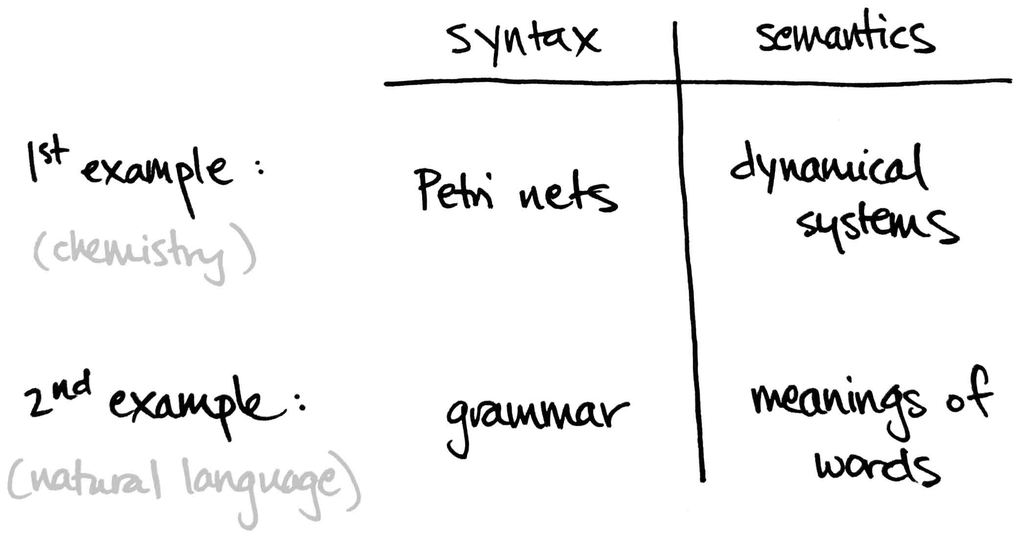

第3.1节将介绍如何用函子
$$\mathsf{Petri\;nets} \to \mathsf{dynamical\;systems}$$
模拟化学反应网络的行为，这来自John Baez和Blake Pollard的论文《A Compositional Framework for Reaction Networks》。第3.2节则通过Bob Coecke、Mehrnoosh Sadrzadeh和Stephen Clark在《Mathematical Foundations for a Compositional Distributional Model of Meaning》中的工作，介绍如何用函子
$$\mathsf{grammar} \to \mathsf{meanings\;of\;words}$$
描述自然语言模型。你或许在想：“$\mathsf{Petri\;nets}$、$\mathsf{dynamical\;systems}$、$\mathsf{grammar}$和$\mathsf{meanings\;of\;words}$怎么构成范畴？而且，Petri网究竟是什么？”接下来的内容会回答这些问题，不过我想先介绍应用范畴论的另一个重要主题：组合性。

In Section 3.1 we’ll see how the behavior of a chemical reaction network is modeled by a functor
$$\mathsf{Petri\;nets} \to \mathsf{dynamical\;systems}$$
as shown in [“A Compositional Framework for Reaction Networks”](https://arxiv.org/abs/1704.02051) by John Baez and Blake Pollard. In Section 3.2, we’ll see how a model for natural language can be described by a functor
$$\mathsf{grammar} \to \mathsf{meanings\;of\;words}$$
via the work of Bob Coecke, Mehrnoosh Sadrzadeh, and Stephen Clark in [“Mathematical Foundations for a Compositional Distributional Model of Meaning”](https://arxiv.org/abs/1003.4394). And perhaps you’re wondering, “How do $\mathsf{Petri\;nets}$, $\mathsf{dynamical\;systems}$, $\mathsf{grammar}$, and $\mathsf{meanings\;of\;words}$ form categories? And what’s a Petri net, anyway?” We’ll answer these questions in the pages to come, but first I’d like to introduce another important theme in applied category theory: compositionality.

### 组合性Compositionality

组合性，也叫组合性原则，又叫弗雷格原则[^18]，指的是：一个复杂表达式的意义由以下两点决定：

**Compositionality**, also known as the principal of compositionality, also known as Frege’s principle[^18], is the idea that the meaning of a complex expression is determined by

1. 其各个组成部分的意义；以及

   the meanings of its constituent parts, and
2. 这些部分组合起来的规则。

   the rules for how those parts are combined.

或者，用一本全新的、专门研究应用范畴论及相关领域的期刊主页上的简洁说法：

Or, as succinctly stated on the homepage of the [brand new journal](http://www.compositionality-journal.org/) of applied-category-theory-and-related-fields,

> 组合性描述并量化了复杂事物如何由较简单的部分组装而成。

> **compositionality** describes and quantifies how complex things can be assembled out of simpler parts.

巧的是，这本期刊本身就叫《Compositionality》[^19]，这也暗示了这个概念在该领域中的重要性。

As it turns out, the name of that journal is itself *Compositionality*,[^19] which hints at the importance of this concept within the field.

在第3.1节的化学例子中，复杂表达式是一个网络；如果你愿意，也可以说是一个庞大复杂的有向多重图。它的组成部分，就是这个网络中更小的片段。

In Section 3.1, which contains our example from chemistry, the complex expression will be a network—a big complicated directed multigraph, if you like. Its constituent parts are simply smaller chunks of the network.

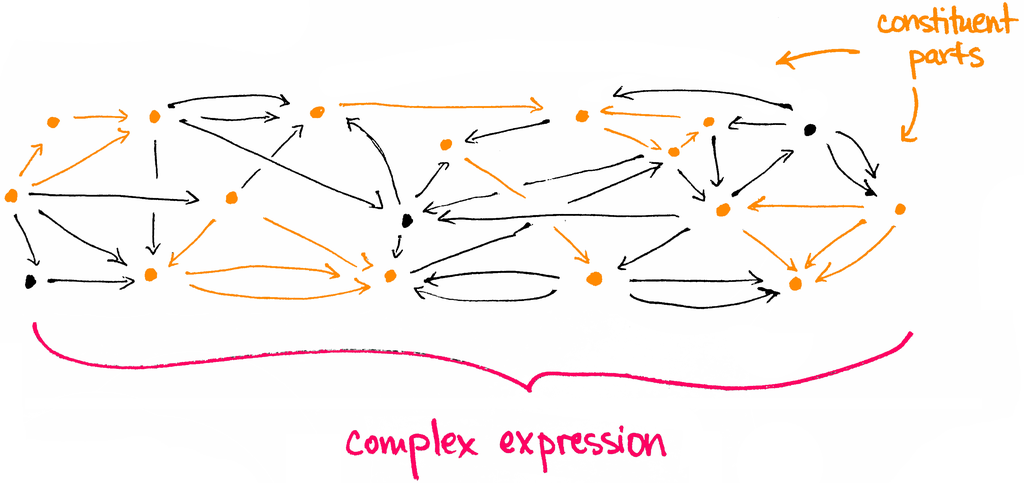

在第3.2节的自然语言例子中[^20]，复杂表达式是一句话，其组成部分就是构成这句话的词语。

In Section 3.2, [^20] our example from natural language, the complex expression will be a sentence; its constituent parts are the words that comprise the sentence.

在两个例子中，函子语义学与组合性原则都相辅相成。前者促使我们使用句法范畴与语义范畴之间的函子来模拟行为；后者鼓励我们逐个处理：组合性告诉我们，要为一个庞大的系统建模，只需先为其中较小的部分建模，再把它们拼起来。听上去够简单。不过，从数学上说，“把各部分拼起来”究竟是什么意思？幺半范畴的结构给出了答案。这就是我们要讨论的两种ACT主要构造中的第一种。

In both examples, functorial semantics and the principle of compositionality will go hand-in-hand. The former prompts us to model behavior using a functor between syntax and semantics categories. The latter encourages us to take things one at a time: *To model a huge system,* compositionality tells us, *it’s enough to model smaller pieces of it and then stick those pieces together.* Simple enough. But what does it mean to “stick pieces together” *mathematically*? The answer is provided by the structure of a **monoidal category**. And *that* is the first of our two main constructions in ACT.

### 延伸阅读Further Reading

关于函子语义学和组合性的更多内容：

**For more on functorial semantics and compositionality:**

- 想了解函子语义学的形式基础，可以看看William Lawvere在1963年的博士论文《Functorial Semantics of Algebraic Theories》，或者这篇关于它的简短介绍。

  Take a look at (this small notice on) William Lawvere’s 1963 PhD thesis [“Functorial Semantics of Algebraic Theories”](http://www.pnas.org/content/pnas/50/5/869.full.pdf) for the formal foundations for functorial semantics.
- 你或许也会喜欢$n$-Category Café上关于doctrines的这场讨论：https://golem.ph.utexas.edu/category/2006/09/doctrines.html

  You might also enjoy this discussion on *doctrines* over at the $n$-Category Café: https://golem.ph.utexas.edu/category/2006/09/doctrines.html
- Brendan Fong的博士论文《The Algebra of Open and Interconnected Systems》的前言对组合性原则有很好的讨论，并列出了多种参考资料。既然读到这里，不妨把整篇论文也看看：它写得非常精彩，也是John Baez目前许多网络理论研究的基础。第3.1节会略谈这些研究。

  The preface to Brendan Fong’s PhD thesis, [“The Algebra of Open and Interconnected Systems”](https://arxiv.org/abs/1609.05382), has a nice discussion on the principal of compositionality and includes various references. And while you’re at it, take a look at the entire thesis, which is wonderfully written and provides the backbone of much of John Baez’s current research in [network theory](http://math.ucr.edu/home/baez/networks/), which we’ll talk a little bit about in Section 3.1.
- 应用范畴论研究者Jules Hedges也写过一篇很好的组合性介绍，标题恰如其分，叫《On Compositionality》。文中还链接到了《斯坦福哲学百科全书》的“组合性”条目，后者对这个主题给出了全面综述。

  Applied category theorist Jules Hedges has also written a nice exposition on compositionality, appropriately entitled [“On Compositionality.”](https://julesh.com/2017/04/22/on-compositionality/) In the article, you’ll find a link to the Stanford Encyclopedia on Philosophy’s [entry on compositionality](https://plato.stanford.edu/entries/compositionality/), which gives a thorough overview of the topic.

## 两种构造Two Constructions

在应用范畴论的一些项目中，反复出现，反复、反复、再反复出现的两种构造，是幺半范畴和装饰余跨度。我们先谈第一种。

Two constructions that appear over and over (and *over and over and over*) in (some projects in) applied category theory are **monoidal categories** and **decorated cospans**. Let’s talk about the first one first.

### 幺半范畴Monoidal Categories

不过，在谈幺半范畴之前，先谈谈幺半群。[^21]这里有三个幺半群的例子：整数$\mathbb{Z}$、有理数$\mathbb{Q}$，以及所有具有实数元素的$n\times n$矩阵组成的集合$M_n(\mathbb{R})$。嗯，严格地说，下面这些才是幺半群：

Actually, before we talk about monoidal categories, let’s talk about *monoids*. [^21] Here are three examples of monoids: the *integers* $\mathbb{Z}$, the *rational numbers* $\mathbb{Q}$, and the set of all $n\times n$ *matrices* with real-number entries $M_n(\mathbb{R})$. Well, technically *these* are monoids:

$$(\mathbb{Z},+,0) (\mathbb{Q},\cdot,1) (M_n(\mathbb{R}),\cdot,\mathbb{1})$$

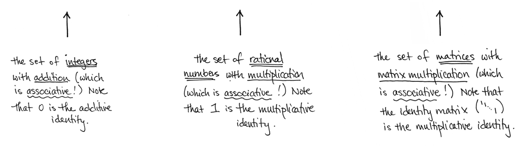

每个例子都由一个集合$X$，以及集合上一个满足结合律的二元运算组成；我把这个运算记作$\bullet$。[^22]此外，集合中还有一个特殊元素，姑且叫它$1$，它充当这个运算的单位元。这三样东西——集合、满足结合律的二元运算、单位元——就构成了幺半群。通常，我们把这个三元组写成
$$(X,\bullet,1)$$
。

Each example consists of a **set** $X$ equipped with an **associative binary operation**, which I’ll denote by $\bullet$. [^22] Moreover, there is a special element in the set, let’s call it $1$, that serves as an **identity** for the operation. *Those three things*—a set, an associative binary operation, an identity—comprise a **monoid**. Usually, we write this triple as
$$(X,\bullet,1)$$

不算太难，对吧？

Not too bad, right?

很好。现在，想象把集合$X$换成范畴$\textsf{C}$，把二元运算$\bullet\colon X\times X\to X$换成函子$\bullet\colon \textsf{C}\times \textsf{C}\to \textsf{C}$，把单位元$1\in X$换成$\textsf{C}$中的一个对象$1$。这样得到的三元组
$$(\textsf{C},\bullet,1)$$
就叫作幺半范畴。对象$1$通常称为幺半单位对象，而人们一般喜欢用$\otimes$，称为幺半积，来代替$\bullet$。我们也这样做：

Great. Now imagine replacing the set $X$ by a *category* $\textsf{C}$, and replacing the binary operation $\bullet\colon X\times X\to X$ by a *functor* $\bullet\colon \textsf{C}\times \textsf{C}\to \textsf{C}$, and replacing the identity element $1\in X$ by an *object* $1$ in $\textsf{C}$. The resulting triad
$$(\textsf{C},\bullet,1)$$
is called a **monoidal category**. The object $1$ is often called the *monoidal unit*, and people usually prefer to write $\otimes$ (and call it the *monoidal product*) instead of $\bullet$ so let’s do that too:

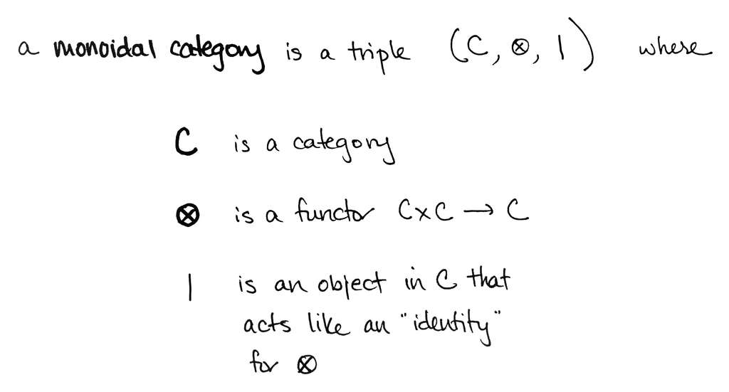

[^23]

简而言之，幺半范畴就是一个可以有意义地“组合”对象与态射的范畴。[^24]正如我们将在第3.1节和第3.2节看到的，第10页提到的四个范畴——$\mathsf{Petri\;nets},$ $\mathsf{dynamical}$ $\mathsf{systems},$ $\mathsf{grammar},$和$\mathsf{meanings\;of\;words},$——都是幺半范畴！下面再看几个例子。

In short, a monoidal category is a category in which it makes sense to “combine” objects and morphisms.[^24] As we’ll see in Sections 3.1 and 3.2, each of the four categories mentioned on page 10—$\mathsf{Petri\;nets},$ $\mathsf{dynamical}$ $\mathsf{systems},$ $\mathsf{grammar},$ and $\mathsf{meanings\;of\;words},$—are monoidal categories! Here are some more examples.

$$(\textsf{Set},\times,\{\ast\}) (\textsf{Top},\sqcup,\varnothing) (\textsf{FVect},\otimes,\mathbb{k})$$

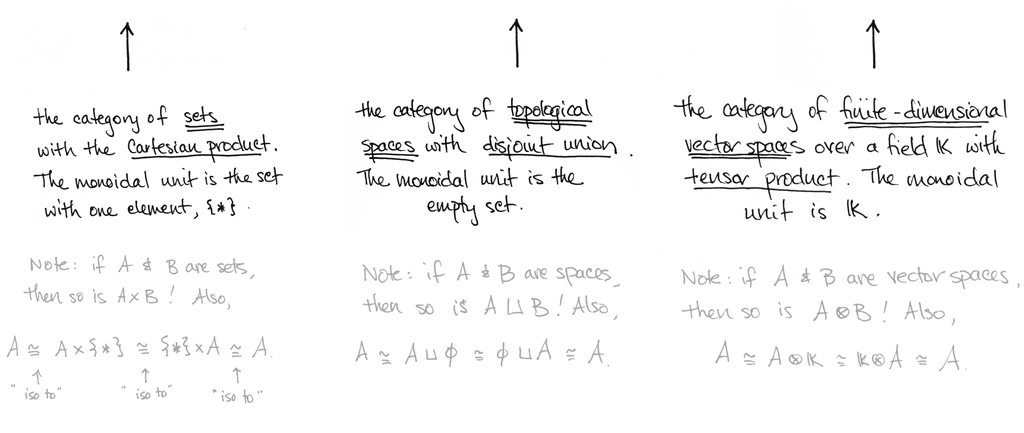

顺便说一句，如果对任意对象$A$和$B$，都存在同构$A\otimes B\cong B\otimes A$，并且它以某种可以精确定义的方式具有良好行为，那么我们就称$(\textsf{C},\otimes,1)$为对称幺半范畴。上面的三个例子都是对称幺半范畴。根据所满足的性质，幺半范畴还有其他类型，如辫状、笛卡尔、闭、笛卡尔闭、闭辫状，等等。

By the way, if there is an isomorphism $A\otimes B\cong B\otimes A$ for all objects $A$ and $B$ that behaves nicely in a sense that can be made precise, then we say that $(\textsf{C},\otimes,1)$ is a **symmetric monoidal category**. Each of the three examples above are symmetric monoidal. Monoidal categories come in other flavors too (braided, Cartesian, closed, Cartesian closed, closed braided,...), depending on which properties are satisfied.

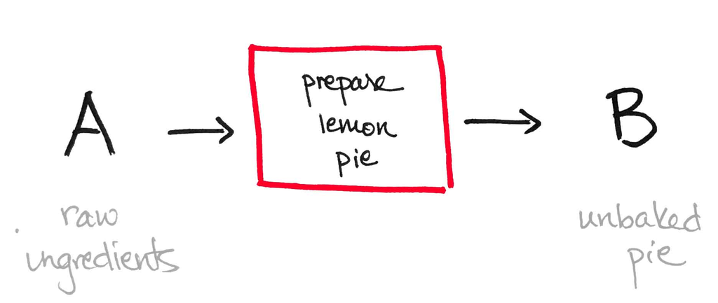

[^25]事实证明，派这个例子一点也不傻。Brendan Fong和David Spivak在他们出色的著作《Seven Sketches in Compositionality: An Invitation to Applied Category Theory》中，就用它作为启发性例子之一，说明幺半范畴既无处不在，又十分简单。（如果你还没读过《Seven Sketches》，真的很值得一读。）下面复制了他们的柠檬蛋白霜派图，我在左边画了作为输入的$A$，在右边画了作为输出的$B$。

[^25] As it turns out, this pie example isn’t so silly after all. It’s one of the motivating examples that Brendan Fong and David Spivak use in their **excellent** book [*Seven Sketches in Compositionality: An Invitation to Applied Category Theory*](https://arxiv.org/pdf/1803.05316.pdf) to illustrate both the ubiquity and the simplicity of monoidal categories. (If you haven’t read *Seven Sketches* yet, you really **must**.) Below is a copy of their lemon meringue pie diagram, where I’ve drawn our $A$ and $B$ on the left as input and right as output.

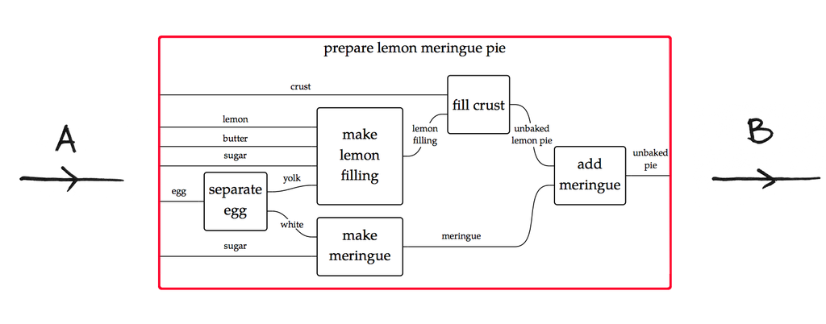

现在把图放大，我们就会看到，过程

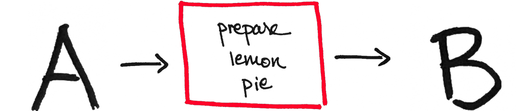

其实由许多其他过程组成！这并不奇怪，因为制作柠檬派本来就包含多个步骤：分离鸡蛋、制作柠檬馅、填入派皮，等等。Fong和Spivak的图说明了这些单独的步骤，究竟如何组合成“制作柠檬蛋白霜派”这一个过程。精彩之处在于，我们可以用幺半范畴的语言来描述这些步骤！本节稍后会详细说明，先预览一下：

Now that we’ve zoomed in, we can see that our process

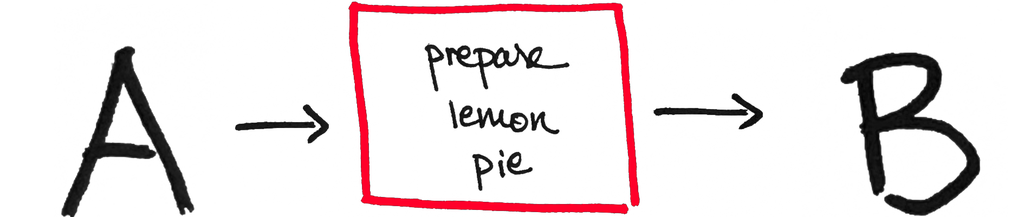

is actually made up of a bunch of other processes! This isn’t too surprising as there are several steps that go into preparing a lemon pie: *separating the eggs, making the lemon filling, filling the crust*, and so on. Fong and Spivak’s diagram illustrates just how those those individual steps combine to form the single process *prepare lemon meringue pie*. What’s neat is that we can describe these steps using the language of monoidal categories! We’ll go into more detail later in this section, but here’s a quick preview:

- 范畴中的复合$\circ$，对应于把一个方框的输出线用作另一个方框的输入线。例如：

  The category’s composition $\circ$ corresponds to using one box’s output wire as another box’s input wire. For example,

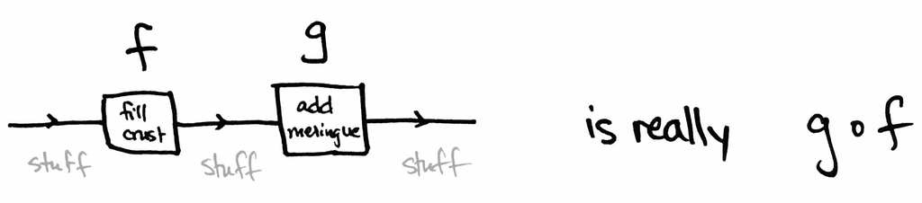

- 幺半积$\otimes$，对应于把方框上下叠放。例如：

  The monoidal product $\otimes$ corresponds to stacking boxes on top of each other. For example,

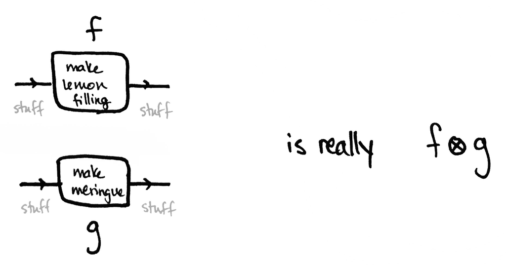

换句话说，$\circ$表示“串行执行这些过程”，幺半积$\otimes$表示“并行执行这些过程”。得到的图称为弦图，它是幺半范畴中一个过程或过程方程的图形表示。我马上会进一步介绍弦图的工作方式。不过，我先想起了另一件有关幺半范畴的事，想讲给你听！那就先讲这点新内容，再回到弦图。事实上，这一小段题外话会把前后的内容衔接得很好。请耐心听我说。

In other words, $\circ$ means “do the processes in series” while the monoidal product $\otimes$ means “do the processes in parallel.” The resulting picture is called a **string diagram**—a graphical representation of a process (or equation of processes) in a monoidal category. I’ll give more detail on how string diagrams work in a second. But first, I’m reminded of something else about monoidal categories that I want to tell you! So let me tell you this new bit of information, then we’ll come back to string diagrams. This small digression will, in fact, tie things together quite nicely. Bear with me.

前面提到过，“对称”可以用来修饰“幺半范畴”：

Earlier, I mentioned that the word “symmetric” can be used as an adjective for “monoidal categories”:

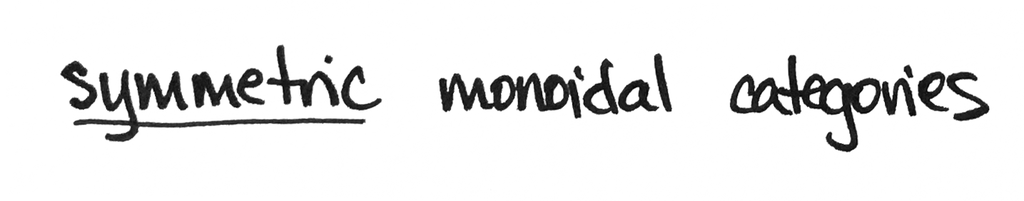

类似地，还有另一类我们需要了解的幺半范畴。它将为第3.2节的例子提供主要框架：

Similarly, there is another flavor of monoidal categories that we should know about. This one will provide the main setting for our example in Section 3.2:

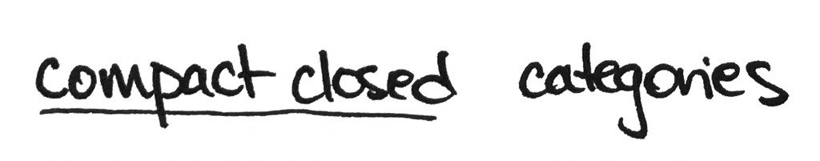

下面来解释。

I’ll explain.

### 插曲：紧闭范畴与弦图Interlude: Compact Closed Categories and String Diagrams

你知道什么是$\mathbb{R}$上的有限维向量空间吗？那么你就知道什么是紧闭范畴！或者更准确地说，你知道它的一个例子：
$$\textsf{FVect} \textit{ is a compact closed category}.$$
为什么可以这样说？答案是：每个有限维向量空间$V$都有对偶空间$V^*=\hom(V,\mathbb{R})$。

Do you know what a finite dimensional vector space over $\mathbb{R}$ is? Then you know what a compact closed category is! Or rather, you know an example of one:
$$\textsf{FVect} \textit{ is a compact closed category}.$$
What makes that sentence true? Answer: every finite dimensional vector space $V$ has a *dual* space $V^*=\hom(V,\mathbb{R})$.

就是这样。

*That’s it.*

紧闭范畴，不过是每个对象都有对偶的幺半范畴的名字！[^26]但“有对偶”是什么意思？换句话说，是什么让对偶成为对偶？在给出答案，也就是引用定义之前，我们先回想范畴$\textsf{FVect}$，从中获得一些直觉，并假定每个向量空间都带有内积。这时，在基域——暂且把它设为$\mathbb{R}$——与向量空间$V$和它的对偶的张量积之间，有两个非常重要的线性映射：
$$\eta_V\colon \mathbb{R}\to V\otimes V^* \qquad \qquad \epsilon_V\colon V^*\otimes V\to\mathbb{R}$$
事实上，线性代数中有个不错的结论：一旦给$V$选定一组基$\{\mathbf{e}_1,\ldots,\mathbf{e}_n\}$，就存在同构$V\cong V^*$。因此，我们固定这组基，也就是标准基，并用$V$代替$V^*$。另外，下标有点累赘，暂时也把它去掉。[^27]于是有两个映射
$$\begin{aligned}
\label{lis:ucounit}
\eta\colon \mathbb{R}\to V\otimes V \qquad \qquad \epsilon\colon V\otimes V\to\mathbb{R}
\end{aligned}$$
。映射$\eta$称为单位[^28]，它把每个实数映到$V\otimes V$中的一个向量，即：
$$\eta(1)=\sum_{i=1}^n \mathbf{e}_i\otimes \mathbf{e}_i \qquad \qquad\text{(and extend linearly)}$$
映射$\epsilon$称为余单位[^29]，它把$V\otimes V$中的每个向量映到一个实数，即：
$$\epsilon\left(\sum_{i,j}c_{ij}\mathbf{v}_i\otimes \mathbf{w}_j\right)=\sum_{i,j}c_{ij}(\mathbf{v}_i\cdot\mathbf{w}_j)\qquad\text{where $\cdot$ is the inner product}$$
直观上，我们可以把$\epsilon$看成求值映射，因为总是存在由求值给出的映射$V^*\otimes V\to\mathbb{R}$。确实，如果$\mathbf{v}\in V$且$f\in V^*$，就可以把两者配对得到$f\mathbf{v}\in \mathbb{R}.$。如果把$f$看成$1\times n$矩阵，把$\mathbf{v}$看成$n\times 1$矩阵，那么$f\mathbf{v}$就是它们的内积：
$$\begin{bmatrix}\cdots f \cdots
\end{bmatrix}
\begin{bmatrix}\vdots\\\mathbf{v}\\\vdots
\end{bmatrix} = \text{ a number}$$
。$\epsilon$映射只是将这一过程作线性延拓。也就是说，给定$V\otimes V,$中的任意向量$\sum_{i,j}c_{ij}\mathbf{v}_i\otimes \mathbf{w}_j$，$\epsilon\colon V\otimes V\to\mathbb{R}$就由上面的
$$\epsilon\left( \sum_{i,j}c_{ij} \mathbf{v}_i\otimes \mathbf{w}_i\right)=\sum_{i,j}c_{ij}(\mathbf{v}_i\cdot \mathbf{w}_j)$$
给出。

A **compact closed category** just the name for a monoidal category in which every object has a dual![^26] But what does “has a dual” mean? In other words, what makes a dual *dual*? Before I tell you the answer cite the definition, let’s think back to the category $\textsf{FVect}$, by way of motivation, and let’s assume each vector space comes with an inner product. In this case, there are two very important linear maps between the ground field—let’s say it’s $\mathbb{R}$ for now—and a vector space $V$ tensored with its dual:
$$\eta_V\colon \mathbb{R}\to V\otimes V^* \qquad \qquad \epsilon_V\colon V^*\otimes V\to\mathbb{R}$$
In fact, there’s a nice fact from linear algebra, namely that once we fix a basis $\{\mathbf{e}_1,\ldots,\mathbf{e}_n\}$ for $V$ then there is an isomorphism $V\cong V^*$. So let’s fix that basis (the standard one) and write $V$ instead of $V^*$. Also, the subscript is a little cumbersome, so let’s drop it for now. [^27] So we have two maps
$$\begin{aligned}
\label{lis:ucounit}
\eta\colon \mathbb{R}\to V\otimes V \qquad \qquad \epsilon\colon V\otimes V\to\mathbb{R}
\end{aligned}$$
The map $\eta$ is called the **unit** [^28], and it assigns to every real number a vector in $V\otimes V$, namely:
$$\eta(1)=\sum_{i=1}^n \mathbf{e}_i\otimes \mathbf{e}_i \qquad \qquad\text{(and extend linearly)}$$
The map $\epsilon$ is called the **counit**[^29], and it assigns to every vector in $V\otimes V$ a real number, namely:
$$\epsilon\left(\sum_{i,j}c_{ij}\mathbf{v}_i\otimes \mathbf{w}_j\right)=\sum_{i,j}c_{ij}(\mathbf{v}_i\cdot\mathbf{w}_j)\qquad\text{where $\cdot$ is the inner product}$$
Intuitively, we can think of $\epsilon$ as an *evaluation* map. That’s because there is always a map $V^*\otimes V\to\mathbb{R}$ given by evaluation. Indeed, if $\mathbf{v}\in V$ and $f\in V^*$, then we can pair the two together to obtain $f\mathbf{v}\in \mathbb{R}.$ And if we view $f$ as a $1\times n$ matrix and $\mathbf{v}$ as an $n\times 1$ matrix, then $f\mathbf{v}$ is their inner product:
$$\begin{bmatrix}\cdots f \cdots
\end{bmatrix}
\begin{bmatrix}\vdots\\\mathbf{v}\\\vdots
\end{bmatrix} = \text{ a number}$$
The $\epsilon$ map just extends this linearly. That is, if we now have *any* vector $\sum_{i,j}c_{ij}\mathbf{v}_i\otimes \mathbf{w}_j$ in $V\otimes V,$ then $\epsilon\colon V\otimes V\to\mathbb{R}$ is given by
$$\epsilon\left( \sum_{i,j}c_{ij} \mathbf{v}_i\otimes \mathbf{w}_i\right)=\sum_{i,j}c_{ij}(\mathbf{v}_i\cdot \mathbf{w}_j)$$
as above.

最后，单位$\eta$和余单位$\epsilon$彼此配合良好，因为它们满足一些称为“拉直方程”的等式，我马上就会解释。关键在于，上述所有内容——映射$\eta$和$\epsilon$，以及它们满足的方程——使$V^*$真正成为$V$的对偶。紧闭范畴就是对这些概念的推广。

Finally, the unit $\eta$ and counit $\epsilon$ interact nicely with each other because they satisfy some equations called the *yanking equations,* which I’ll explain shortly. The bottom line is that all the above—the maps $\eta$ and $\epsilon$ and the equations they satisfy—makes $V^*$ into a bona fide *dual* for $V$. The upshot is that compact closed categories generalize these notions.

定义2.1。

Definition 2.1.

紧闭范畴是这样一个幺半范畴$(\textsf{C},\otimes,1)$：对$\textsf{C}$中的每个对象$c$，都存在对象$c^l$和$c^r$，以及态射[^30]
$$\begin{aligned}
\eta_c^l\colon 1&\to c\otimes c^l\qquad\qquad \epsilon_c^l\colon c^l\otimes c\to 1\\
\eta_c^r\colon 1&\to c^r\otimes c\qquad\qquad \epsilon_c^r\colon c\otimes c^r\to 1
\end{aligned}$$
，满足“拉直方程（或蛇形方程）”[^31]
$$\label{eq:yank}
\begin{aligned}
&(\operatorname{id}_c \otimes \epsilon^l )\circ (\eta^l \otimes \operatorname{id}_c) = \operatorname{id}_c &\:& (\epsilon^r \otimes \operatorname{id}_c) \circ (\operatorname{id}_c \otimes \eta^r ) = \operatorname{id}_c
\\
&(\epsilon^l \otimes \operatorname{id}_{c^l})\circ (\operatorname{id}_{c^l} \otimes \eta^l)= \operatorname{id}_{c^l} &\:& (\operatorname{id}_{c^r} \otimes \epsilon^r ) \circ (\eta^r \otimes \operatorname{id}_{c^r} ) = \operatorname{id}_{c^r}
\end{aligned}$$
。

A **compact closed category** is a monoidal category $(\textsf{C},\otimes,1)$ where for every object $c$ in $\textsf{C}$ there exists objects $c^l$ and $c^r$ and morphisms [^30]
$$\begin{aligned}
\eta_c^l\colon 1&\to c\otimes c^l\qquad\qquad \epsilon_c^l\colon c^l\otimes c\to 1\\
\eta_c^r\colon 1&\to c^r\otimes c\qquad\qquad \epsilon_c^r\colon c\otimes c^r\to 1
\end{aligned}$$
that satisfy the “yanking (or snake) equations” [^31]
$$\label{eq:yank}
\begin{aligned}
&(\operatorname{id}_c \otimes \epsilon^l )\circ (\eta^l \otimes \operatorname{id}_c) = \operatorname{id}_c &\:& (\epsilon^r \otimes \operatorname{id}_c) \circ (\operatorname{id}_c \otimes \eta^r ) = \operatorname{id}_c
\\
&(\epsilon^l \otimes \operatorname{id}_{c^l})\circ (\operatorname{id}_{c^l} \otimes \eta^l)= \operatorname{id}_{c^l} &\:& (\operatorname{id}_{c^r} \otimes \epsilon^r ) \circ (\eta^r \otimes \operatorname{id}_{c^r} ) = \operatorname{id}_{c^r}
\end{aligned}$$

哎呀，这些方程到底是什么意思？

*Yikes. What do these equations MEAN?*

很高兴你问了这个问题。

I’m glad you asked.

要回答它，我们该回到前面关于弦图的讨论了！各地的应用范畴论研究者都喜爱弦图，因为它让事情简单太多了。[^32]正如前面所见，弦图是表示幺半范畴$\textsf{C}$中态射的图形。暂时把这个范畴取为$\textsf{FVect}$，这样对象就是向量空间$V,W,\ldots$。这时，空间$V$的左对偶和右对偶都是它的向量空间对偶
$$V^*= V^r=V^l$$
。我们很快就会回到拉直方程，不过先说一句：如果这篇笔记是你第一次接触弦图，下面就是你必须知道的关键！

To answer, it’s time to revisit our previous discussion on **string diagrams!** String diagrams are loved by applied category theorists far and wide because *they make life SO much easier.* [^32] As we saw earlier, a string diagram is a picture that represents morphisms in a monoidal category $\textsf{C}$. For now let’s take that category to be $\textsf{FVect}$ so that our objects are vector spaces $V,W,\ldots$. In this case, the left and right dual of space $V$ is its vector space dual
$$V^*= V^r=V^l$$
We’ll get to the yanking equations shortly, but first: If this document has been your first introduction into string diagrams, then here is THE KEY thing to know:

> 在范畴论中，我们常把对象画成点$\bullet$，把态射画成箭头$\bullet\to\circ$。要画弦图，把它们反过来就行！（这可以追溯到拓扑学中的庞加莱对偶。）画弦图时，把对象画成箭头，把态射画成点，或者更好地画成方框。[^33]

> In category theory, we often draw an object as a dot $\bullet$ and a morphism as an arrow $\bullet\to\circ$. To draw a string diagram, just **do the opposite!** (This goes back to [Poincaré duality](https://en.wikipedia.org/wiki/Poincar%C3%A9_duality) in topology.) To draw a string diagram, draw an object as an arrow and a morphism as a dot or, even better, a box. [^33]

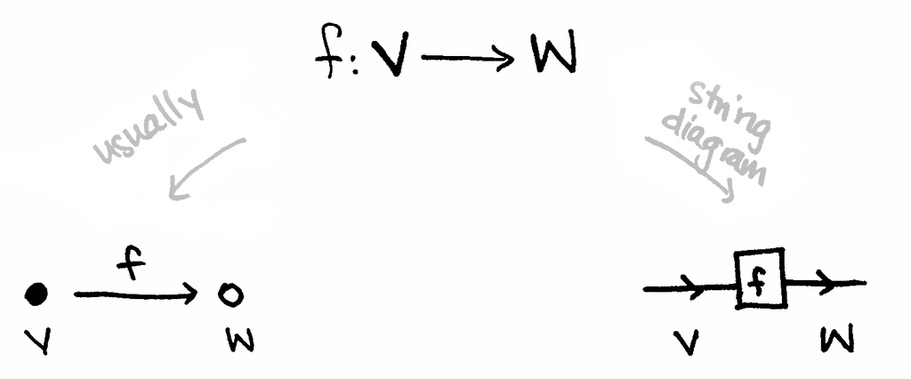

有了这个小小的画法调整，我们也能用图表示幺半积$\otimes$。两个空间的积$V\otimes W$画成两条并排的线。两个态射的积也有类似的画法。复合$\circ$则通过把弦连接起来表示。

With this small artistic adjustment, we can represent the monoidal product $\otimes$ pictorially as well. The product of two spaces $V\otimes W$ is drawn as two lines, side-by-side. A similar picture holds for the product of two morphisms. Composition $\circ$ is represented by gluing strings together.

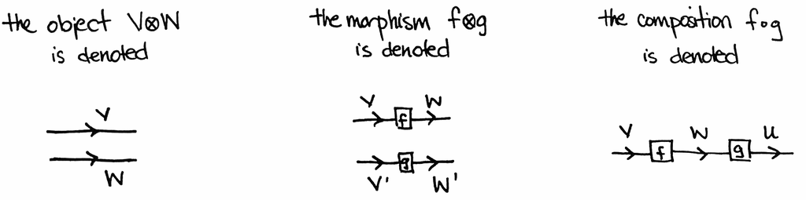

而且，正如前面所见，像$\textsf{FVect}$这样的紧闭范畴中，每个对象都有对偶。对偶画成指向相反方向的箭头。

And as we saw above, every object in a compact closed category such as $\textsf{FVect}$ has a dual. Its picture is given by an arrow pointing in the *opposite* direction.

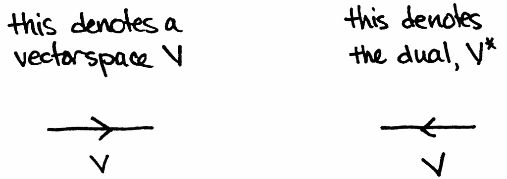

紧闭范畴中的另一个特殊对象是幺半单位对象，例如$\textsf{FVect}$中的$\mathbb{R}$。既然单位对象也是对象，它也用箭头表示。不过，人们喜欢用一种特殊画法，把它画成“空”箭头。换句话说，大家不喜欢把这根箭头画出来。原因是幺半单位对象$\mathbb{R}$满足[^34]
$$V\otimes \mathbb{R}\cong V\cong \mathbb{R}\otimes V \qquad\text{for all $V$},$$
，这意味着它似乎是“隐形”的。但我还是喜欢把它画出来，用淡色表示：

Another special object in a compact closed category is the monoidal unit, for instance $\mathbb{R}$ in $\textsf{FVect}$. Because the unit is an *object*, it’s depicted as an arrow, too. People like to draw this arrow in a special way, namely as the “empty” arrow. In other words, people don’t like to draw an arrow. That’s because the monoidal unit $\mathbb{R}$ satisfies[^34]
$$V\otimes \mathbb{R}\cong V\cong \mathbb{R}\otimes V \qquad\text{for all $V$},$$
which suggests that the unit is “invisible.” But I like to draw it anyway, shaded:

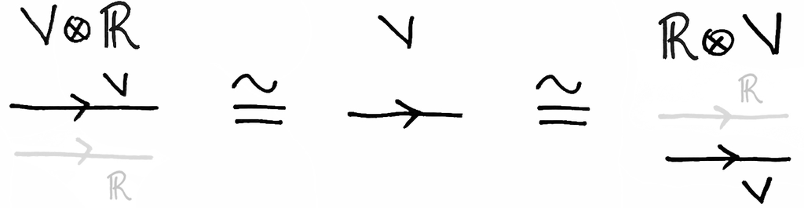

现在，我们可以回到拉直方程了。记住，紧闭范畴的一部分数据是：每个对象$V$都有左对偶和右对偶$V^r, V^l$，以及态射
$$\begin{aligned}
\eta_V^l\colon \mathbb{R}&\to V\otimes V^l\qquad\qquad \epsilon_V^l\colon V^l\otimes V\to \mathbb{R}\\
\eta_V^r\colon \mathbb{R}&\to V^r\otimes V\qquad\qquad \epsilon_V^r\colon V\otimes V^r\to \mathbb{R}
\end{aligned}$$
。为了简化记号，我们再次利用向量空间的这个事实：$V^*=V^r=V^l.$。我也会去掉下标，让记号更清爽。

Now we are ready to get back to the yanking equations. Remember, part of the data of a compact closed category is that each object $V$ has left and right duals $V^r, V^l$ *together with* morphisms
$$\begin{aligned}
\eta_V^l\colon \mathbb{R}&\to V\otimes V^l\qquad\qquad \epsilon_V^l\colon V^l\otimes V\to \mathbb{R}\\
\eta_V^r\colon \mathbb{R}&\to V^r\otimes V\qquad\qquad \epsilon_V^r\colon V\otimes V^r\to \mathbb{R}
\end{aligned}$$
Again, to simplify the notation we’ll use the fact that that for vector spaces, $V^*=V^r=V^l.$ I’ll also drop the subscripts to keep things clean.

从图形上看，各个$\eta$和$\epsilon$画成下面的样子。[^35]每个映射之所以都有两种版本，是因为“信息流”既可以向上，也可以向下。[^36]

Graphically, the $\eta$s and $\epsilon$s are drawn as below. [^35] The reason we have *two* versions of each map is because the “information flow” can either flow up or it can flow down.[^36]

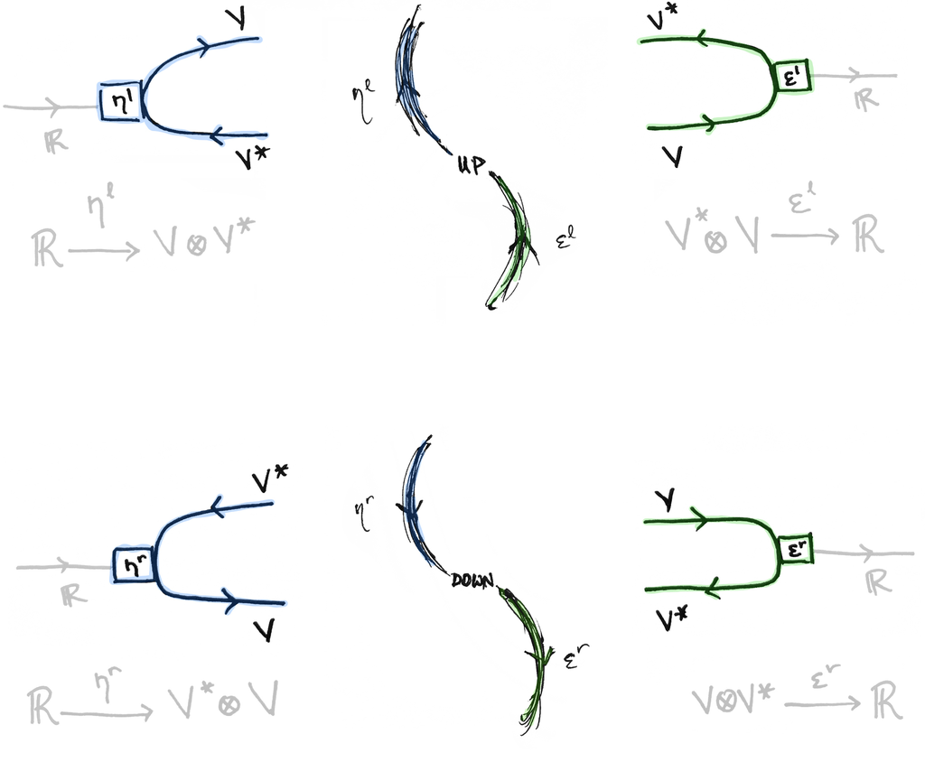

又因为$\mathsf{FVect}$是对称幺半范畴，而且左对偶和右对偶都是$V^*$，所以对于向量空间，实际上只有一个单位和一个余单位。[^37]

And since $\mathsf{FVect}$ is a *symmetric* monoidal category, and since the left and right duals are both $V^*$, there is really only *one* unit and *one* counit for vector spaces.[^37]

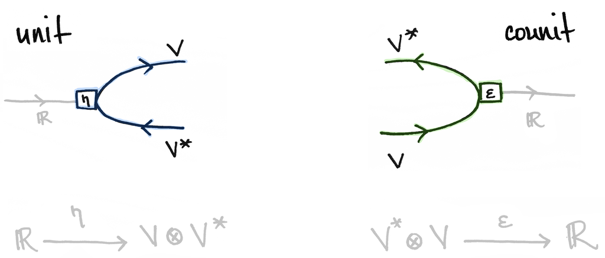

也就是说，在$\mathsf{FVect}$中，
$$\eta=\eta^r=\eta^l \qquad\text{and}\qquad\epsilon=\epsilon^r=\epsilon^l,$$
它们恰好就是第17页定义的$\eta$和$\epsilon$！所以，在这个例子中，式（2）的四个拉直方程简化为两个：
$$\label{eq:yankvect}
\begin{aligned}
(\epsilon \otimes \operatorname{id}_V)\circ (\operatorname{id}_V\otimes \eta)&=\operatorname{id}_V\\[7pt]
(\operatorname{id}_{V^*}\otimes\:\epsilon)\circ (\eta\otimes \operatorname{id}_{V^*})&=\operatorname{id}_{V^*}
\end{aligned}$$
。这些方程可以用图表示如下：[^38]

That is, in $\mathsf{FVect}$
$$\eta=\eta^r=\eta^l \qquad\text{and}\qquad\epsilon=\epsilon^r=\epsilon^l,$$
and these are *precisely* the $\eta$ and $\epsilon$ defined on page 17! So in this example, the four yanking equations of (2) reduce down to just *two*:
$$\label{eq:yankvect}
\begin{aligned}
(\epsilon \otimes \operatorname{id}_V)\circ (\operatorname{id}_V\otimes \eta)&=\operatorname{id}_V\\[7pt]
(\operatorname{id}_{V^*}\otimes\:\epsilon)\circ (\eta\otimes \operatorname{id}_{V^*})&=\operatorname{id}_{V^*}
\end{aligned}$$
Graphically, these equations can be represented as follows: [^38]

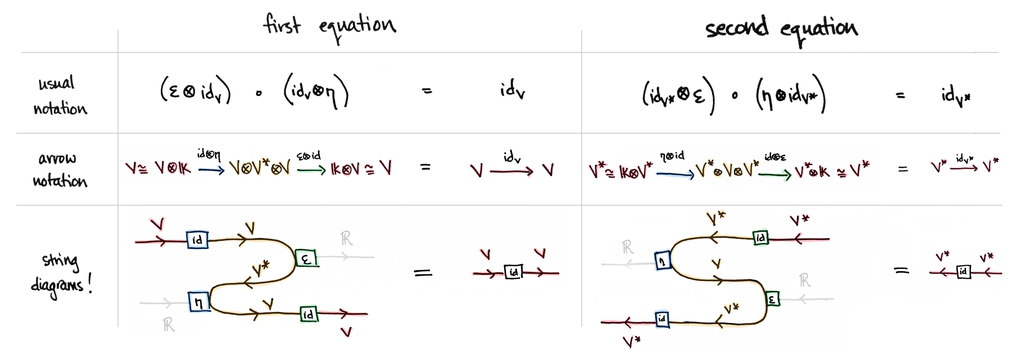

把弦拉直后，你会注意到，第一个方程中的信息向右流动，第二个方程中的信息向左流动。

After yanking the strings taut, you’ll notice that information flows *rightwards* in the first equation, while it flows *leftwards* in the second equation.

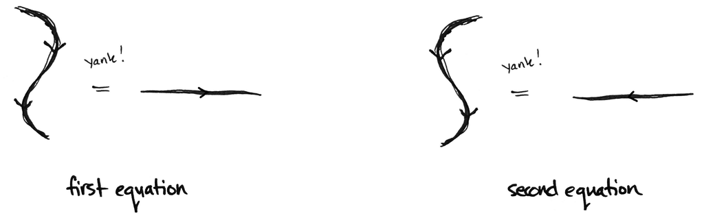

因为我们处于一个对称幺半范畴中，所以即使把拉直之前弦上的箭头反过来，也不会有任何变化。不过，如果幺半积$\otimes$不是对称的，就会再得到两张图。

Since we’re in a *symmetric* monoidal category, nothing changes if we reverse the arrows in the pre-yanked strings. If, however, the monoidal product $\otimes$ is not symmetric, then we obtain two more diagrams.

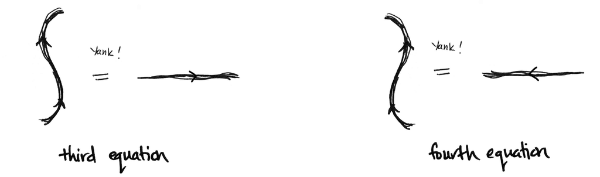

这样，总共就有四个方程，也就是式（2）中列出的四个方程。它们正是紧闭范畴结构所要求的。范畴$\mathsf{FVect}$连同式（1）中定义的单位和余单位，将在第3.2节再次出现。我们还会在同一节看到一个不是对称的紧闭范畴的例子。

This gives a grand total of four equations—the four displayed in (2). And that’s what gives us a compact closed category. The category $\mathsf{FVect}$ together with the unit and counit defined in (1) will make another appearance in Section 3.2. In that same section, we’ll also seen an example of a compact closed category that is *not* symmetric.

顺便说一句，$\mathsf{FVect}$，以及更一般的所有对称紧闭范畴，都有一个重要特征：过程，也就是态射$V\to W$，与状态$\mathbb{R}\to W\otimes V^*\cong V^*\otimes W$之间存在双射。这里，“状态”是定义域为幺半单位对象的态射的专门名称。这个双射有时称为“过程—状态对偶”；在$\mathsf{FVect},$的语境中，它意味着我们可以把线性映射看成张量积中的向量[^39]，反之亦然！

By the way, a key feature of $\mathsf{FVect}$ (and more generally, all symmetric compact closed categories) is that processes, i.e. morphisms, $V\to W$ are in bijection with *states* $\mathbb{R}\to W\otimes V^*\cong V^*\otimes W$, which is the special name given to morphisms whose domain is the monoidal unit. This bijection is sometimes called **process-state duality**, and in the context of $\mathsf{FVect},$ it means we can view linear maps as vectors in a tensor product[^39] and vice versa!

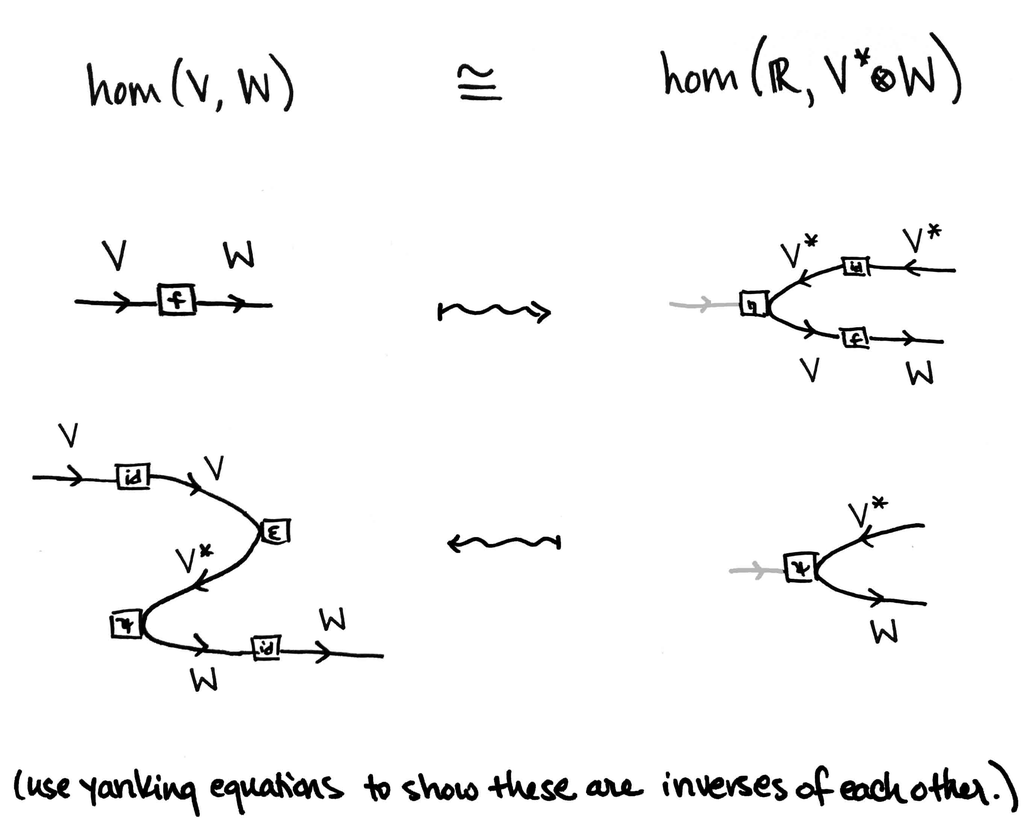

我喜欢这样理解：当$V$和$W$分别是带标准基的$\mathbb{R}^n$和$\mathbb{R}^m$时，过程—状态对偶连同前一页的页边注，类似于这样一个观察：矩阵可以看成向量，向量也可以看成矩阵。也就是说，线性映射$\mathbb{R}^n\to \mathbb{R}^m$有一个$m\times n$矩阵表示，可以把它重排成$nm\times 1$列向量，再与$\mathbb{R}^n\otimes \mathbb{R}^m$中的一个向量对应起来。反过来，$\mathbb{R}^n\otimes \mathbb{R}^m$中的一个向量可以对应于一个$nm\times 1$列向量，后者又可以重排成一个$n\times m$矩阵，从而得到一个线性映射$\mathbb{R}^n\to\mathbb{R}^m$。[^40]

I like to think of it this way: when $V$ and $W$ are $\mathbb{R}^n$ and $\mathbb{R}^m$ with the standard bases, process-state duality—taken together with the margin note on the previous page—is akin to the observation that matrices can be viewed as vectors and vice versa. That is, a linear map $\mathbb{R}^n\to \mathbb{R}^m$ has an $m\times n$ matrix representation which can be reshaped into an $nm\times 1$ column vector and then identified with a vector in $\mathbb{R}^n\otimes \mathbb{R}^m$. Conversely, there’s a way to identify a vector in $\mathbb{R}^n\otimes \mathbb{R}^m$ with an $nm\times 1$ column vector that can be reshaped into an $n\times m$ matrix, which gives rise to a linear map $\mathbb{R}^n\to\mathbb{R}^m$. [^40]

> 补充：我认为，有一种很好的范畴论方式可以把这些内容串起来。首先注意，存在一个范畴$\mathsf{Mat}(\mathbb{R})$，其对象是自然数$n,m,\ldots$，其态射$f\colon n \to m$是具有实数元素的$m\times n$矩阵。恒等态射$n\to n$是$n\times n$单位矩阵，复合由矩阵乘法给出。这个范畴实际上是一个紧闭范畴！对象上的幺半积由乘法$n\otimes m:=nm$给出，态射上的幺半积由矩阵的克罗内克积给出。幺半单位对象是$1\in \mathbb{N}$。在紧闭结构中，每个对象都是自对偶的，即$n^*:=n$；而对每个$n\in\mathbb{N}$，单位映射$\eta_n\colon 1\to n^2$是把标准基向量$\mathbf{e}_1,\ldots,\mathbf{e}_n$依次上下堆叠得到的$n^2\times 1$列向量。换句话说，$\eta$由克罗内克δ函数$\eta_{ij}:=\delta_{ij}$给出。余单位映射$\epsilon_n\colon n^2\to 1$是对$\eta_n$转置得到的$1\times n^2$行向量。例如，如果$n=3$，那么
> $$\eta_3=\begin{bmatrix}1&0&0&0&1&0&0&0&1\end{bmatrix}^\top$$
> [^41]，且$\epsilon_3=\eta_3^\top.$。由于$\mathsf{Mat}(\mathbb{R})$是紧闭的，它也具有过程—状态对偶：
> $$\hom(n,m)\cong \hom(1,nm)$$
> 。这个对应恰好就是把$n\times m$矩阵重排成$nm\times 1$列向量，反之亦然；使用单位和余单位映射，并仿照前一页底部弦图的做法，就可以验证这一点。为了把它与上一段中关于$\mathbb{R}^n$和$\mathbb{R}^m$的说明联系起来，注意存在一个函子$\mathsf{FVect}\overset{\cong}{\to}\mathsf{Mat}(\mathbb{R})$：它把向量空间$V$映到其维数$\text{dim}(V)$，把线性映射$f\colon V\to W$映到对应的$\text{dim}(W)\times \text{dim}(V)$矩阵表示，并且给出了范畴等价！详情可参见第30页的讨论，以及Emily Riehl的《Category Theory in Context》中的推论1.5.11。

> *Aside:* There is, I think, a nice categorical way to piece this together. First note that there is a category $\mathsf{Mat}(\mathbb{R})$ whose objects are natural numbers $n,m,\ldots$ and whose morphisms $f\colon n \to m$ are $m\times n$ matrices with real entries. The identity $n\to n$ is the $n\times n$ identity matrix and composition is given by matrix multiplication. This category is actually a compact closed category! The monoidal product on objects is given by multiplication $n\otimes m:=nm$ and on morphisms is given by the Kronecker product of matrices. The monoidal unit is $1\in \mathbb{N}$. For the compact closed structure, each object is self-dual, $n^*:=n$, and for each $n\in\mathbb{N}$ the unit map $\eta_n\colon 1\to n^2$ is the $n^2\times 1$ column vector obtained by stacking the standard bases vectors $\mathbf{e}_1,\ldots,\mathbf{e}_n$ on top of each other. In other words, $\eta$ is given by the Kronecker delta function $\eta_{ij}:=\delta_{ij}$. The counit map $\epsilon_n\colon n^2\to 1$ is the $1\times n^2$ row vector obtained by taking the transpose of $\eta_n$. For example, if $n=3$ then
> $$\eta_3=\begin{bmatrix}1&0&0&0&1&0&0&0&1\end{bmatrix}^\top$$
> [^41] and $\epsilon_3=\eta_3^\top.$ Since $\mathsf{Mat}(\mathbb{R})$ is compact closed, it exhibits process-state duality, too:
> $$\hom(n,m)\cong \hom(1,nm)$$
> This correspondence is precisely the reshaping of $n\times m$ matrices into $nm\times 1$ column vectors and vice versa, which can be verified by using the unit and counit maps in a way analogous to the string diagrams shown at the bottom of the previous page. To tie this in to the remark about $\mathbb{R}^n$ and $\mathbb{R}^m$ in the previous paragraph, note that there is a functor $\mathsf{FVect}\overset{\cong}{\to}\mathsf{Mat}(\mathbb{R})$ sending a vector space $V$ to its dimension $\text{dim}(V)$ and a linear map $f\colon V\to W$ to its corresponding $\text{dim}(W)\times \text{dim}(V)$ matrix representation, and it defines an equivalence of categories! For details, see the discussion on page 30 as well as Corollary 1.5.11 of Emily Riehl’s [*Category Theory in Context*](http://www.math.jhu.edu/~eriehl/context.pdf).

正如我们将在第3.2节看到的，过程—状态对偶性与我们对语言的直觉契合得非常好。在那里，我们会发现，一个动词既可以表示为若干向量空间的张量积中的一个向量，也可以表示为一个线性映射，也就是一个过程。换句话说，无论在语法还是数学眼中，动词都是一种动作！

As we’ll see in Section 3.2, process-state duality pairs very nicely with our intuition about language. There we’ll discover that a *verb* can either be represented as a vector in a tensor product of vector spaces *or* as a linear map, i.e. a process. In other words, a verb is an action in the eyes of both grammar and mathematics!

### 再岔开一下：与伴随结个伴？Another digression: A conjunction with adjunctions?

如果你熟悉范畴论中的伴随，可能会对这里的命名与记号选择感到好奇：
$$\eta \rightsquigarrow \textbf{``unit''}\qquad\qquad\qquad \epsilon\rightsquigarrow \textbf{``counit''}$$
这两个词也出现在伴随的定义里，难道只是巧合吗？当然不是。它们关系密切。具体来说，数据$V,V^*,\eta,$和$\epsilon$连同拉直方程，正是一个范畴论意义下的伴随的实例！我觉得这个事实很妙，[^42]所以我们就再岔开一下吧。好在这次岔题会与我们对弦图的讨论很好地衔接起来。我们先回顾伴随的定义。

If you’re familiar with adjunctions in category theory, then you might wonder about this choice of naming and notation:
$$\eta \rightsquigarrow \textbf{``unit''}\qquad\qquad\qquad \epsilon\rightsquigarrow \textbf{``counit''}$$
Is it a coincidence that these two words are *also* used in the definition of an *adjunction*? NOPE. They are closely related. Specifically, the data $V,V^*,\eta,$ and $\epsilon$ together with the yanking equations *are* an instance of a categorical adjunction! I think this is a neat fact,[^42] so let’s take yet another digression. Happily, it will tie in quite nicely with our discussion on string diagrams. We’ll begin by recalling the definition of an adjunction.

定义2.2。

Definition 2.2.

范畴$\textsf{C}$和$\textsf{D}$之间的一个伴随，由一对函子[^43]

[figure not shown]

和一对自然变换
$$\eta\colon \operatorname{id}_\textsf{C}\Longrightarrow RL\qquad\qquad \epsilon\colon LR\Longrightarrow \operatorname{id}_{\textsf{D}}$$
组成，后两者分别称为单位和余单位，并且使下面两个三角图交换：[^44]

[figure not shown]

$\qquad\qquad\qquad$

[figure not shown]

这个伴随记作$L\dashv R,$，我们称$L$为$R$的左伴随，而$R$为$L$的右伴随。

An **adjunction** between categories $\textsf{C}$ and $\textsf{D}$ is a pair of functors [^43]

[figure not shown]

and a pair of natural transformations
$$\eta\colon \operatorname{id}_\textsf{C}\Longrightarrow RL\qquad\qquad \epsilon\colon LR\Longrightarrow \operatorname{id}_{\textsf{D}}$$
called the **unit** and **counit** respectively, such that these two triangles commute: [^44]

[figure not shown]

$\qquad\qquad\qquad$

[figure not shown]

The adjunction is denoted $L\dashv R,$ and $L$ is said to be **left adjoint** to $R$ while $R$ is said to be **right adjoint** to $L$.

信不信由你，这两个交换三角图——通常称为三角恒等式——与式(3)中的拉直方程关系密切！事实上，“这两个三角图交换”的意思就是下面两个等式成立：
$$\begin{aligned}\label{eq:triangle}
(\epsilon\circ L)\circ(L\circ \eta)&=\operatorname{id}_L\\[7pt]
(R\circ \epsilon)\circ (\eta\circ R)&=\operatorname{id}_R
\end{aligned}$$
现在把它们与式(3)比较一下：
$$\begin{aligned}
(\epsilon \otimes \operatorname{id}_V)\circ (\operatorname{id}_V\otimes \eta)&=\operatorname{id}_V\\[7pt]
(\operatorname{id}_{V^*}\otimes\:\epsilon)\circ (\eta\otimes \operatorname{id}_{V^*})&=\operatorname{id}_{V^*}
\end{aligned}$$
为什么式(3)和式(4)如此相似？这是怎么回事？在某种意义下，一个向量空间与它的对偶空间会构成一个伴随吗？

Believe it or not, those commuting triangles—often called the *triangle identities*—are closely related to the yanking equations in (3)! Indeed, “these triangles commute” means that these two equations hold:
$$\begin{aligned}\label{eq:triangle}
(\epsilon\circ L)\circ(L\circ \eta)&=\operatorname{id}_L\\[7pt]
(R\circ \epsilon)\circ (\eta\circ R)&=\operatorname{id}_R
\end{aligned}$$
Now lets compare them to (3):
$$\begin{aligned}
(\epsilon \otimes \operatorname{id}_V)\circ (\operatorname{id}_V\otimes \eta)&=\operatorname{id}_V\\[7pt]
(\operatorname{id}_{V^*}\otimes\:\epsilon)\circ (\eta\otimes \operatorname{id}_{V^*})&=\operatorname{id}_{V^*}
\end{aligned}$$
Why are (3) and (4) so similar? *What’s going on here?* Is there a sense in which a vector space and its dual form an *adjunction*?

$V\dashv V^*$这样的东西存在吗？

Is $V\dashv V^*$ a thing?

存在！

*Yes!*

不过，要理解$V\dashv V^*$，我们得去2-范畴的世界探一探。2-范畴是讨论伴随等概念的合适场所。原因如下。根据上面的定义，我们知道，一个伴随由以下部分组成：

But to make sense of $V\dashv V^*$ we’ll need to venture into the world of *2-categories.* A 2-category is an appropriate setting in which to talk about adjunctions, among other things. Here’s why. As we know from the definition above, an adjunction consists of

1. 一些对象（范畴）[^45]

   some objects (categories) [^45]
2. 一些箭头（函子）

   some arrows (functors)
3. 一些箭头之间的箭头（自然变换）

   some arrows *between* the arrows (natural transformations)

它们构成了一个范畴！你会注意到，其中的对象与箭头本身构成了一个范畴，也就是所有范畴组成的范畴$\textsf{Cat}$。$\textsf{Cat}$的对象是范畴，态射是函子。

**These form a category!** You’ll notice that the objects and the arrows *themselves* form a category, namely $\textsf{Cat}$, the category of all categories. The objects of $\textsf{Cat}$ are categories and the morphisms are functors.

不错。

*Nice*.

不过，要是自然变换也能成为这些数据的一部分，就更好了。也就是说，如果这三者整体能构成一种已知的范畴论构造，那可就太好了。但照目前这样，还不行。范畴的定义没有给“箭头之间的箭头”这个概念留下位置。

It’d be even nicer, though, if the natural transformations were also part of the data. That is, it’d be *super nice* if the threesome itself constituted a known categorical construction. But as it stands, it doesn’t. There is no room for a notion of “arrows between arrows” in the definition of a category.

那我们该怎么办？

So what do we do?

拓展定义。就按字面意思来。我们多添一个维度，就得到了一个2-范畴。也就是说，一个2-范畴由以下部分组成：[^46]

We expand the definition. *Literally.* We add an extra dimension, which results in a 2-category. That is, a 2-category consists of [^46]

你或许已经猜到，2-范畴最典型的例子就是$\textsf{Cat}$，其中

As you might guess, the quintessential example of a 2-category is $\textsf{Cat}$, where the

因此，2-范畴很好地推广了我们在范畴、函子和自然变换之间看到的关系。推广了这三者以后，在任意2-范畴中谈论“伴随”就变得非常容易了。仿照定义[def:adj]，我们不妨提出下面这个定义：

So a 2-category is a good generalization of the relationship we see exhibited among categories, functors, and natural transformations. Having generalized this trio, it becomes very easy to talk about “adjunctions” in any 2-category. Parallel to Definition [def:adj], we might lay down the following proposed definition:

[figure not shown]

[figure not shown]

> $\qquad\text{and}\qquad$

[figure not shown]

> 并且使下面两个三角图交换

[figure not shown]

> $\qquad\qquad\qquad$

[figure not shown]

> ，也就是说，使以下等式成立[^47]

[figure not shown]

[figure not shown]

> $\qquad\text{and}\qquad$

[figure not shown]

> such that these two triangles commute

[figure not shown]

> $\qquad\qquad\qquad$

[figure not shown]

> i.e. such that the following equations hold[^47]

好吧，好吧。可这跟向量空间有什么关系？

Alright, fine. *But what does this have to do with vector spaces?*

答案就在下面这个很妙的事实里。

The answer lies in the following neat fact.

很妙的事实：每个幺半范畴$(\textsf{C},\otimes,1)$都可以看作一个2-范畴！

Neat Fact: Every monoidal category $(\textsf{C},\otimes,1)$ can be viewed  
as a 2-category!

呃，其实，我可不该传播谣言。

Er, actually, I shouldn’t spread rumors.

很妙的事实：每个幺半范畴$(\textsf{C},\otimes,1)$都可以看作一个2-范畴！

*Neat Fact: Every monoidal category $(\textsf{C},\otimes,1)$ can be viewed*  
*as a 2-category!*

正确的说法是：

Here’s the *correct* statement:

很妙的事实：每个幺半范畴$(\textsf{C},\otimes,1)$都可以看作一个双范畴！

Neat Fact: Every monoidal category $(\textsf{C},\otimes,1)$ can be viewed  
as a bicategory!

双范畴基本上就是一个2-范畴——两者的数据完全相同。都有0-胞、1-胞和2-胞。唯一的差别就是页边注里说的那一点。[^48] 因此，任意幺半范畴$(\textsf{C},\otimes,1)$都会给出一个双范畴$\mathcal{C}$，其中

A bicategory is basically a 2-category—the data is completely the same. There are 0-cells, 1-cells, and 2-cells. The only difference is what’s in the margin.[^48] So any monoidal category $(\textsf{C},\otimes,1)$ *gives rise to* a bicategory $\mathcal{C}$ where the

1. 唯一的0-胞是范畴$\textsf{C}$

   only 0-cell is the *category* $\textsf{C}$
2. 1-胞是$\textsf{C}$的对象；复合运算是$\otimes$

   1-cells are the *objects* of $\textsf{C}$; composition is $\otimes$
3. 2-胞是$\textsf{C}$的态射；复合运算是$\textsf{C}$中的复合$\circ$

   2-cells are the *morphisms* of $\textsf{C}$; composition is composition $\circ$ in $\textsf{C}$

因此，谈论$\mathcal{C}$中的1-胞（即$\textsf{C}$中的对象）具有伴随，是有意义的！而按照我们暂拟的定义，谈论$\mathcal{C}$中的2-胞（即$\textsf{C}$中的态射）是某个伴随的单位和余单位，也是有意义的！特别地，对称幺半范畴$(\textsf{FVect},\otimes,\mathbb{R})$也是如此。它给出一个双范畴$\mathcal{F}\mathsf{Vect}$，其中

Therefore it makes sense to talk about 1-cells in $\mathcal{C}$ (i.e. *objects* in $\textsf{C}$) having adjoints! And it makes sense to talk about 2-cells in $\mathcal{C}$ (i.e. *morphisms* in $\textsf{C}$) being units and counits of the adjunction, vis-a-vis our Proposed Definition! In particular, this is true of the symmetric monoidal category $(\textsf{FVect},\otimes,\mathbb{R})$. It gives rise to a bicategory $\mathcal{F}\mathsf{Vect}$ where the

1. 唯一的0-胞是范畴$\textsf{FVect}$

   only 0-cell is the category $\textsf{FVect}$
2. 1-胞是向量空间；复合运算是张量积$\otimes$

   1-cells are *vector spaces*; composition is the tensor product $\otimes$
3. 2-胞是线性映射；复合运算是通常的复合$\circ$

   2-cells are *linear maps*; composition is the usual composition $\circ$

所以，只要我们暂拟的定义中的条件成立，就存在向量空间的伴随$V\dashv W$。当然，这些条件恰好在$W=V^*$，且$\eta$和$\epsilon$按式(1)定义时成立。具体来说：

So there is an adjunction of vector spaces $V\dashv W$ whenever the conditions of our Proposed Definition hold. Of course, those conditions hold *precisely* when $W=V^*$ and $\eta$ and $\epsilon$ are defined as in (1). Explicitly:

[figure not shown]

> $\qquad\qquad\qquad$

[figure not shown]

> [^50]，也就是说，使下面的等式成立
> $$(\epsilon\otimes\operatorname{id}_V)\circ (\operatorname{id}_V\otimes \eta)=\operatorname{id}_V
> \qquad\text{and}\qquad
> (\operatorname{id}_{V^*}\otimes\: \epsilon)\circ (\eta\otimes \operatorname{id}_{V^*})=\operatorname{id}_{V^*}$$
> ，而这些正是第21页图表中所展示的弦图等式。

[figure not shown]

> $\qquad\qquad\qquad$

[figure not shown]

> [^50] i.e. so that the following equations hold
> $$(\epsilon\otimes\operatorname{id}_V)\circ (\operatorname{id}_V\otimes \eta)=\operatorname{id}_V
> \qquad\text{and}\qquad
> (\operatorname{id}_{V^*}\otimes\: \epsilon)\circ (\eta\otimes \operatorname{id}_{V^*})=\operatorname{id}_{V^*}$$
> and these are precisely the string diagram equations shown in the chart on page 21.

瞧，就是这样！

Voila!

最后，请注意，上面的论述对$\mathsf{FVect.}$中的每一个向量空间$V$都成立。另一方面，当然也存在这样的2-范畴：并非每个1-胞都可对偶化，也就是具有伴随。拿$\textsf{Cat}$来说吧！不是每个函子都是某个伴随的一部分。不过，对于那些确实来自幺半范畴$\mathsf{C}$、而且每个1-胞都有伴随的双范畴$\mathcal{C}$，有一个专门的名称。[^51]

Finally, notice that the above holds for *every* vector space $V$ in $\mathsf{FVect.}$ On the other hand, there are certainly 2-categories in which not every 1-cell is *dualizable*, i.e. has an adjoint. Take $\textsf{Cat}$ for instance! Not every functor is part of an adjunction. There *is*, however, a special name given to those bicategories $\mathcal{C}$ that do arise from a monoidal category $\mathsf{C}$ and in which every 1-cell has an adjoint. [^51]

这个名称就是紧闭。

That name is **compact closed.**

### 装饰余跨度Decorated Cospans

应用范畴论的一些研究中还会出现另一种构造：装饰余跨度。在任意范畴中，形如
$$A\to C\leftarrow B.$$
的图式称为余跨度。下一节中，我们只考虑$A,B,$和$C$都是有限集、箭头是它们之间的函数的情形。装饰余跨度就是中间的集合$C$被赋予了某种额外结构的余跨度。这是一个直观的定义，更精确的定义我想留到下一节再说。

A second construction that appears in some work within applied category is the *decorated cospan.* In any category, a diagram that looks like
$$A\to C\leftarrow B.$$
is called a **cospan**. In the next section, we’ll only consider the case when $A,B,$ and $C$ are finite sets and the arrows are functions between them. A **decorated cospan** is a cospan where the middle set $C$ has been endowed with some extra structure. That’s the intuitive definition, though I’d like to postpone a more precise definition until the next section.

你现在可能觉得，给$A\to C\leftarrow B$这么简单的一个图式起个名字，有点奇怪，不过余跨度可是经常派得上用场的！例如，如果由于某种原因，你根本不可能指望在对象$A$和$B$之间找到态射，那么一种常见技巧[^52]就是转而寻找一个“更大”的对象$C$，它同时“包含”$A$和$B$。这样，虽然你没有$A$与$B$之间的映射，却有了映射$A\to C\leftarrow B$。这时候，余跨度就是退而求其次的好选择。

Now you might think it strange to give a name to a simple diagram like $A\to C\leftarrow B$, but cospans come in handy quite often! For instance, if for some reason you can’t possibly hope to find a morphism between objects $A$ and $B$, a common technique[^52] is to instead look for a “larger” object $C$ that “contains” both $A$ and $B$. Then although you don’t have maps between $A$ and $B$, you *do* have maps $A\to C\leftarrow B$. In that case, your cospan is the [next best thing](https://twitter.com/math3ma/status/989233108137533442).

说实话，比起我们刚刚结束的那段关于幺半范畴的长篇大论，这一节实在是小菜一碟，但这可不是因为装饰余跨度没那么重要！事实上，Brendan Fong在博士论文《开放与互联系统的代数》（The Algebra of Open and Interconnected Systems）中发展了装饰余跨度理论；正如我前面提过的，这篇论文为应用范畴论中的许多进展奠定了基础。不过，在这份笔记里，我们只会在第3.1节简要讨论化学反应网络时用到余跨度构造。另一方面，在第3.1节和第3.2节中，我们都需要幺半范畴的语言。事实上，正如我们马上就会看到的，装饰余跨度本身就构成一个幺半范畴！

Admittedly, this section is *bite-sized* compared to the behemoth on monoidal categories that we just finished, but that’s not because decorated cospans are any less important! In fact, Brendan Fong developed the theory of decorated cospans as part of his PhD thesis [“The Algebra of Open and Interconnected Systems”](https://arxiv.org/pdf/1609.05382.pdf), which has served as the foundation for *much* progress in applied category theory, as I mentioned earlier. But in these notes, we’ll only use the cospan construction in our brief discussion on chemical reaction networks in Section 3.1. On the other hand, we will need the language of monoidal categories in both Sections 3.1 and 3.2. In fact, as we’ll soon see, decorated cospans *themselves* form a monoidal category!

### 延伸阅读Further Reading

关于幺半范畴和弦图的更多内容：

**For more on monoidal categories and string diagrams:**

- 请阅读Bob Coecke和Aleks Kissinger所著《图解量子过程》（Picturing Quantum Processes）的第3章和第4章。书中还更详细地介绍了如何把幺半范畴中的态射解释为过程、把对象解释为系统。

  Read Chapters 3 and 4 of [*Picturing Quantum Processes*](https://www.amazon.com/Picturing-Quantum-Processes-Diagrammatic-Reasoning/dp/110710422X) by Bob Coecke and Aleks Kissinger. There you’ll also find more information on the interpretation of morphisms in a monoidal category as *processes* and objects as *systems*.
- 看看Eugenia Cheng和Simon Willerton在TheCatsters系列中讲解弦图的视频吧。再一想，他们的整套视频都很棒。全都去看吧！

  Take a look at [TheCatsters videos](https://www.youtube.com/watch?v=USYRDDZ9yEc&list=PL50ABC4792BD0A086) on string diagrams, by Eugenia Cheng and Simon Willerton. On second thought, [their entire collection](http://www.simonwillerton.staff.shef.ac.uk/TheCatsters/) of videos is great. Go watch them all!
- 如果你喜欢$\infty$-范畴，那么你一定会很高兴地得知，在Emily Riehl与Dominic Verity合著的新书《$\infty$-范畴论基础》（Elements of ∞-Category Theory）第8章中，也出现了某种版本的弦图（被亲切地称为“严格起伏的弯弯曲曲线”），还有拉直方程（！）。这本书讲的是不依赖具体模型的$\infty$-范畴论。

  If you like $\infty$-categories, you’ll be delighted to know that a version of string diagrams (affectionately called “strictly undulating squiggles”) and the yanking equations (!) make an appearance in chapter 8 of [*Elements of $\infty$-Category Theory*](http://www.math.jhu.edu/~eriehl/ICWM.pdf), a new book on model-independent $\infty$-category theory by Emily Riehl and Dominic Verity.

关于装饰余跨度的更多内容：

**For more on decorated cospans:**

- 请阅读John Baez在$n$-Category Café上发表的博文“Decorated Cospans”（装饰余跨度）。

  Read [“Decorated Cospans”](https://golem.ph.utexas.edu/category/2016/01/decorated_cospans.html) a blog post by John Baez on the $n$-Category Café.
- 请阅读Brendan Fong与David Spivak所著《组合性七讲》（Seven Sketches in Compositionality）的第6章。在第6.1节中，作者给出了下面这段动机说明：

  Read Chapter 6 of [*Seven Sketches in Compositionality*](https://arxiv.org/pdf/1803.05316.pdf) by Brendan Fong and David Spivak. In Section 6.1, the authors give the following bit of motivation:

  > ……我们构造出一个特定的幺半范畴——即[范畴]$\textsf{C}$中的余跨度组成的范畴，记作Cospan$_\textsf{C}$——它可以用自身的基本运算，即复合运算与幺半结构，方便地把$\textsf{C}$中的余极限打包起来。总而言之，本章的第一部分围绕这样一句口号展开：“余极限为连接建模。”（强调为原作者所加）

  > ...we produce a certain monoidal category—namely that of *cospans in* [a category] $\textsf{C}$, denoted **Cospan**$_\textsf{C}$—that can conveniently package $\textsf{C}$’s colimits in terms of its own basic operations: composition and monoidal structure. In summary, the first part of this chapter is devoted to the slogan ‘colimits model connection.’ (emphasis theirs)

  正如我们将在第3.1节看到的，Cospan$_\textsf{C}$中的对象是$\textsf{C}$中的余跨度，而两个余跨度之间的态射则由一种叫作余极限的构造给出。与一般幺半范畴中的复合$\circ$和积$\otimes$一样，余极限也是一种能让你把东西连接起来的范畴论构造。不过，考虑到“时间”（也就是说，免得这份文档一不小心变成一本书……），我会假定你已经熟悉余极限。如果你想直观地了解余极限及其对偶构造——极限，我推荐你

  As we’ll see in Section 3.1, objects in **Cospan**$_\textsf{C}$ are cospans in $\textsf{C}$ and a morphism between two cospans is given by a construction called a *colimit*. Like the composition $\circ$ and product $\otimes$ in a general monoidal category, a colimit is a categorical construction that allows you to connect things together. But for the sake of “time” (i.e. so that this document doesn’t accidentally turn into a *book*...), I’ll assume familiarity with colimits. But if you’d like to an intuitive introduction of colimits, as well as their dual construction, limits, I recommend that you
- 看看Math3ma上的博文“Limits and Colimits (Part 1)”（极限与余极限，第1部分）。也可以参阅《组合性七讲》的第3章和第6章，以及Emily Riehl所著《语境中的范畴论》（Category Theory in Context）的第3章。

  Take a look at [“Limits and Colimits (Part 1)”](http://www.math3ma.com/mathema/2018/1/2/limits-and-colimits-part-1) a blog post on Math3ma. Also see chapters 3 and 6 of [*Seven Sketches*](https://arxiv.org/pdf/1803.05316.pdf) and chapter 3 of [*Category Theory in Context*](http://www.math.jhu.edu/~eriehl/context.pdf) by Emily Riehl.

## 两个例子Two Examples

我们已经悠闲地漫步于应用范畴论的两个主题（函子语义学与组合性）和两种构造（幺半范畴与装饰余跨度）之间，现在该通过两个例子，看看它们如何鲜活起来了。正如引言中所说，第一个例子——化学反应网络——我们会讲得相对简略一些。网上有许多很棒的资源，包括John Baez在$n$-Category Café及其个人网页上的讲解。（第3.3节中，我列出了一些相关链接。）随后，我们会在第3.2节中多花些时间，漫游第二个例子——自然语言处理。

Having taken a leisurely stroll through two themes (functorial semantics and compositionality) and two constructions (monoidal categories and decorated cospans) within applied category theory, it’s time to see them come to life in two examples. As mentioned in the introduction, we’ll walk through the first example—chemical reaction networks—relatively quickly. There are several excellent resources available online, including John Baez’s expositions on the $n$-Category Café as well as on his personal webpage. (I’ve included a few links to these in Section 3.3.) Afterwards we’ll take a longer stroll through the second example—natural language processing—in Section 3.2.

### 化学反应网络Chemical Reaction Networks

第一个例子来自John Baez与Blake Pollard的论文“A Compositional Framework for Reaction Networks”（反应网络的组合式框架）。具体来说，他们提供了一个为化学反应网络建模的组合式框架。化学反应网络嘛，就是由化学反应组成的网络。而化学反应，也就是你想的那种东西。高中时你就学过了：一开始有一些反应物和一些生成物，然后有一个把前者变成后者的化学过程。

The first example comes from a paper by John Baez and Blake Pollard called [“A Compositional Framework for Reaction Networks.”](https://arxiv.org/abs/1704.02051) Specifically, they provide a compositional framework for modeling *chemical* reaction networks. A **chemical reaction network** is, well, a network of chemical reactions. And a **chemical reaction** is exactly what you think it is. It’s what you learned back in high school: You start with some reactants and some products, and there’s a chemical process that takes one to the other.

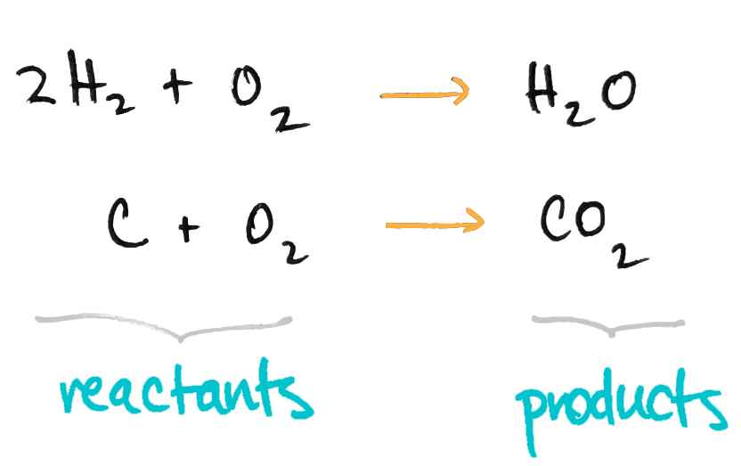

很妙的是，这些反应可以画成图：

What’s nice is that these reactions can be depicted graphically:

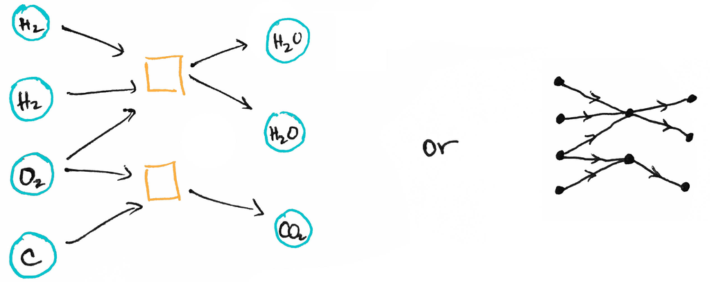

当然，你可以想象，反应物、生成物和化学过程可能有很多种。相应的网络就是一大堆这样的图并排放在一起（规模可能非常庞大），也许还有连接的边、回路等等。例如，下面这个化学反应网络就在Baez于2016年的演讲“The Mathematics of Networks”（网络的数学）中短暂亮过相：

Of course, you can imagine that there might be *lots* of various reactants, products, and chemical processes. The corresponding *network* would then be a (possibly huge) collection of these graphs stacked side-by-side, perhaps with connecting edges and loops and so on. For instance, this chemical reaction network made a cameo appearance in Baez’s 2016 talk [“The Mathematics of Networks”](https://www.youtube.com/watch?v=IyJP_7ucwWo):

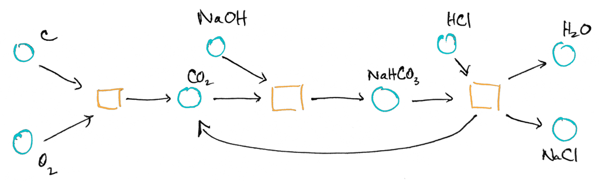

这样的图是Petri网的例子。Petri网本质上是一种二部有向（多重）图，让我们能够直观地表示反应，不过它们在化学以外也有应用。

Graphs such as these are examples of Petri nets. A **Petri net** is essentially a bipartite directed (multi)graph that allows us to visually represent reactions, though they are used outside of chemistry as well.

但如果我们确实想为化学反应建模，那么有一件重要的事需要考虑：一种或多种化学物质转化为另一种物质的速率。加入速率的Petri网，顾名思义，就叫作带速率的Petri网。更具体地说，它是一个二部有向图，两类顶点分别称为库所和变迁：库所表示化学物种，变迁表示化学反应。此外，每个变迁$\tau_i$都被赋予一个速率$r_i$，这是一个正实数，用来描述$\tau_i$发生得有多快，或者发生的可能性有多大。有了这些速率，我们就能写出描述这个系统的微分方程。因此，带速率的Petri网就是一组描述某个系统的微分方程的图示表示。举例来说，如果你确实看过Baez的“网络的数学”演讲，那么下面这个例子一定很眼熟：

But if we do wish to model chemical reactions, then an important thing we’d like to account for is the *rate* at which one or more chemicals change over to another. A Petri net with rates included is called, appropriately, a **Petri net with rates**. More specifically, it’s a bipartite directed graph whose two types of vertices are called places, which represent chemical species, and transitions, which represent chemical reactions. Moreover, each transition $\tau_i$ is assigned a *rate* $r_i$, a positive real number that describes how fast or how likely it is for $\tau_i$ to occur. These rates then allow us to write down differential equations that describe the system. A Petri net with rates is thus a pictorial representation of a set of differential equations that describe a system. So, for instance, if you *did* watch Baez’s [“The Mathematics of Networks”](https://www.youtube.com/watch?v=IyJP_7ucwWo) talk then this example will look familiar:

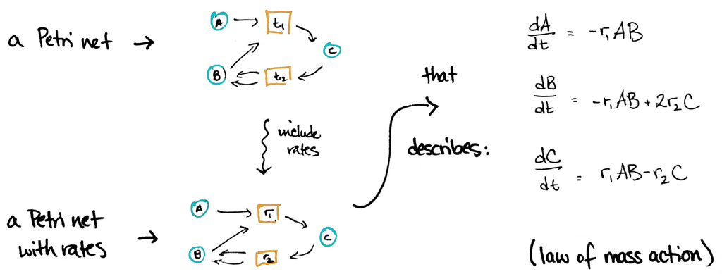

例如，它告诉我们，浓度分别为$A$和$B$的物质结合，以与$r_1.$成正比的速率生成浓度为$C$的物质。你看到的这些微分方程来自质量作用定律：化学反应发生的速率，等于它的速率常数$r_i$乘以各反应物浓度的乘积，也就是反应“输入”的浓度的乘积。

It tells us that, for example, substances with concentrations $A$ and $B$ combine and produce a substance with concentration $C$ at a rate proportional to $r_1.$ The differential equations you see are due to the **law of mass action**, which says that the rate with which a chemical reaction will occur is equal to its rate constant $r_i$ multiplied by the product of the concentration of the reactants, i.e. the concentration of the “inputs” of the reaction.

顺便说一句，这些速率本身也可能随时间变化，这就可能暗示着一个动力系统的存在。而且，像上面这样的系统还可能与环境相互作用，也就是说，可能有一些量流入、一些量流出，于是就得到了一个带速率的开放Petri网：

By the way, the rates themselves could change with time, which might suggest the presence of a **dynamical system.** What’s more, a system such as the above could potentially interact with its environment, which is to say there might be some quantities that flow in and some quantities that flow out, resulting in an **open Petri net with rates**:

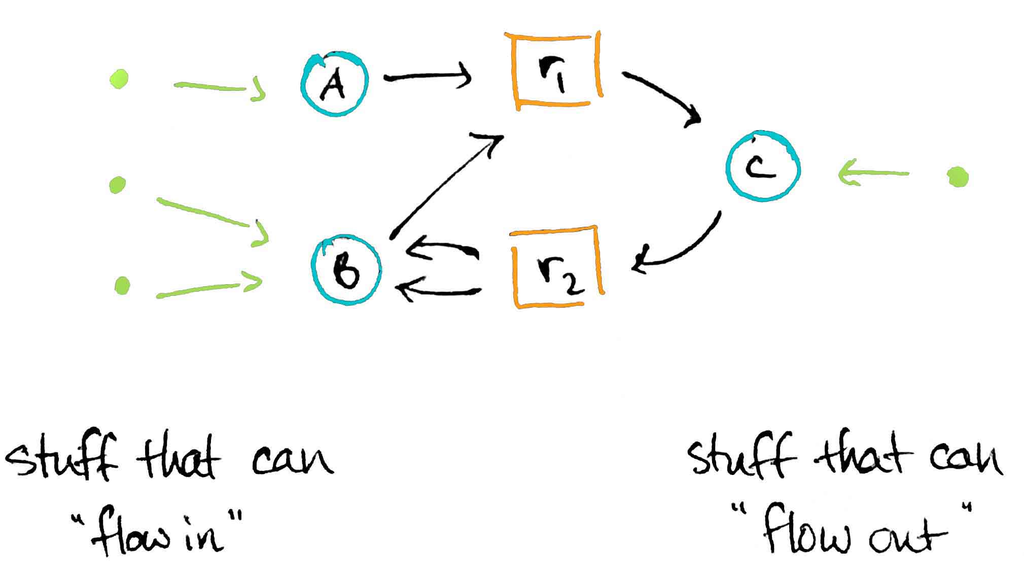

这些量也可以纳入方程，从而得到一个开放动力系统。正如Baez和Pollard总结的那样，目标是利用这些观察，“从较小的部分构建出一个反应网络，并且能根据各部分的速率方程来确定整个网络的速率方程”。这就是组合式框架的含义，也是第1.2节提到的组合性原理的一个典型例子。更妙的是，朝着这个目标迈进的关键一步，正是函子语义学！也就是说，我们首先把Petri网视为句法，把一组微分方程视为语义。如果我们有一组Petri网，为一个非常大的网络建模，那么在组合性原理的指引下，我们希望通过把图粘合在一起来复合它们，也希望通过把图上下堆叠起来来汇集它们。换句话说，我们希望Petri网构成一个幺半范畴！同样，我们也希望在某种意义下，动力系统构成一个幺半范畴，使微分方程也能被“复合”和“汇集”。我们还希望有一个幺半函子
$$\textsf{Petri nets}\to\textsf{dynamical systems}.$$

These quantities can be incorporated into the equations, too, resulting in an **open dynamical system.** As Baez and Pollard summarize, the goal is to use these observations “to build up a reaction network from smaller pieces, in such a way that its rate equation can be determined from those of the pieces.” This is what is meant by a *compositional* framework, and is a prime is example of the principal of compositionality mentioned in Section 1.2. What’s more, a key step towards achieving this goal is given by functorial semantics! That is, we start by thinking of a Petri net as **syntax** and a set of differential equations as **semantics**. And if we have a *collection* of Petri nets that model a very large network, then—guided by the principal of compositionality—we would like to compose them by gluing graphs together, and we would like to aggregate them by stacking graphs on top of each other. In other words, we hope that Petri nets form a monoidal category! Similarly, one would hope that there is a sense in which dynamical systems form a monoidal category so that differential equations can be “composed” and “aggregated” as well. One would *also* wish for a monoidal functor $\textsf{Petri nets}\to\textsf{dynamical systems}.$

愿望可真不少，不过神奇的是，它们全都成真了，因为这恰恰就是Baez和Pollard在论文中证明的！但具体是怎么做到的呢？这一切是如何形式化的？关键就在第2.2节提到的Brendan Fong的装饰余跨度构造。（神奇的是，Fong的构造足够一般，还能为其他开放反应网络[^53]建模！不过，这个稍后再说。）

That’s a lot of wishes, but amazingly they all come true, for this is precisely what Baez and Pollard proved in their paper! But how exactly? How was it all formalized? The key is the decorated cospan construction of Brendan Fong that we mentioned in Section 2.2. (What’s amazing is that Fong’s construction is general enough to model other **open reaction networks**[^53] as well! But more on that later.)

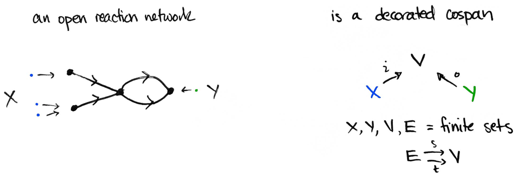

[^54] 例如，有限集范畴中的一个余跨度，就是形如$X\to V\leftarrow Y$的图式，这里我们要把$V$看作Petri网中的库所（即化学物种）组成的集合。

[^54] A **cospan** in the category of **finite sets**, for example, is just a diagram of the form $X\to V\leftarrow Y$, where we’re meant to think of $V$ as the set of places (i.e. chemical species) in the Petri net.

为了体现图中的边，我们要求用额外结构来“装饰”$V$，也就是从边集出发的源映射和目标映射。这样就得到了一个装饰余跨度，

To account for the edges in the graph, we ask that $V$ is “decorated” with extra structure, namely source and target maps from the set of edges. This results in a **decorated cospan,**

而Fong证明了，这些构造形成一个范畴！也就是说，有这样一个范畴：对象是有限集$X,Y,\ldots$，态射$X\to Y$则是以$X$和$Y.$为两足的装饰余跨度。复合由推出[^55]给出，相当于把图粘合在一起。（这个复合只在相差同构的意义下满足结合律，所以态射实际上是余跨度的同构类。此外，恒等态射$X\to X$是空图。）

and Fong proved that these constructions form a category! That is, there is a category where objects are finite sets $X,Y,\ldots$, and a morphism $X\to Y$ is a decorated cospan whose feet are $X$ and $Y.$ Composition is given by the *pushout*[^55], which amounts to gluing graphs together. (This composition is only associative up to isomorphism, so the morphisms are really *isomorphism classes* of cospans. Also, the identity $X\to X$ is the empty graph.)

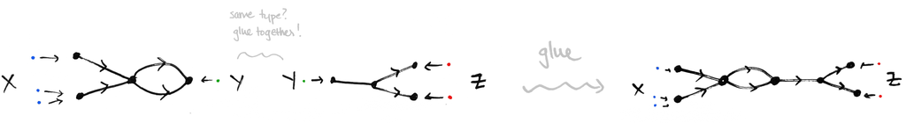

此外，Fong还证明，通过把图上下堆叠起来，也就是取它们的不交并，这个范畴就具有一个对称幺半结构。事实上，它是紧闭的，而且还是一个超图范畴！[^56]

What’s more, Fong showed that this category has a **symmetric monoidal** structure by stacking graphs on top of each other, i.e. by taking their disjoint union. In fact, it’s **compact closed** and also a **hypergraph** category![^56]

总之，Fong的构造很快就能导出一些关键结果，我在这里概括一下。第一个结果是，Baez和Pollard的句法范畴的确是一个范畴：

In summary, Fong’s constructions quickly give rise to key results, which I’ll summarize here. The first is that the syntax category of Baez and Pollard is indeed a category:

定理3.1（Baez、Pollard）。

Theorem 3.1 (Baez, Pollard).

存在一个对称幺半范畴$\textsf{Petri}$，其中

There is a symmetric monoidal category $\textsf{Petri}$ where

- 对象是有限集$X,Y,\ldots$

  **objects** are finite sets $X,Y,\ldots$
- 态射$X\to Y$是一个带速率的开放Petri网，也就是一个余跨度[^57]

[figure not shown]

  ，再加上一个以$V.$为库所集的带速率Petri网。

  a **morphism** $X\to Y$ is a **open Petri net with rates**, i.e. a cospan[^57]

[figure not shown]

  together with a *Petri net with rates* whose *places* are comprised of $V.$

下一个推论给出了语义范畴的对应陈述：

The next corollary provides the same statement for the semantics category:

定理3.2（Baez、Pollard）。

Theorem 3.2 (Baez, Pollard).

存在一个对称幺半范畴$\textsf{Dynam}$，其中

There is a symmetric monoidal category $\textsf{Dynam}$ where

- 对象是有限集$X,Y,\ldots$

  **objects** are finite sets $X,Y,\ldots$
- 态射$X\to Y$是一个开放动力系统，也就是一个余跨度[^58]

[figure not shown]

  ，再加上$\mathbb{R}^V$上的一个光滑向量场。

  a **morphism** $X\to Y$ is an **open dynamical system,** i.e. a cospan[^58]

[figure not shown]

  together with a *smooth vector field* on $\mathbb{R}^V$.

最后，Baez和Pollard的另一个结果表明，从句法到语义存在一个对称幺半函子$\square\colon \textsf{Petri}\to\textsf{Dynam}$。

Finally, another result of Baez and Pollard shows the existence of a symmetric monoidal functor $\square\colon \textsf{Petri}\to\textsf{Dynam}$ from the syntax to the semantics.

定理3.3（Baez、Pollard）。

Theorem 3.3 (Baez, Pollard).

存在一个对称幺半函子$\square\colon \textsf{Petri}\to\textsf{Dynam}$ [^59]，它把任意带速率的开放Petri网映到对应的开放动力系统。

There is a symmetric monoidal functor $\square\colon \textsf{Petri}\to\textsf{Dynam}$ [^59] sending any *open Petri net with rates* to the corresponding *open dynamical system.*

归根结底，函子性与幺半性
$$\begin{aligned}
\square(f\circ g)&=\square f\circ \square g\\
\square(f\otimes g)&=\square f\otimes \square g
\end{aligned}$$
告诉我们：如果你想了解两个开放Petri网的复合（或张量积）所对应的开放动力系统，只需分别求出它们各自对应的开放动力系统，再进行复合（或取张量积）即可。这正是组合性原理：要确定一个庞大复杂事物的行为，只需要理解各个组成部分的行为，再把它们组装起来。顺便说一句，这不仅适用于Petri网，还适用于许多其他类型的网络图。这些都是Baez更大范围研究的一部分：为网络理论建立一个一般性的范畴论框架，涵盖电路、马尔可夫过程、控制论中的信号流图，以及更多内容！

The upshot is that functoriality and monoidality
$$\begin{aligned}
\square(f\circ g)&=\square f\circ \square g\\
\square(f\otimes g)&=\square f\otimes \square g
\end{aligned}$$
tell us that if you want to understand the open dynamical systems of the composite (or tensor product) of two open Petri nets, then you just have to find the open dynamical systems of each one and then compose (tensor). This is *exactly* the **principle of compositionality**: to determine the behavior of a big complicated thing, you need only understand the behaviors of its components, and then assemble them together. And by the way, this works for many other kinds of network graphs, not just Petri nets. It’s all part of Baez’s larger body of work on a general [categorical framework for a theory of networks](http://math.ucr.edu/home/baez/networks/) which encompasses electrical circuits, Markov processes, signal-flow graphs in control theory, and more!

这次对化学反应网络的快速游览，只展示了组合性、函子语义学和幺半范畴应用的一种方式。下一个例子将给出第二种方式：自然语言处理。

This rapid tour through chemical reaction networks is only *one* way that compositionality, functorial semantics, and monoidal categories are being used in applications. The next example gives a second way: natural language processing.

### 自然语言处理Natural Language Processing

终于，我们来到了范畴论的第二个应用——自然语言处理！简单来说，这是人工智能的一个分支，旨在训练计算机理解人类语言。好消息是，计算机能理解词语的含义（例如通过Word2vec这样的模型[^60]），也能理解语法（例如通过词性标注[^61]）。不那么好的消息是，计算机不太擅长理解句子和更长文本的含义。

At long last, we’ve made it to our second application of category theory—natural language processing! It is, simply put, a branch of artificial intelligence that aims to train computers to understand human language. What’s nice is that computers can understand meanings of words (through models like Word2vec, for instance[^60]) and computers can understand grammar (through [parts of speech tagging](https://en.wikipedia.org/wiki/Part-of-speech_tagging), for instance[^61]). But what’s not-so-nice is that computers aren’t too good at understanding meanings of *sentences* and longer bodies of text.

2010年，Bob Coecke、Mehrnoosh Sadrzadeh和Stephen Clark试图在论文“Mathematical Foundations for a Compositional Distributional Model of Meaning”（意义的组合式分布模型的数学基础）中解决这个问题。在这篇论文中，作者们非常倚重组合性原理——一个句子的含义可以由其中各个词语的含义，以及组合这些词语的语法规则来确定。所以，如果计算机能理解单个词语的含义，也能理解语法规则，那么它唯一需要帮助的，就是知道如何把它们组合成一个有意义的整体。而这正是范畴论登场的地方！在函子语义学的指引下，Coecke等人把自然语言建模为紧闭范畴之间的一个（幺半）函子
$$\mathsf{grammar}\to\mathsf{meanings\;of\;words}$$
。这个函子为词语赋予语法类型，而幺半结构则提供了一种把这些词语的含义（及其语法类型）组合起来形成句子的方式，再通过组合性原理确定句子的含义。

In 2010, Bob Coecke, Mehrnoosh Sadrzadeh, and Stephen Clark sought to address this problem in [“Mathematical Foundations for a Compositional Distributional Model of Meaning.”](https://arxiv.org/abs/1003.4394) In this paper, the authors rely heavily on the principle of compositionality—the idea that the meaning of a sentence can be determined by the meanings of its individual words together with the grammatical rules for combining them. So if a computer can understand meanings of individual words and if it can understand grammatical rules, then then only thing it needs help with is knowing how to combine them to form a meaningful whole. And that’s where the category theory comes in! Guided by functorial semantics, Coecke et. al. model natural language as a (monoidal) functor between *compact closed categories*
$$\mathsf{grammar}\to\mathsf{meanings\;of\;words}$$
This functor assigns a grammar type to a word, and the monoidal structures provide a way to combine the meanings of those words (and their grammar types) to form a sentence, whose meaning can be determined via the principal of compositionality.

在余下的篇幅中，我们将通过回答以下问题，深入了解其中的细节：

in the remaining pages, we’ll dive into the details by answering the following questions:

1. （句法范畴）如何从数学上理解语法？具体来说，$\mathsf{grammar}$如何构成一个紧闭范畴？

   **(the syntax category)** How can we make sense of grammar, mathematically? Specifically, how does $\mathsf{grammar}$ form a compact closed category?
2. （语义范畴）如何从数学上理解词语的含义？也就是说，$\mathsf{meanings\;of\;words}$如何构成一个紧闭范畴？

   **(the semantics category)** How can we make sense of meanings of words, mathematically? That is, how do $\mathsf{meanings\;of\;words}$ form a compact closed category?
3. （函子）函子
   $$\mathsf{grammar}\to\mathsf{meanings\;of\;words}$$
   如何定义？它又如何让我们确定整个句子的含义？

   **(the functor)** How is the functor
   $$\mathsf{grammar}\to\mathsf{meanings\;of\;words}$$
   defined and how does it allow one to determine the meaning of a full sentence?

我们先来回答第一个问题。

Let’s start by answering the first question.

### 句法范畴：前群The Syntax Category: Pregroup

沿着Coecke等人的工作，我们可以通过前群，用代数方式为语法建模。前群是数学家Joachim Lambek于20世纪90年代初提出的一种构造。[^62] 非正式地说，照着下面的配方就能调制出一个前群：

Following the work of Coecke et. al., we can model grammar algebraically via a *pregroup*, a construction due to [^62] mathematician Joachim Lambek in the early 1990s. Informally, a pregroup is cooked up from the following recipe:

偏序集 + 幺半群 + “对偶” = 前群

**poset** + **monoid** + **“duals”** = **pregroup**

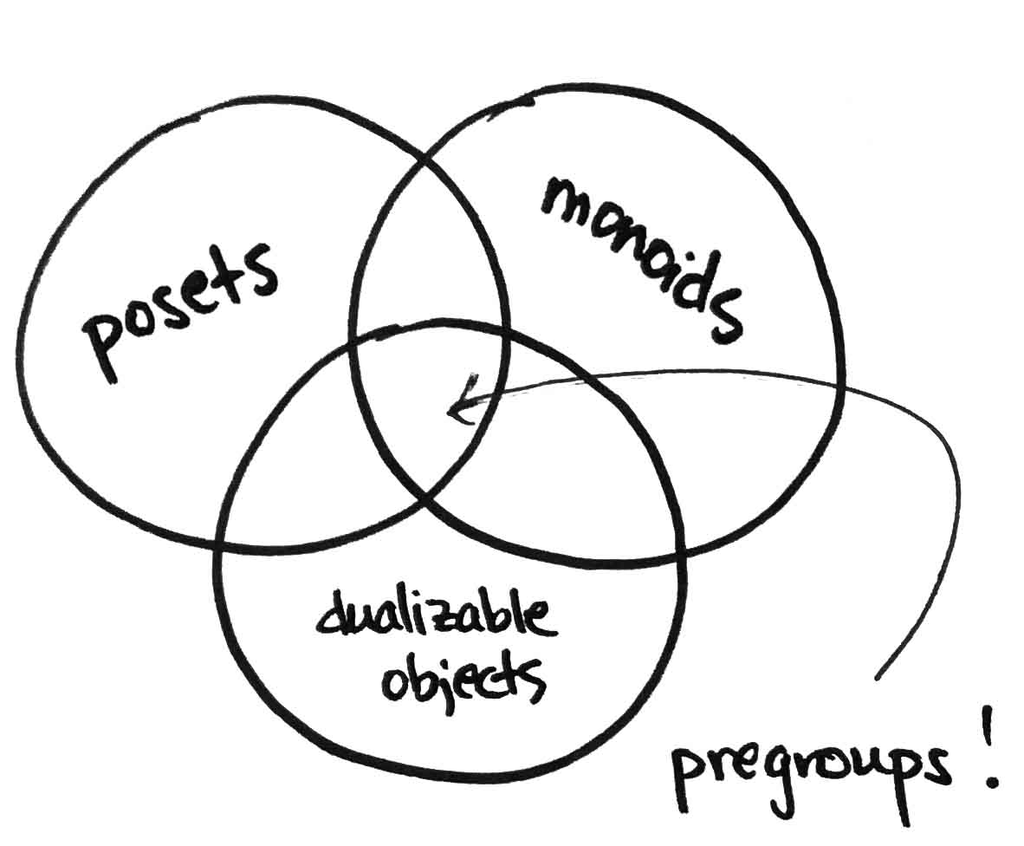

换句话说，前群是

In other words, a pregroup is

- 一个偏序集$(P,\leq)$

  a poset $(P,\leq)$
- 带有一个与偏序相容的乘法（我们用并置来表示），也就是说，如果$p\leq q$，那么对所有$a\in P$，都有$ap\leq aq$和$pa\leq qa$，

  that has a multiplication (we’ll denote it by juxtaposition) that’s compatible with the partial order, i.e. if $p\leq q$ then $ap\leq aq$ and $pa\leq qa$ for all $a\in P$,
- 还带有一个单位1，对所有$p\in P$都满足$1p=p1=p$，

  together with a unit 1 satisfying $1p=p1=p$ for all $p\in P$,
- 而且，每个元素$p$都有左对偶$p^l$和右对偶$p^r$，并有映射
  $$p^lp\overset{\epsilon^l}{\leq} 1 \overset{\eta^l}{\leq} pp^l
  \qquad\text{and}\qquad
  pp^r \overset{\epsilon^r}{\leq} 1 \overset{\eta^r}{\leq} p^rp.$$
  ，它们须满足式(2)中的拉直方程。

  and moreover each element $p$ has both a left dual $p^l$ and a right dual $p^r$ with maps
  $$p^lp\overset{\epsilon^l}{\leq} 1 \overset{\eta^l}{\leq} pp^l
  \qquad\text{and}\qquad
  pp^r \overset{\epsilon^r}{\leq} 1 \overset{\eta^r}{\leq} p^rp.$$
  that are required to satisfy the yanking equations in (2).

我把这些不等式称为映射（也用映射的方式给它们作了标记），因为它们实际上是某个范畴中的态射！事实上，每个偏序集$(P,\leq)$都可以看作一个范畴：对象是$P$中的元素，存在箭头$p\to q$当且仅当$p\leq q.$（特别地，偏序集中任意两个元素之间至多只有一个箭头。）复合由传递性给出：如果$p\leq q$且$q\leq r$，那么$p\leq r$；结合律则显然成立。此外，每个元素都有恒等箭头，因为偏序具有自反性：对所有$p\in P$，都有$p\leq p$。所以，既然前群是偏序集，我们也可以把它视为范畴。因此，从现在起，我会画一个箭头$\to$来代替偏序符号$\leq$。而且，前群实际上是带有额外结构的偏序集，所以我们可以把它视为带有额外结构的范畴。看到拉直方程再次出现，你大概不会惊讶：这个额外结构正是紧闭结构！总而言之，前群是紧闭范畴的一个例子。特别地，它是一个不对称的紧闭范畴。事实上，上面的四个不等式实际上就是第2.1节讨论过的单位与余单位映射
$$p^lp\overset{\epsilon^l}{\longrightarrow} 1 \overset{\eta^l}{\longrightarrow} pp^l
\qquad\text{and}\qquad
pp^r \overset{\epsilon^r}{\longrightarrow} 1 \overset{\eta^r}{\longrightarrow} p^rp.$$
，而拉直方程(2)在这里就是：
$$\begin{aligned}
p&=p\cdot1\overset{1\cdot \eta^r}{\longrightarrow} pp^rp \overset{\epsilon^r\cdot 1}{\longrightarrow} 1\cdot p = p\\[10pt]
p &= 1\cdot p \overset{\eta^l\cdot 1}{\longrightarrow} pp^lp \overset{1\cdot \eta^l}{\longrightarrow} p \cdot 1=p\\[10pt]
p &= 1\cdot p^r \overset{\eta^r\cdot 1}{\longrightarrow} p^rpp^r\overset{1\cdot \epsilon^r}{\longrightarrow} p^r\cdot 1=p^r\\[10pt]
p &= p^l\cdot 1 \overset{1 \cdot \eta^l}{\longrightarrow} p^lpp^l \overset{\epsilon^l\cdot 1}{\longrightarrow} 1\cdot p^l=p^l
\end{aligned}$$
[^63]

I’ve referred to the inequalities as *maps* (and have labeled them as such) because they are actually *morphisms* in a category! Indeed, every poset $(P,\leq)$ can be viewed as a category: an object is an element in $P$ and there is an arrow $p\to q$ if and only if $p\leq q.$ (In particular, there is *at most* one arrow between any two elements in a poset.) Composition is given by transitivity: if $p\leq q$ and $q\leq r$ then $p\leq r$, and associativity is immediate. Also, every element has an identity arrow since the partial order is reflexive: $p\leq p$ for all $p\in P$. So because a pregroup is a poset, we may also view it as a category. Therefore I’ll now draw an arrow $\to$ in lieu of the partial order $\leq$. Moreover, a pregroup is really a poset-with-extra-structure and therefore we may view it as a category-with-extra-structure. Not surprisingly, given the reappearance of the yanking equations, that extra structure is compact closure! In summary, a pregroup is an example of a **compact closed category**. It is, in particular, a compact closed category that is *not symmetric.* Indeed, those four inequalities above are really the unit and counit maps
$$p^lp\overset{\epsilon^l}{\longrightarrow} 1 \overset{\eta^l}{\longrightarrow} pp^l
\qquad\text{and}\qquad
pp^r \overset{\epsilon^r}{\longrightarrow} 1 \overset{\eta^r}{\longrightarrow} p^rp.$$
discussed in Section 2.1, and the yanking equations (2) amount to the following:
$$\begin{aligned}
p&=p\cdot1\overset{1\cdot \eta^r}{\longrightarrow} pp^rp \overset{\epsilon^r\cdot 1}{\longrightarrow} 1\cdot p = p\\[10pt]
p &= 1\cdot p \overset{\eta^l\cdot 1}{\longrightarrow} pp^lp \overset{1\cdot \eta^l}{\longrightarrow} p \cdot 1=p\\[10pt]
p &= 1\cdot p^r \overset{\eta^r\cdot 1}{\longrightarrow} p^rpp^r\overset{1\cdot \epsilon^r}{\longrightarrow} p^r\cdot 1=p^r\\[10pt]
p &= p^l\cdot 1 \overset{1 \cdot \eta^l}{\longrightarrow} p^lpp^l \overset{\epsilon^l\cdot 1}{\longrightarrow} 1\cdot p^l=p^l
\end{aligned}$$
[^63]

我们来看前群的两个例子。第一个是算术中的例子，帮助我们先熟悉一下。第二个是语法中的例子，用于Coecke、Sadrzadeh和Clark的DisCoCat模型。

Let’s look at two examples of pregroups. The first is an arithmetic example, which will help to get our feet wet. The second is a grammatical example, which is used in the DisCoCat model of Coecke, Sadrzadeh, and Clark.

例3.4。

Example 3.4.

集合
$$\{f\colon \mathbb{Z}\to\mathbb{Z}\;\vert\; f\text{ is monotone and unbounded}\}$$
是一个前群。偏序逐点定义：$f\leq g$当且仅当对所有$n.$，都有$fn\leq gn$。幺半群的乘法由函数复合给出：$f\cdot g:=f\circ g.$ 幺半单位对象是$\text{id}_\mathbb{Z}.$ 给定这样的函数$f,$，其左、右对偶由下式给出：
$$f^ln:=\min\{m\in\mathbb{Z}\;\vert\; n\leq fm\} \qquad\qquad f^rn=\max\{m\in\mathbb{Z}\;\vert\;fm\leq n\}.$$
例如，如果$fm=2m,$，那么[^64]
$$f^ln=\begin{cases}
\frac{n}{2} &\text{if $n$ is even},\\
\frac{n+1}{2} &\text{if $n$ is odd}
\end{cases}
\qquad \qquad
f^r=
\begin{cases}
\frac{n}{2} &\text{if $n$ is even,}\\
\frac{n-1}{2} &\text{if $n$ is odd.}
\end{cases}$$
简言之，$f^ln=\lfloor \frac{n+1}{2} \rfloor$，且$f^rn=\lfloor \frac{n}{2}\rfloor$。

The set
$$\{f\colon \mathbb{Z}\to\mathbb{Z}\;\vert\; f\text{ is monotone and unbounded}\}$$
is a pregroup. The partial order is given pointwise: $f\leq g$ if and only if $fn\leq gn$ for all $n.$ The monoid multiplication is given by function composition $f\cdot g:=f\circ g.$ The monoidal unit is $\text{id}_\mathbb{Z}.$ Given such a function $f,$ its left and right duals are given by
$$f^ln:=\min\{m\in\mathbb{Z}\;\vert\; n\leq fm\} \qquad\qquad f^rn=\max\{m\in\mathbb{Z}\;\vert\;fm\leq n\}.$$
For example, if $fm=2m,$ then [^64]
$$f^ln=\begin{cases}
\frac{n}{2} &\text{if $n$ is even},\\
\frac{n+1}{2} &\text{if $n$ is odd}
\end{cases}
\qquad \qquad
f^r=
\begin{cases}
\frac{n}{2} &\text{if $n$ is even,}\\
\frac{n-1}{2} &\text{if $n$ is odd.}
\end{cases}$$
In short, $f^ln=\lfloor \frac{n+1}{2} \rfloor$ and $f^rn=\lfloor \frac{n}{2}\rfloor$.

你可以在Lambek的文章“Iterated Galois Connections in Arithmetic and Linguistics”（算术与语言学中的迭代伽罗瓦连接）中找到这个例子，该文收录于施普林格出版的《伽罗瓦连接及其应用》（Galois Connections and Applications）一书中。Coecke等人的“数学基础”论文也提到了它。

You can find this example in “Iterated Galois Connections in Arithmetic and Linguistics” by Lambek, which appears in the Springer book [*Galois Connections and Applications*](https://www.springer.com/us/book/9781402018978). You’ll also find mention of it in the [“Mathematical Foundations”](https://arxiv.org/abs/1003.4394) paper of Coecke et. al.

算术虽然很有趣，但接下来的这个例子才是我们最感兴趣的。

While arithmetic is fun, this next example is the one we’re most interested in.

例3.5。

Example 3.5.

给定任意有限偏序集$X$，我们可以构造由$X,$生成的自由前群，记作$\textsf{Preg}X$。举个简单的例子，假设$X=\{n,s\}$，我们把其中的元素视为基本语法类型：$n$是名词的类型，$s$是（陈述）句的类型。$\textsf{Preg}\{n,s\}$中的元素，就是将字母$n$和$s$及其左、右对偶，以及这些对偶的迭代等等串接而成的串。例如，$\textsf{Preg}\{n,s\}$中的一些语法类型如下：

Given any finite poset $X$, we can construct the *free pregroup generated by $X,$* denoted $\textsf{Preg}X$. For a simple example, suppose $X=\{n,s\}$ whose elements we’ll think of as basic grammar types: $n$ is the type of a *noun* and $s$ is the type of a (declarative) *sentence*. Elements of $\textsf{Preg}\{n,s\}$ are concatenations of the letters $n$ and $s$ and their left and right duals and iterations of those duals and so on. For example, some grammatical types in $\textsf{Preg}\{n,s\}$ are:

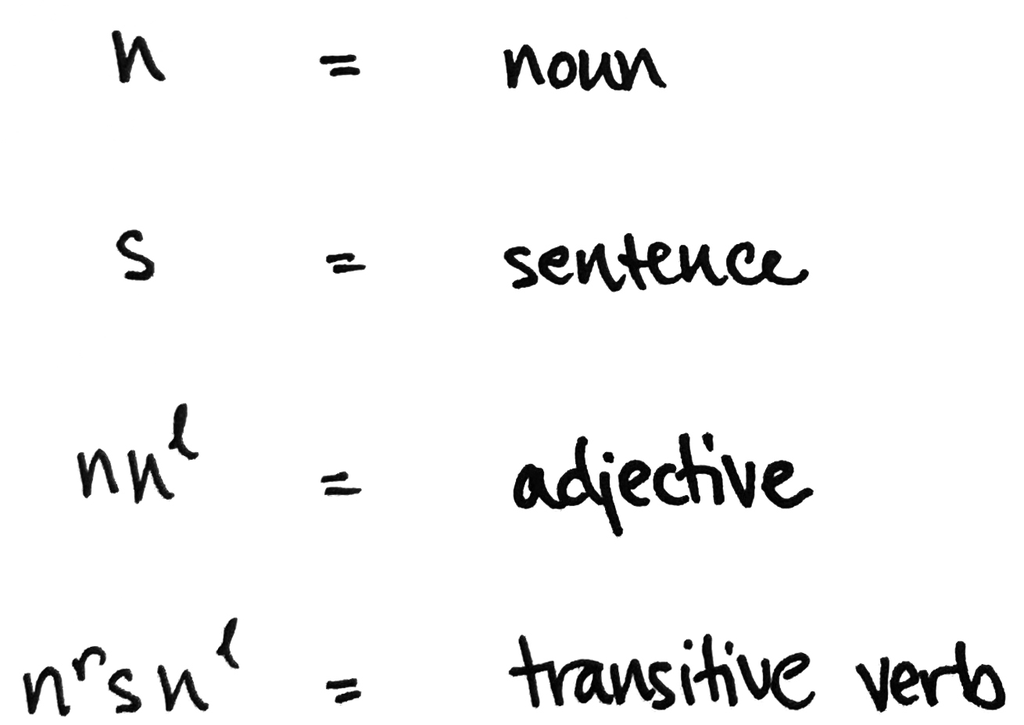

这些字母串称为复合类型。复合类型之间存在态射$a\to b$，当且仅当$a$可以通过应用一个或多个余单位映射$\epsilon^r$和$\epsilon ^l$，约化为$b$。

The strings of letters are called *compound types*, and there is a morphism $a\to b$ between compound types if and only if $a$ can *reduce* to $b$ by application of one or more of the counit maps $\epsilon^r$ and $\epsilon ^l$.

例如，考虑banana（香蕉）这个词。它的类型当然是$n$，而形容词yellow（黄色的）的类型则是$nn^l$。形容词的语法类型之所以是$nn^l$，是因为形容词总能放在一个名词的左边，与之配对，得到一个新的名词——例如yellow banana（黄色的香蕉）。

Consider a banana, for example. It has type $n$, of course, while the adjective yellow has type $nn^l$. The reason that adjectives have grammar type $nn^l$ is that an adjective can always be paired on the left with a noun, resulting in a new noun—e.g. *yellow banana.*

$\underset{nn^l}{\text{yellow}} \quad \underset{n^{\phantom{l}}}{\text{banana}}$

事实上，要验证yellow banana的语法类型是$n$，我们先把各个词的类型串接起来，得到$nn^ln$。接着，应用余单位映射$\epsilon^l\colon n^ln\to~1$和恒等映射$1_n\colon n\to n$（后者来自偏序集的自反性公理：$n\leq n$），就会看到$nn^ln$约化为$n$：[^65]

Indeed, to verify that the grammar type of *yellow banana* is $n$, we start by concatenating the types of the individual words to obtain $nn^ln$. Then we apply the counit map $\epsilon^l\colon n^ln\to~1$ together with the identity map $1_n\colon n\to n$ (this is given to us by the reflexivity axiom of posets: $n\leq n$) to see that $nn^ln$ reduces down to $n$: [^65]

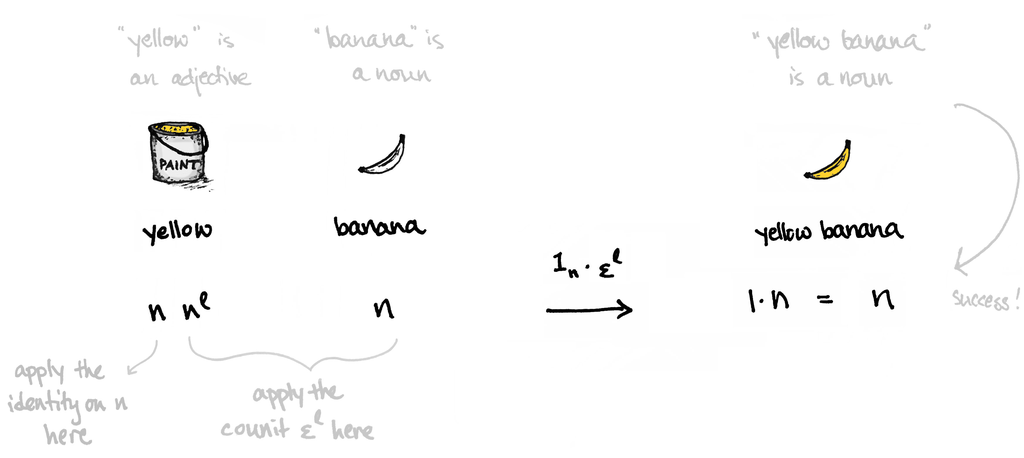

这告诉我们，短语yellow banana的语法类型是$n$。不错。黄色的香蕉是个名词！

This tells us that the phrase yellow banana has grammar type $n$. That’s good. A yellow banana is a noun!

聊过黄色的香蕉以后，你也许愿意花几秒钟想一想：为什么$n^rsn^l$表示及物动词的语法类型？

In light of this discussion on yellow bananas, you might enjoy taking a few seconds to think about why $n^rsn^l$ represents the grammar type of *transitive verb*.

〈思考〉……〈/思考〉

`<ponder> ... </ponder>`

及物动词是这样一种词：它可以在右侧接一个名词，在左侧再接一个名词，使得到的短语成为一个完整的句子。既然我们喜欢香蕉，那就再举一个水果的例子：

A transitive verb is a word that accepts a noun on the right and another noun on the left such that the resulting phrase is a full sentence. Since we like bananas, here’s another fruit-based example:

$\underset{n^{\phantom{l}}}{\text{bananas}} \quad \underset{n^rsn^l}{\text{are}} \quad \underset{n^{\phantom{l}}}{\text{fruit}}$

为了确定这个短语的语法类型，我们照之前那样，把各个词的语法类型串接起来，再应用余单位映射进行约化：

To determine the grammar type of this phrase, we concatenate the grammatical types of the individual words and then apply the counit maps to reduce, as before:

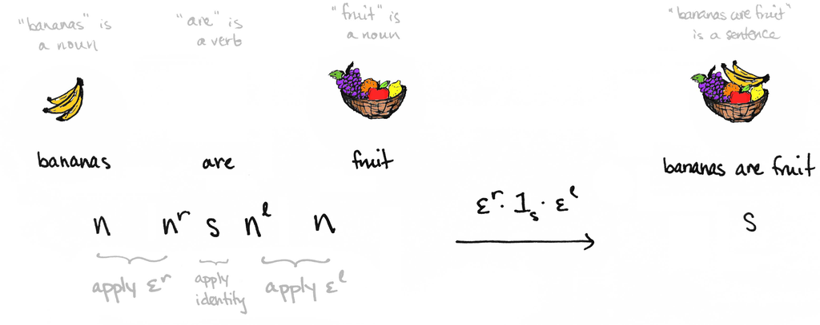

把同样的约化过程一步一步写出来，就是下面这样。为了清楚起见，我会用点号表示串接：
$$n n^rsn^ln= nn^r\cdot s\cdot n^ln \overset{\epsilon^r\cdot 1_s\cdot 1_n}{\longrightarrow} 1\cdot s\cdot n^ln = s\cdot n^ln
\overset{1_s\cdot \epsilon^l}{\longrightarrow} s\cdot 1
=s$$
用文字来说，我们利用余单位映射，把bananas are fruit（香蕉是水果）各词的语法类型串接成的串约化为字母$s$，这就证实了“bananas are fruit”的确是一个合乎语法的句子。更一般地，对任意$a,b\in \textsf{Preg}\{n,s\}$，我们画出态射$a\to b$当且仅当$a$能以类似方式约化为$b$。

Here’s that same reduction written out step-by-step. For clarity, I’ll indicate the concatenation with a dot:
$$n n^rsn^ln= nn^r\cdot s\cdot n^ln \overset{\epsilon^r\cdot 1_s\cdot 1_n}{\longrightarrow} 1\cdot s\cdot n^ln = s\cdot n^ln
\overset{1_s\cdot \epsilon^l}{\longrightarrow} s\cdot 1
=s$$
In words, we’ve used the counit maps to reduce the concatenation of the grammar types for *bananas are fruit* to the letter $s$, which confirms that “bananas are fruit” is indeed a grammatically correct sentence. More generally, for any $a,b\in \textsf{Preg}\{n,s\}$, we draw a morphism $a\to b$ if and only if $a$ can be reduced to $b$ in a similar fashion.

好，这就是前群的故事（的极度浓缩版）！总结一下，Coecke等人的语言模型归结为一个保持结构的函子
$$\textsf{syntax}\to\textsf{semantics}$$
。在本节中，我们刚刚说明，句法范畴取为由一个有限的基本语法类型集自由生成的前群，即$\textsf{syntax} = \textsf{Preg}X.$。现在我们转向语义。

Alright, that’s (a very condensed version of) the pregroup story! To summarize, the language model of Coecke et. al. amounts to a structure-preserving functor
$$\textsf{syntax}\to\textsf{semantics}$$
In this section, we’ve just shown that the syntax category is taken to be a pregroup freely generated on a finite set of basic grammar types, i.e. $\textsf{syntax} = \textsf{Preg}X.$ Let’s move on to semantics now.

### 语义范畴：向量空间The Semantics Category: Vector Spaces

正如第3.2节开头所说，计算机能相当好地理解单个词语的含义。这是因为计算机懂数字！例如，要把banana这个词的含义告诉计算机，一个很好的办法就是用一个数表示banana，再把这个数交给计算机。

As stated in the introduction to Section 3.2, computers are able to understand meanings of individual words pretty well. That’s because computers understand numbers! For example, a great way to inform a computer of the meaning of the word *banana* is to represent *banana* by a number and then give that number to the computer.

什么数？

*What number?*

嗯，准确地说，它不是一个数。而是一列数——一个向量。

Well, it’s not exactly a number. It’s an array of numbers—a vector.

好吧，那是什么向量？

*Okay, what vector?*

答案很简单，不过我想先分享下面这个定理，说明一下背后的想法。

The answer is simple, though I’d like to motivate it by sharing the following theorem.

定理（语言学的米田引理）。观其所伴，即知其词。

**Theorem** (The Yoneda Lemma for Linguistics). *You shall know a word by the company it keeps.*

证明。John Firth[^66] ◻

*Proof.* John Firth[^66] ◻

好吧，它并不是一个定理。但这的确是一句很棒的话！Firth的意思是，出现在相似语境中的词语，其含义也会相似。[^67] 在语言学界，这被称为分布假说。因此，你可以想象，比起puppy（小狗），apple（苹果）更接近banana（香蕉），因为苹果和香蕉常出现在sweet（甜的）、snack（零食）、green（绿色的）、eat（吃）等词语附近，而puppy更常出现在pet（宠物）、cute（可爱的）、furry（毛茸茸的）、bark（吠叫）等词语附近。再举个例子，你可能不知道yegg这个词是什么意思（也许你知道），但大概能从下面这句话里推断出来：

Okay, so it’s not a theorem. But it is a great quote! Firth’s idea is that *words that appear in similar contexts will have similar meaning.* [^67] In the linguistics community, this is referred to as the [distributional hypothesis](https://en.wikipedia.org/wiki/Distributional_semantics#Distributional_hypothesis). So you might imagine that *apple* is more similar to *banana* than it is to *puppy* since *apples* and *bananas* often occur near words such as sweet, snack, green, eat, etc., whereas occurs more often near words such as pet, cute, furry, bark, and so on. As another example, you might not know what the word *yegg* means (or perhaps you do), but you can probably infer it from [this sentence](https://www.merriam-webster.com/word-of-the-day/yegg-2018-03-20):

警察因费城一家商店的入室盗窃案，抓住了他和另一个yegg。[^68]

The cops grabbed him and another yegg for a Philadelphia store burglary.[^68]

所以，我们可以用一个向量来表示一个词的含义。这通常称为意义的分布模型。不过，“词语$\mapsto$向量”这个对应究竟是什么？假设我们有一个固定的语料库——比如你最喜欢的一本书。首先选择一组所谓的上下文词$\{w_1,\ldots, w_n\}$。它可以包含语料库中的每一个词，也可以只是其中的一个子集。把每个$w_i$表示为第$i$个标准基向量
$$\mathbf{w}_i=(0,\ldots,\overbrace{1}^{i^\text{th} \text{spot}},\ldots,0)$$
，我们就得到了向量空间$V$的一组基$\{\mathbf{w_1},\ldots, \mathbf{w_n}\}$。那么，语料库中任意一个词$w$都可以表示为这些上下文词的线性组合所给出的向量：
$$\mathbf{w}=\sum_{i=1}^n c_i\mathbf{w_i}$$
系数$c_i$是实数，表示语料库中$w$出现在$w_i$附近[^69]的次数。

So we can represent the meaning of a word by a vector. This is often called a *distributional model of meaning.* But what, exactly, *is* the assignment *word* $\mapsto$ *vector*? Suppose we have a fixed corpus—your favorite book, say. Start by choosing a set of so-called **context words** $\{w_1,\ldots, w_n\}$. This can be every word in the corpus or some subset of it. By representing each $w_i$ as the $i$th standard basis vector
$$\mathbf{w}_i=(0,\ldots,\overbrace{1}^{i^\text{th} \text{spot}},\ldots,0)$$
we obtain a basis $\{\mathbf{w_1},\ldots, \mathbf{w_n}\}$ for a vector space $V$. Then any word $w$ in the corpus has a vector representation given by a linear combination of the context words
$$\mathbf{w}=\sum_{i=1}^n c_i\mathbf{w_i}$$
The coefficients $c_i$ are real numbers that indicate the number of times that $w$ occurs near[^69] $w_i$ in the corpus.

举个例子。假设我们正在读一本书，里面包含词语
$$\{ \textit{sweet},\textit{green}, \textit{furry} \}$$
。我们把它们选作上下文词，并作如下对应：
$$\mathbf{sweet} = \begin{bmatrix}1\\0\\0\end{bmatrix} \qquad
\mathbf{green} = \begin{bmatrix}0\\1\\0\end{bmatrix}\qquad
\mathbf{furry}=\begin{bmatrix}0\\0\\1\end{bmatrix}$$
那么，如果banana、puppy和fruit（水果）也是书中的词语，我们也许会得到类似下面的结果：
$$\mathbf{banana} = \begin{bmatrix}21\\9\\0\end{bmatrix}\qquad
\mathbf{puppy} = \begin{bmatrix}8\\1\\32\end{bmatrix} \qquad
\mathbf{fruit} = \begin{bmatrix}43\\19\\0\end{bmatrix}$$
[^70] 换句话说，我们利用语料库中的数据，把这些词语作为向量嵌入一个三维向量空间中。于是我们就说，banana这个词的含义是向量$(21,9,0)$，puppy的含义是$(8,1,32)$，而fruit的含义是$(43,19,0)$。

Here’s an example. Suppose we’re reading a book that contains the words
$$\{ \textit{sweet},\textit{green}, \textit{furry} \}$$
Let’s choose them to be our context words and make the assignment so that
$$\mathbf{sweet} = \begin{bmatrix}1\\0\\0\end{bmatrix} \qquad
\mathbf{green} = \begin{bmatrix}0\\1\\0\end{bmatrix}\qquad
\mathbf{furry}=\begin{bmatrix}0\\0\\1\end{bmatrix}$$
Then if *banana, puppy* and *fruit* are also words in our book, we might have something like
$$\mathbf{banana} = \begin{bmatrix}21\\9\\0\end{bmatrix}\qquad
\mathbf{puppy} = \begin{bmatrix}8\\1\\32\end{bmatrix} \qquad
\mathbf{fruit} = \begin{bmatrix}43\\19\\0\end{bmatrix}$$
[^70] In other words, we’ve used data from the corpus to *embed* these words as vectors inside of a three-dimensional vector space. This prompts us to say that the *meaning* of the word banana *is* the vector $(21,9,0)$, the meaning of puppy is $(8,1,32)$, and the meaning of fruit is $(43,19,0)$.

而且，这办法确实管用！也就是说，你可以把分布模型输入计算机，它们就能在你的SAT考试的词语相似度部分拿到高分。或者，你可以计算词语之间的点积，就会发现，恰恰在词语含义相同时，表示它们的向量更接近。对自然语言处理的从业者来说，这些都是熟悉的内容。因此，Coecke等人所用的语义范畴，就是$\mathbb{R}$上的有限维向量空间范畴。也就是说，
$$\textsf{meanings of words} = \textsf{FVect}$$

And this works! That is, you can feed distributional models into your computer, and they’ll ace the word-similarity portion of your SAT exam. Or your can compute the dot product between words, and you’ll find that vectors are closer together precisely when the words they represent have the same meaning. It’s all familiar territory for NLP practitioners. The semantics category for Coecke et. al. is thus the category of finite dimensional vector spaces over $\mathbb{R}$. That is,
$$\textsf{meanings of words} = \textsf{FVect}$$

遗憾的是，分布模型对句子并不适用。同一个句子在给定文档中很少会出现两次，所以我们无法照搬上面的做法。这时，范畴论就可以来搭把手了。根据组合性原理，给定句子中各个词的含义，以及组合它们的语法规则，应该就能计算出整个句子的含义。而通过一个从句法（$\textsf{grammar}$）到语义（$\textsf{meanings of words}$）的映射，也就是一个函子
$$F\colon \textsf{Preg}X\to\textsf{FVect}$$
，我们可以把词语含义与语法类型配对，其中$X$是基本语法类型组成的有限集。事实上，由第2.1节我们知道，$\textsf{FVect}$和$\textsf{Preg}X$都是紧闭范畴，因此我们要求$F$是一个强幺半函子——也就是保持紧闭结构的函子。这就是Coecke等人的范畴化组合式分布模型背后的基本思路。

Unfortunately, the distributional model does *not* work for sentences. The same sentence rarely occurs twice in a given document, therefore we can’t follow the same procedure above. This is where category theory can help lend a hand. In light of the principle of compositionality, the meaning of a sentence should be able to be computed given the meanings of its individual words and the rules of grammar for combining them. And we can pair meanings-of-words with grammatical types via a map from syntax ($\textsf{grammar}$) to semantics ($\textsf{meanings of words}$), i.e. via a functor
$$F\colon \textsf{Preg}X\to\textsf{FVect}$$
where $X$ is a finite set of basic grammar types. In fact, as we know from Section 2.1, both $\textsf{FVect}$ and $\textsf{Preg}X$ are compact closed categories, so we’ll ask that $F$ be a *strong monoidal functor*—one that preserves the compact closed structure. That’s the gist behind the categorical compositional distributional model of Coecke et. al.

但$F$究竟是如何定义的？接下来我们就谈这个。

But how is $F$ actually *defined*? Let’s talk about that next.

### 函子：句法$\to$语义The Functor: Syntax $\to$ Semantics

在本节中，我们将明确描述函子
$$F\colon \textsf{syntax}\to\textsf{semantics}$$
，更具体地说，是
$$F\colon \textsf{Preg}X\to\textsf{FVect}$$
。为简单起见，我们像之前一样，取$X=\{n,s\}$。要定义一个函子，只需说明它对对象和态射分别做什么。那我们就这样做。在对象上，

In this section, we’ll give an explicit description of the functor
$$F\colon \textsf{syntax}\to\textsf{semantics}$$
or more specifically,
$$F\colon \textsf{Preg}X\to\textsf{FVect}$$
For simplicity, let’s take $X=\{n,s\}$ as we did before. Now to define a functor, we need simply to say what it does on objects and morphisms. So let’s do that. On objects,

- $F$为名词类型$n$指派一个向量空间$N:=Fn$，我们称之为名词空间

  $F$ assigns to the noun type $n$ a vector space $N:=Fn$, which we’ll call a *noun space*
- $F$为句子类型$s$指派一个向量空间$S:=Fs$，我们称之为句子空间

  $F$ assigns to the sentence type $s$ a vector space $S:=Fs$, which we’ll call a *sentence space*

而在态射上，

and on morphisms

- $F$为类型约化$a\overset{r}{\longrightarrow} b$指派一个线性映射$Fa\overset{Fr}{\longrightarrow}Fb$，它把$Fa$中对应于$a$类型的词或短语的向量，映到$Fb$中对应于$b$类型的词或短语的向量。

  $F$ assigns to a type reduction $a\overset{r}{\longrightarrow} b$ a linear map $Fa\overset{Fr}{\longrightarrow}Fb$ that sends the vector corresponding to a word or phrase of type $a$ in $Fa$ to the vector corresponding to a word or phrase of type $b$ in $Fb$.

此外，要求$F$保持紧闭结构，意味着

Moreover, asking that $F$ preserve the compact closed structure means that

- $\textsf{Preg}\{n,s\}$中的单位和余单位映到$\textsf{FVect}$中的单位和余单位

  units and counits in $\textsf{Preg}\{n,s\}$ map to units and counits in $\textsf{FVect}$

  > 例如，给定$n\in \textsf{Preg}\{n,s\}$，
  > $$F(1\overset{\eta_n^r}{\longrightarrow} n^rn)=F(1\overset{\eta_n^l}{\longrightarrow} nn^l)=\eta_N
  > \qquad\text{and}\qquad
  > F(nn^r\overset{\epsilon_n^r}{\longrightarrow}1)=F(n^ln\overset{\epsilon_n^l}{\longrightarrow}1)=\epsilon_N$$
  > ，其中$\eta_N\colon \mathbb{R}\to N\otimes N$和$\epsilon_N\colon N\otimes N\to \mathbb{R}$就是我们在第17页定义的线性映射。把$n$换成$\textsf{Preg}\{n,s\}$中的任意元素，也有类似的结论。

  > e.g. given $n\in \textsf{Preg}\{n,s\}$,
  > $$F(1\overset{\eta_n^r}{\longrightarrow} n^rn)=F(1\overset{\eta_n^l}{\longrightarrow} nn^l)=\eta_N
  > \qquad\text{and}\qquad
  > F(nn^r\overset{\epsilon_n^r}{\longrightarrow}1)=F(n^ln\overset{\epsilon_n^l}{\longrightarrow}1)=\epsilon_N$$
  > where $\eta_N\colon \mathbb{R}\to N\otimes N$ and $\epsilon_N\colon N\otimes N\to \mathbb{R}$ are the linear maps that we defined on p. 17. A similar idea holds if we replace $n$ by any element of $\textsf{Preg}\{n,s\}$.
- 对偶映到对偶

  duals map to duals

  > 例如，$Fn^r=Fn^l=N^*$。不过，我们的向量空间是有限维的，所以$N^*\cong N$，从而$Fn^r=Fn^l=N$。

  > e.g. $Fn^r=Fn^l=N^*$. But our vector spaces are finite dimensional and so $N^*\cong N$ and therefore $Fn^r=Fn^l=N$.
- 复合类型被指派到向量空间的张量积。

  a compound type is assigned to a tensor product of vector spaces.

  > e.g.
  > $$F(n^rsn^l)\cong Fn^r\otimes Fs\otimes Fn^l=N\otimes S\otimes N$$

就这些！

*And that’s it!*

只不过……这样说也许还不够直观。看一个小例子肯定会有帮助。所以，接下来几页，我们就用DisCoCat模型来计算下面这个句子的含义

Except... this might not be very enlightening yet. It’ll surely be helpful to look at a toy example. So in the next couple of pages, let’s use the DisCoCat model to compute the meaning of the sentence

bananas are fruit（香蕉是水果）

*bananas are fruit*

我所说的“计算意义”是指：我们希望能把句子 bananas are fruit（香蕉是水果）看成一个向量，再把这个向量送入函子 $F$，得到一个编码了句子意义的输出向量。
$$F(bananas\;are\;fruit)=\;??$$
这个输出向量就是句子的“意义”。我们的目标就是找出这个意义。

By “compute the meaning,” I mean the following: we want to be able to view the sentence *bananas are fruit* as a vector, then feed that vector into the functor $F$ and get an output vector that encodes for the meaning of the sentence.
$$F(bananas\;are\;fruit)=\;??$$
That output vector will be the “meaning” of the sentence. Our goal is to find that meaning.

让我们有条不紊地来做。[^71] 我会从头开始，把计算过程一步步列出来。

Let’s proceed systematically. [^71] I’ll list the computations step-by-step, starting from the beginning.

第 1 步：为每个词指定一个 $\textsf{Preg}\{n,s\}$ 中的语法类型。这很容易：bananas（香蕉）$\rightsquigarrow$ $n$；are（是）$\rightsquigarrow$ $n^rsn^l$；fruit（水果）$\rightsquigarrow$ $n$。

**Step 1: Assign each word a grammar type in $\textsf{Preg}\{n,s\}$.**  
That’s easy enough:  
bananas $\rightsquigarrow$ $n$  
are $\rightsquigarrow$ $n^rsn^l$  
fruit $\rightsquigarrow$ $n$

第 2 步：固定一个名词空间 $Fn=N$ 和一个句子空间 $Fs=S$。假设 $N$ 是由基向量
$$\mathbf{sweet}, \mathbf{green}, \mathbf{furry}$$
张成的三维空间，我们可以像之前一样，把这些基向量表示成列向量：
$$\begin{aligned}
\mathbf{w_1}=\mathbf{sweet} = \begin{bmatrix}1\\0\\0\end{bmatrix},\qquad
\mathbf{w_2}=\mathbf{green} = \begin{bmatrix}0\\1\\0\end{bmatrix},\qquad
\mathbf{w_3}=\mathbf{furry} = \begin{bmatrix}0\\0\\1\end{bmatrix}
\end{aligned}$$
。这些基向量生成了名词空间。那句子空间 $S$ 呢？为简单起见，我们把 $S$ 定义成一个“真或假”的空间，即由单个向量 $\vec{1}$ 张成的一维向量空间。原点 $0\in S$ 对应“假”，而 $\vec{1}$ 对应“真”。那么，$\vec{1}$ 的标量倍数又算什么呢？如果你愿意，完全可以把 $\vec{1}$ 的正标量倍数看作一个“真得不得了”的句子的意义向量。标量越大，句子就越真！

**Step 2: Fix a noun space $Fn=N$ and a sentence space $Fs=S$.**
Let’s suppose $N$ is the three-dimensional space spanned by the basis vectors
$$\mathbf{sweet}, \mathbf{green}, \mathbf{furry}$$
which we can represent as column vectors
$$\begin{aligned}
\mathbf{w_1}=\mathbf{sweet} = \begin{bmatrix}1\\0\\0\end{bmatrix},\qquad
\mathbf{w_2}=\mathbf{green} = \begin{bmatrix}0\\1\\0\end{bmatrix},\qquad
\mathbf{w_3}=\mathbf{furry} = \begin{bmatrix}0\\0\\1\end{bmatrix}
\end{aligned}$$
as before. These basis vectors generate the noun space. But what about the sentence space $S$? For simplicity, let’s define $S$ to be a “true or false” space so that it’s a one-dimensional vector space spanned by a single vector $\vec{1}$. The origin $0\in S$ corresponds to “false” while $\vec{1}$ corresponds to “true.” What about scalar multiplies of $\vec{1}$? If you like, you’re more than welcome to think of a positive scalar multiple of $\vec{1}$ as the meaning vector for sentence that is *super* true. The larger the scalar, the more true the sentence!

最后注意，一旦确定了 $N$ 和 $S$，动词空间也就自动确定了：
$$F(n^rsn^l)=N\otimes S\otimes N$$
。这是一个九维空间，由形如 $\mathbf{w_i}\otimes\vec{1}\otimes\mathbf{w_j}$ 的向量张成，其中 $i$ 和 $j$ 都取 1 到 3 之间的整数。

Finally, note that once we’ve established $N$ and $S$, the verb space comes for free:
$$F(n^rsn^l)=N\otimes S\otimes N$$
This is a nine-dimensional space spanned by vectors of the form $\mathbf{w_i}\otimes\vec{1}\otimes\mathbf{w_j}$ where $i$ and $j$ range between 1 and 3.

第 3 步：确定句子中每个词的向量表示。直接把之前用过的向量再利用一下就好：
$$\begin{aligned}
\mathbf{bananas} = \begin{bmatrix}21\\9\\0\end{bmatrix},\qquad\qquad
\mathbf{fruit} = \begin{bmatrix}43\\19\\0\end{bmatrix}
\end{aligned}$$
。注意，这两个向量都属于名词空间 $N$，因为这两个词的语法类型都是 $n$。但及物动词 are 呢？由第 1 步可知，$are$ 的语法类型是 $n^rsn^l$，因此它是张量积 $N\otimes S\otimes N$ 中的一个向量。也就是说，存在系数 $c_{ij}\in\mathbb{R}$，使得
$$are = c_{11}\mathbf{sweet}\otimes \vec{1}\otimes \mathbf{sweet} \;\;+\;\;
c_{12}\mathbf{sweet}\otimes \vec{1}\otimes \mathbf{green}
\;\;+\;\; \cdots \;\;+\;\; c_{33}\mathbf{furry}\otimes \vec{1}\otimes \mathbf{furry}.$$
。

**Step 3: Determine the vector representations of each word in the sentence**.
We’ll simply recycle the vectors we used earlier:
$$\begin{aligned}
\mathbf{bananas} = \begin{bmatrix}21\\9\\0\end{bmatrix},\qquad\qquad
\mathbf{fruit} = \begin{bmatrix}43\\19\\0\end{bmatrix}
\end{aligned}$$
Note that both of these vectors live in the noun space $N$ since each word has grammar type $n$. But what about the transitive verb *are*? By Step 1, we know that $are$ has grammar type $n^rsn^l$ and is therefore a vector in the tensor product $N\otimes S\otimes N$. That is, there are coefficients $c_{ij}\in\mathbb{R}$ so that
$$are = c_{11}\mathbf{sweet}\otimes \vec{1}\otimes \mathbf{sweet} \;\;+\;\;
c_{12}\mathbf{sweet}\otimes \vec{1}\otimes \mathbf{green}
\;\;+\;\; \cdots \;\;+\;\; c_{33}\mathbf{furry}\otimes \vec{1}\otimes \mathbf{furry}.$$

哎呀。这模样可真不怎么好看。

Eek. That looks uncomely.

好在我们已经在第 2.1 节学过，$\textsf{FVect}$ 是一个紧闭范畴，因此具有过程—状态对偶性。这是下面这句话的高深说法：

Fortunately, we learned in Section 2.1 that $\textsf{FVect}$ is a compact closed category and therefore it exhibits process-state duality, which is the sophisticated way of saying

张量积中的每个向量都可以等同于一个线性映射，

*every vector in a tensor product can be identified with a linear map*,

而这句话说得再直白一点，就是：

which is the long way of saying

每个向量其实都是一个矩阵！

*every vector is really a matrix!*

这可真是个好消息，因为只要我们知道“什么是什么”，比如知道 $puppies$ 是 $furry$ 而不是 $green$，等等，就可以把 $are$ 的向量重新表示成一个 $3\times 3$ 矩阵。这个矩阵的第 $ij$ 个元素就是系数 $c_{ij}$，其取值为：[^72]
$$c_{ij}=
\begin{cases} 1, &\text{if $w_i$ is $w_j$},\\
0, &\text{otherwise}
\end{cases}$$
。总之，及物动词 $are$ 的矩阵表示是
$$\begin{aligned}
\label{eq:are}
\mathbf{are} =
\begin{bmatrix}
1 & 0 & 0\\
0 & 1 & 0\\
0 & 0 & 1
\end{bmatrix}
\end{aligned}$$
。

And that is excellent news, for if we know “what is what,” i.e. if we know that $puppies$ are $furry$ but not $green$ and so on, then we can re-express the vector for $are$ as a $3\times 3$ matrix. The $ij$th entry of this matrix is the coefficient $c_{ij}$ which is [^72]
$$c_{ij}=
\begin{cases} 1, &\text{if $w_i$ is $w_j$},\\
0, &\text{otherwise}
\end{cases}$$
The upshot is that the transitive verb $are$ has matrix representation
$$\begin{aligned}
\label{eq:are}
\mathbf{are} =
\begin{bmatrix}
1 & 0 & 0\\
0 & 1 & 0\\
0 & 0 & 1
\end{bmatrix}
\end{aligned}$$

> I saw a man with a telescope.（我看见了一个人，句中的望远镜可能是他带着的，也可能是我用来观察的。）

> *I saw a man with a telescope.*

> 你是怎么解析它的呢？也许是：

> How did you parse it? Perhaps

> I saw (a man with a telescope).（我看见了一个带着望远镜的人。）

> *I saw (a man with a telescope).*

> 也可能是：

> or perhaps

> I saw (a man) with a telescope.（我用望远镜看见了一个人。）

> *I saw (a man) with a telescope.*

> 这是同一句子的两种解析方式，每一种都对应前群中一个不同的类型归约。进而，它们会产生不同的意义向量！理应如此，因为这两个句子的意思本来就不一样！第 4 步只是在提醒我们这一点。

> Those are two parsings of the same sentence, each of which corresponds to a different type reduction in the pregroup. In turn, this gives rise to different meaning vectors! And rightly so. Those two sentences have different meanings! Step 4 is simply reminding us of this fact.

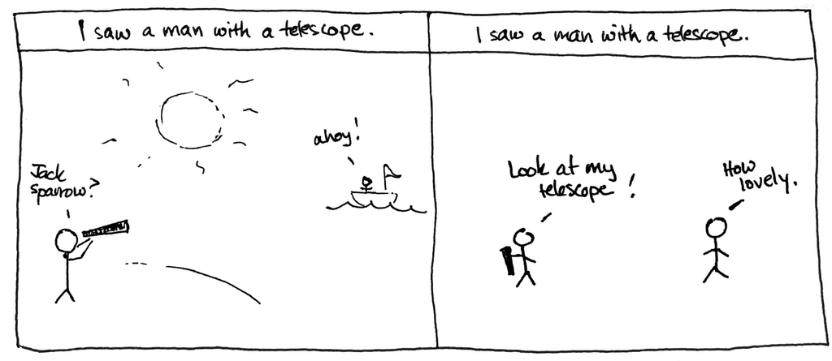

### 最后说几句Some Closing Remarks

上面描述的函子有点让人联想到拓扑量子场论，后者是一个从配边范畴（另一个紧闭范畴）到复希尔伯特空间范畴的函子。但在 2014 年，Anne Preller 证明：从一个由有限基本类型集自由生成的前群 $P$ 到 $\textsf{FVect}$ 的函子，只能映到一维空间。她的证明的关键在于，$P$ 是一个偏序集，因此任意两个对象之间至多有一个态射。特别地，从一个对象到其自身的任何态射都必定是恒等态射。因此，如果 $a$ 属于 $P$，那么态射 $(1_a\cdot \eta_a)\circ(\epsilon_a\cdot 1_a)$，其源与目标如 $a a^r a\to a a^r a$ 所示，就必须等于 $a a^r a$ 上的恒等态射。用图来表示：

[figure not shown]

。现在考虑一个函子 $P\to \mathsf{FVect}$。它把 $P$ 中的 $a$ 指定为 $\mathsf{FVect}$ 中的向量空间 $A$，并把 $(1_a\cdot \eta_a)\circ(\epsilon_a\cdot 1_a)$ 指定为相应的线性映射
$$(1_A\cdot \eta_A)\circ(\epsilon_A\cdot 1_A)\colon A\otimes A^*\otimes A\to A\otimes A^*\otimes A$$
。我们把这个映射简记为 $f$：$f =$

[figure not shown]

，而且它必须是一个同构。现在，如果 $A$ 的维数至少为 2，就可以选取正交的基向量 $e_1$ 和 $e_2$，从而有 $e_1\otimes e_2^*\otimes e_1\in A\otimes A^*\otimes A$。由于 $\epsilon_A$ 计算的是 $e_1$ 与 $e_2^*,$ 的内积，我们便有 $f(e_1\otimes e_2^*\otimes e_1)=0.$。因此，$f$ 不是单射，也就不可能是同构。

This functor described above is somewhat reminiscent of a *topological quantum field theory*, which is a functor from the category of cobordisms (another compact closed category) to the category of complex Hilbert spaces. But in 2014 Anne Preller showed that the only functors from a pregroup $P$ freely generated on a finite set of basic types to $\textsf{FVect}$ are those mapping to one-dimensional spaces. The key to her proof is the fact that $P$ is a *poset* and hence there is at most *one* morphism between any two objects. In particular, any morphism from an object to itself must be the identity. As a consequence, if $a$ is in $P$ then the morphism $(1_a\cdot \eta_a)\circ(\epsilon_a\cdot 1_a)$ from $a a^r a\to a a^r a$ must equal the identity on $a a^r a$. Graphically:

[figure not shown]

Now consider a functor $P\to \mathsf{FVect}$. It assigns $a$ in $P$ to a vector space $A$ in $\mathsf{FVect}$, and it assigns $(1_a\cdot \eta_a)\circ(\epsilon_a\cdot 1_a)$ to the corresponding linear map,
$$(1_A\cdot \eta_A)\circ(\epsilon_A\cdot 1_A)\colon A\otimes A^*\otimes A\to A\otimes A^*\otimes A$$
, which we’ll just denote by $f$, $f =$

[figure not shown]

and which must be an isomorphism. Now if the dimension of $A$ is at least 2, then we can choose orthogonal basis vectors $e_1$ and $e_2$ so that $e_1\otimes e_2^*\otimes e_1\in A\otimes A^*\otimes A$. And since $\epsilon_A$ computes the inner product between $e_1$ and $e_2^*,$ we have $f(e_1\otimes e_2^*\otimes e_1)=0.$ Therefore $f$ is not injective, and so it cannot be an isomorphism.

直观上，原因或许在于，前群的态射太少，不足以捕捉语义。特别是，前群无法让我们区分类型串的不同解析方式。同一个类型串可能以几种方式归约，比如 (Men and women) whom I like（我喜欢的男人和女人）与 Men and (women whom I like)（男人以及我喜欢的女人），而前群中的态射无法体现这种区别。因此，在某种意义上，前群句法没有为意义留下足够的“腾挪空间”，输出就只能是一维向量空间。但事情并非无可挽回！正如 Preller 所证明的，把自由前群换成自由紧闭范畴，就能解决这个问题。更多细节请参见她的论文《从逻辑模型到分布模型》（“From Logical to Distributional Models”）。

The intuition is, perhaps, that pregroups have *too few* morphisms to capture the semantics. In particular, pregroups do not allow us to distinguish different parsings of strings of types. One string may reduce in several ways—e.g. (Men and women) whom I like vs. Men and (women whom I like)—and the morphisms in a pregroup do not account for this. So in some sense, there isn’t enough “wiggle room” for meaning in pregroup syntax, so the output can only be a one-dimensional vector space. But all is not lost! As Preller showed, the problem can be fixed by replacing a free pregroup with a free compact closed category. For more details, see her paper [“From Logical to Distributional Models.”](https://arxiv.org/pdf/1412.8527.pdf)

### 延伸阅读Further Reading

想进一步了解 Baez 和 Pollard 的工作：

**For more on the work of Baez and Pollard**:

- 一定要读一读他们的论文《反应网络的组合框架》（“A Compositional Framework for Reaction Networks”）。$n$-Category Café 上也有相关的介绍文章，包括 Baez 的一篇同名博文，以及 Maru Sarazola 的《动力系统及其稳态》（“Dynamical Systems and Their Steady States”）。

  Certainly take a look at their paper, [“A Compositional Framework for Reaction Networks”](https://arxiv.org/abs/1704.02051). The $n$-Category Café also contains expositions, including [a post](https://golem.ph.utexas.edu/category/2017/07/a_compositional_framework_for_2.html) by Baez with the same title and [“Dynamical Systems and Their Steady States”](https://golem.ph.utexas.edu/category/2018/04/dynamical_systems_and_their_st.html) by Maru Sarazola.
- 第 3.1 节的例子可以在 Baez 的讲座《网络的数学》（“The Mathematics of Networks”）中找到；这个讲座在 YouTube 上，讲得格外通俗易懂。

  The examples in Section 3.1 can be found in [“The Mathematics of Networks”](https://www.youtube.com/watch?v=IyJP_7ucwWo), a wonderfully accessible talk by Baez on YouTube.
- 装饰余跨度的全部形式体系都可以在 Brendan Fong 的学位论文《开放与互联系统的代数》（“The Algebra of Open and Interconnected Systems”）中找到。作为 ACT 研讨班活动的一部分，Jonathan Lorand 和 Fabrizio Genovese 在 $n$-Category Café 上写了一篇介绍 Fong 这篇论文的文章，题为《余跨度的超图范畴》（“Hypergraph Categories of Cospans”）。

  All of the decorated cospan formalism can be found in Brendan Fong’s thesis, [“The Algebra of Open and Interconnected Systems.”](https://arxiv.org/abs/1609.05382) As part of the ACT workshop, Jonathan Lorand and Fabrizio Genovese wrote about Fong’s thesis in an article titled [“Hypergraph Categories of Cospans”](https://golem.ph.utexas.edu/category/2018/02/hypergraph_categories_of_cospa.html) on the $n$-Category Café.
- 化学反应网络的框架还被用来为 ATP 耦合建模！这个项目诞生于 ACT 研讨班期间。想了解更多，可以看看 Baez 的 Azimuth 博客上的《通过涌现守恒律实现耦合》（“Coupling Through Emergent Conservation Laws”）。

  The framework of chemical reaction networks is also being used to model ATP coupling! This project was birthed during the ACT workshop. For more, take a look at [“Coupling Through Emergent Conservation Laws ”](https://johncarlosbaez.wordpress.com/2018/06/27/coupling-through-emergent-conservation-laws-part-1) on Baez’s Azimuth blog.

想进一步了解 Coecke、Sadrzadeh 和 Clark 的工作：

**For more on the work of Coecke, Sadrzadeh, and Clark**:

- YouTube 上有一段很有趣的五分钟视频（是 Minute Physics 的风格！），叫作《量子理论如何帮助理解自然语言》（“How Quantum Theory Can Help Understanding Natural Language”），用非技术性的方式出色地讲解了 DisCoCat 背后的思想。

  There is a delightful 5-minute YouTube video (made in the style of [Minute Physics](https://www.youtube.com/user/minutephysics)!) called [“How Quantum Theory Can Help Understanding Natural Language”](https://www.youtube.com/watch?v=99keybEZN4g) that does an excellent job of explaining the ideas behind DisCoCat in a non-technical way.
- 上一节的 yellow banana 例子只是个玩具例子，目的是展示 DisCoCat 意义模型中的函子。不过，既然这是一篇关于应用范畴论的文章，你肯定还想看看实际应用！想了解实际实现 DisCoCat 模型所得的实证数据，可以读一读：

  The *yellow banana* example of the previous section was just a toy example meant to showcase the functor of the DisCoCat model of meaning. But this is a document on *applied* category theory, and so you’d surely like to see some applications! For empirical data arising from actual implementations of the DisCoCat model, take a look at:
  - Edward Grefenstette 和 Mehrnoosh Sadrzadeh 的《范畴式组合分布意义模型的实验支持》（“Experimental support for a categorical compositional distributional model of meaning”）。

    [“Experimental support for a categorical compositional distributional model of meaning”](http://www.aclweb.org/anthology/D11-1129) by Edward Grefenstette and Mehrnoosh Sadrzadeh
  - Dimitri Kartsaklis 和 Mehrnoosh Sadrzadeh 的《为构造句子向量而对词张量进行预先消歧》（“Prior disambiguation of word tensors for constructing sentence vectors”）。

    [“Prior disambiguation of word tensors for constructing sentence vectors”](https://www.cs.ox.ac.uk/files/5725/karts_sadr_emnlp.pdf) by Dimitri Kartsaklis and Mehrnoosh Sadrzadeh
  - Mehrnoosh Sadrzadeh 的《从量子力学的范畴框架到自然语言语义学：量子化、Frobenius 代数与双代数》（“Quantization, Frobenius and bi-algebras from the categorical framework of quantum mechanics to natural language semantics”）。

    [“Quantization, Frobenius and bi-algebras from the categorical framework of quantum mechanics to natural language semantics”](https://www.frontiersin.org/articles/10.3389/fphy.2017.00018/full) by Mehrnoosh Sadrzadeh
- 作为应用范畴论研讨班活动的一部分，$n$-Category Café 也专门介绍过 DisCoCat 模型。实际上，还介绍了两次！这两篇博文是：

  The DisCoCat model was also featured on the [$n$-Category Café](https://golem.ph.utexas.edu/category/) as part of the [Applied Category Theory Workshop.](http://www.appliedcategorytheory.org/school/) In fact, it was featured *twice*! The two blog posts are:
  - Corey Griffith 和 Jade Master 的《用范畴论研究语言学》（“Linguistics Using Category Theory”）。这篇写得非常精彩的文章再次概述了 DisCoCat 模型，还给出了另一个玩具例子。也别忘了看看评论区，那里有一些很不错的讨论！

    [“Linguistics Using Category Theory”](https://golem.ph.utexas.edu/category/2018/02/linguistics_using_category_the.html) by Corey Griffith and Jade Master. This wonderfully written article gives another recap of the DisCoCat model, as well as another toy example. Check out the comment section, too. There are some nice discussion going on there!
  - Brad Theilman 和我合写的《认知、凸性与范畴论》（“Cognition, Convexity, and Category Theory”）。这篇博文概述了论文《相互作用的概念空间 I》（“Interacting Conceptual Spaces I”）。在这篇论文中，作者把 DisCoCat 模型的语义范畴从 $\textsf{FVect}$ 换成了旨在更贴近人类认知的另一种范畴，也就是凸空间！这是调整函子语义学中语义部分的一个绝佳例子。

    [“Cognition, Convexity, and Category Theory”](https://golem.ph.utexas.edu/category/2018/03/cognition_convexity_and_catego.html) by Brad Theilman and me. This blog post is a summary of [“Interacting Conceptual Spaces I,”](https://arxiv.org/pdf/1703.08314.pdf) a paper in which the authors change the semantics category of the DisCoCat model from $\textsf{FVect}$ to something that attempts to model human cognition more closely, namely convex spaces! This is a great example of tweaking the *semantics* part of *functorial **semantics***.
- 最后推荐的资源与 DisCoCat 无关，但依然属于“机器学习 + 应用范畴论”这条思路，所以我想拿来分享一下：你知道反向传播是一个函子吗？

  The last suggested resource is unrelated to DisCoCat, but it’s still in the vein of machine learning + applied category theory and so I thought I’d share: Did you know that [backpropagation is a functor](https://arxiv.org/pdf/1711.10455.pdf)?

## 且慢！还有更多……But Wait! There’s More...

应用范畴论的内容远不止这些，我介绍的只是精挑细选出来的一小部分思想。值得看、值得学、值得做的事情还有太多！因此，在结束这篇笔记之前，我再留下一些链接，让你能从中发现应用范畴论的其他主题、构造和例子。

There’s much more to applied category theory—I’ve only presented a very tiny subset of hand-selected ideas. But there’s so much more to see, learn, and do! So to close out these notes, I’ll leave you with a few more links where you can discover other *themes, constructions,* and *examples* of applied category theory.

- 首先是应用范畴论的主网站，上面有：

  To start, there’s the [main Applied Category Theory webpage](http://www.appliedcategorytheory.org/), which has
  - 2018 年在荷兰莱顿洛伦兹中心举行的研讨班的介绍；

    a description of the [2018 workshop](http://www.appliedcategorytheory.org/workshops/) that took place at the [Lorentz Center](https://www.lorentzcenter.nl/lc/web/2018/969/info.php3?wsid=969&venue=Oort) in Leiden, Netherlands
  - 由 Bob Coecke 在牛津主持的 2019 年研讨班的招募启事。

    a call for the [2019 workshop](http://www.appliedcategorytheory.org/act-2019/), to be hosted by Bob Coecke in Oxford.
- Jelle Herold 和 Statebox 的伙伴们录制了 2018 年研讨班的大部分报告，你可以在这里观看：https://statebox.org/events/act-leiden.html。报告人包括 Samson Abramsky、John Baez、Bob Coecke、Kathryn Hess、Aleks Kissinger、Tom Leinster、David Spivak，以及许多其他人！

  Jelle Herold and the folks at [Statebox](https://statebox.org/) filmed most of the 2018 workshop talks, and you can watch them here: https://statebox.org/events/act-leiden.html. Speakers include Samson Abramsky, John Baez, Bob Coecke, Kathryn Hess, Aleks Kissinger, Tom Leinster, David Spivak, and many more!
- 2018 年 3 月，美国国家标准与技术研究院还举办过一次应用范畴论研讨班。报告的幻灯片和视频可以在这里找到：http://www.appliedcategorytheory.org/nist-workshop-slides/

  Back in March 2018, there was an applied category theory workshop hosted at the National Institute of Standards and Technology. Slides and videos of the talk can be found here:  
  http://www.appliedcategorytheory.org/nist-workshop-slides/
- 还有 Brendan Fong 和 David Spivak 的《组合性七讲》（Seven Sketches in Compositionality，副标题为“应用范畴论入门”）。我已经多次提到这本书了，那是因为它实在是块瑰宝！（我才读完序言，就被打动了。）它以生动有趣、富于洞见的方式，介绍了应用范畴论中更多的主题、构造和例子。更棒的是，它不要求读者预先掌握任何范畴论知识。本书基于两位作者在麻省理工学院讲授的一门课程。课程视频可以在这里找到：http://math.mit.edu/ dspivak/teaching/sp18/

  There is also [*Seven Sketches in Compositionality*](https://arxiv.org/pdf/1803.05316.pdf) (subtitle: “An Invitation to Applied Category Theory”) by Brendan Fong and David Spivak. I’ve referenced this book several times already, but that’s because it’s such a gem! (I was sold just after reading the preface.) It’s a delightful and insightful introduction to more themes, more constructions, and more examples within applied category theory. Even better, no prior knowledge of category theory is assumed. The book is based on a MIT course the authors taught. You can find videos of their lectures here: [http://math.mit.edu/ dspivak/teaching/sp18/](http://math.mit.edu/~dspivak/teaching/sp18/)
- 这些好资源似乎还嫌不够，John Baez 又开设了一门免费的应用范畴论在线课程。参与者一直在一起研读《组合性七讲》。课程讲授及随后的讨论简直是一座宝库，里面满是令人兴奋的数学：https://forum.azimuthproject.org/categories/applied-category-theory-course。也别忘了看看他的 Azimuth 博客上“applied category”标签下的文章。

  And as if all of these great resources weren’t enough, John Baez is running a *free online course* on applied category theory. Participants have been working through the *Seven Sketches* book. The lectures and ensuing discussions are a treasure trove of exciting mathematics: https://forum.azimuthproject.org/categories/applied-category-theory-course. Also be sure to take a look at the “applied category” tag on his blog, [Azimuth](https://johncarlosbaez.wordpress.com/?s=applied+category).
[^1]: 如果你想循序渐进地入门（纯）范畴论，可以从下面几篇文章开始：

    For a gentle introduction to (pure) category theory, here are a few places to start:
    - 《范畴论究竟是什么？》（What is Category Theory, Anyway?）

      [What is Category Theory, Anyway?](http://www.math3ma.com/mathema/2017/1/17/what-is-category-theory-anyway)
    - 《什么是范畴？》（What is a Category?）

      [What is a Category?](https://www.math3ma.com/blog/what-is-a-category-definition-and-examples)
    - 《什么是函子？》（What is a Functor?）

      [What is a Functor?](https://www.math3ma.com/blog/what-is-a-functor-part-1)
    - 《什么是自然变换？》（What is a Natural Transformation?）

      [What is a Natural Transformation?](https://www.math3ma.com/blog/what-is-a-natural-transformation)

    第一个链接中还列出了一些其他的范畴论学习推荐资源。

    At the first link, you’ll find a list of other recommended resources for learning about category theory.
[^2]: 《无源线性网络的组合框架》（A Compositional Framework for Passive Linear Networks），https://arxiv.org/pdf/1504.05625.pdf

    *A Compositional Framework for Passive Linear Networks*, https://arxiv.org/pdf/1504.05625.pdf
[^3]: 虽然这些条目是依次列出的，但它们彼此紧密交织。主题为构造提供动机；构造体现主题；而主题与构造都在例子中鲜活起来。

    Although the items are listed *linearly,* they are very much intertwined. The themes motivate the constructions; the constructions embody the themes, and both the themes and the constructions come to life in the examples.

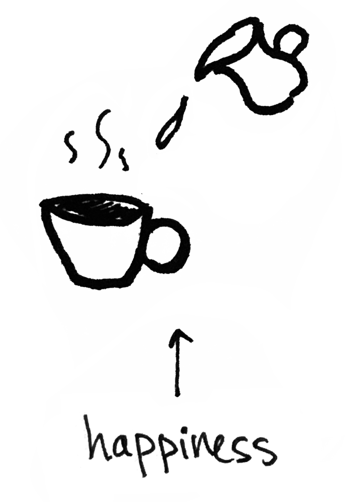

[^5]: “函子语义学”一词由 William Lawvere 创造。$\leftarrow$ 这正是 Lawvere 在与 Stephen Schanuel 合著的《概念数学》（Conceptual Mathematics）中对“函子”一词的定义！顺带一提，这是一本很不错的入门书。

    The phrase “functorial semantics” was coined by William Lawvere.  
    $\leftarrow$ This is how Lawvere *defines* the word “functor” in his book with Stephen Schanuel, [Conceptual Mathematics](https://www.amazon.com/Conceptual-Mathematics-First-Introduction-Categories/dp/052171916X)! It’s a nice introductory text, by the way.
[^6]: 我用英语来类比说明句法与语义的区别，但这可不只是一个类比！正如我们将在第 3.2 节看到的，下面这两组对应关系：

    I’m using English language as an analogy to illustrate syntax vs. semantics, but it’s **more** than an analogy! As we’ll see in Section 3.2, the pairings

    “语法 $\rightsquigarrow$ 句法” “词的意义 $\rightsquigarrow$ 语义”

    “grammar $\rightsquigarrow$ syntax”  
    “meanings of words $\rightsquigarrow$ semantics”

    在应用范畴论中会成为相当字面意义上的对应！

    become quite literal in applied category theory!

[figure not shown]

[^8]: 我就把你的沉默当作“没有”了。

    I’ll take your silence as a No.
[^9]: 群元素就像动词。它们会做事情！想从范畴的角度进一步了解这一观念，请看看 Math3ma 上的《从范畴的角度看群元素》（Group Elements, Categorically）一文。

    Group elements are like verbs. They DO stuff! For more on this notion from a categorical perspective, check out the article [Group Elements, Categorically](http://www.math3ma.com/mathema/2017/2/16/group-elements-categorically) on Math3ma.
[^10]: 如果对于某个集合 $X$，我们把 $\text{Aut}(V)$ 换成 $\text{Aut}(X)$（即 $X$ 上的自同构，也就是双射，所构成的群），那么群同态 $G\to \text{Aut}(X)$ 就恰好是 $X.$ 上的一个群作用。

    If we replace $\text{Aut}(V)$ by $\text{Aut}(X)$ for some set $X$ (i.e. the group of automorphisms, i.e. bijections, on $X$), then a group homomorphism $G\to \text{Aut}(X)$ is precisely a group action on $X.$

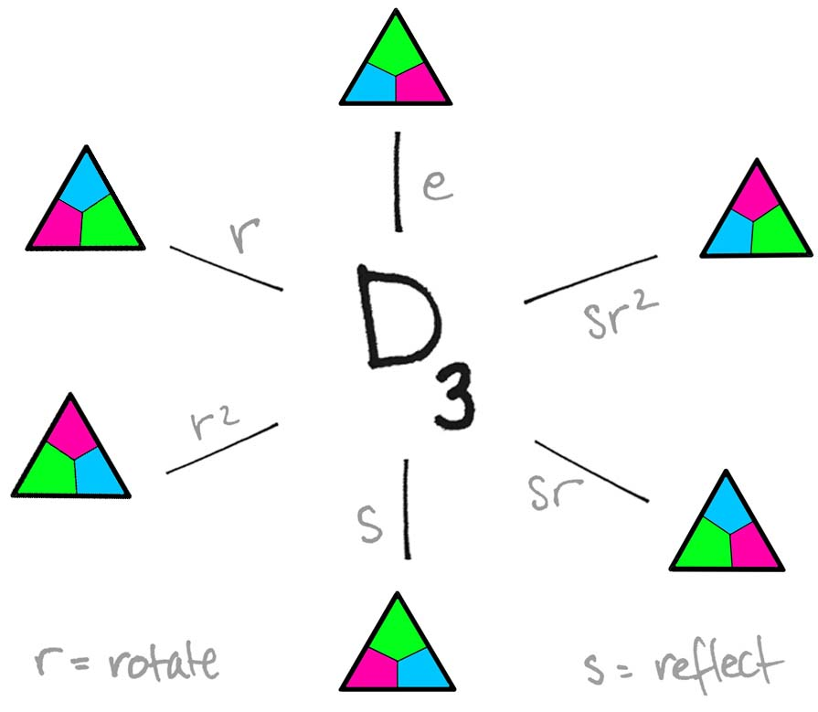

[^12]: 每个群 $G$ 都产生一个范畴，它只有一个对象 $\bullet$（即这个群本身），并且每个群元素 $g\in G$ 都对应一个态射 $\bullet\overset{g}{\to}\bullet$。复合由群运算给出。

    Every group $G$ gives rise to a category having a single object $\bullet$ (the group itself) and a morphism $\bullet\overset{g}{\to}\bullet$ for each group element $g\in G$. Composition is given by the group operation.
[^13]: 还有一个例子，我实在忍不住要分享：操作子！如果你不熟悉操作子，只需知道这是群论例子的加强版。如果你熟悉操作子，那你就知道，这确实是群论例子的加强版。

    Here’s another example I can’t resist sharing: **operads!** If you’re not familiar with [operads](http://www.math3ma.com/mathema/2017/10/23/what-is-an-operad-part-1), just know that this is a souped-up version of the group theory example. If you *are* familiar with operads, then you know this is the souped-up version of the group theory example.

    操作子是句法的一个例子，而该操作子上的代数则提供语义。例如，给定一个向量空间 $V,$，从［交换、结合、李、泊松、……］操作子到 $V$ 上的自同态操作子的操作子同态，就是一个［交换、结合、李、泊松、……］代数！也就是说，这个保持结构的同态把每个抽象的 $n$ 元运算解释成一个实实在在、具体的运算 $V^{\otimes n}\to V$。

    An operad is an example of syntax, while an algebra over that operad provides the semantics. For example, given a vector space $V,$ an operad homomorphism from the [commutative, associative, Lie, Poisson,...] operad to the endomorphism operad on $V$ **IS** a [commutative, associative, Lie, Poisson,...]-algebra! That is, the structure-preserving homomorphism provides an *interpretation* of each abstract $n$-ary operation as a actual, concrete operation $V^{\otimes n}\to V$.
[^14]: 下面这段话真是在题外话里再说题外话了，不过：我也喜欢把单纯集看作函子语义学的一个实例。单纯集 $X$ 有点像句法，而拓扑空间像语义。几何实现 $X\mapsto |X|$ 提供了从前者到后者的映射。

    This next comment is really digressing from the digression, but: I also like to think of simplicial sets as an instance of functorial semantics. A simplicial set $X$ is a bit like syntax, while a topological space is like semantics. [Geometric realization](https://ncatlab.org/nlab/show/geometric+realization) $X\mapsto |X|$ provides a map from one to the other.
[^15]: 幺半范畴之间的函子 $F\colon \textsf{C}\to\textsf{D}$ 称为松幺半函子，如果对于 $\textsf{C}$ 中的每一对对象 $c,c'$，都有一个态射
    $$Fc\otimes Fc'\to F(c\otimes c')$$
    （这些态射组合成一个自然变换）。如果 $Fc\otimes Fc'\cong F(c\otimes c')$，它就称为强幺半函子；如果 $Fc\otimes Fc' = F(c\otimes c')$，它就称为严格幺半函子。

    A functor $F\colon \textsf{C}\to\textsf{D}$ between monoidal categories is called **lax monoidal** if for every pair of objects $c,c'$ in $\textsf{C}$ there is a morphism
    $$Fc\otimes Fc'\to F(c\otimes c')$$
    (which assembles into a natural transformation.) It’s called **strong monoidal** if $Fc\otimes Fc'\cong F(c\otimes c')$, and it’s called **strict monoidal** if $Fc\otimes Fc' = F(c\otimes c')$.
[^16]: 你会注意到，在脚注 15 中我省略了括号，写的是 $Fc$，而不是 $F(c)$。我偏爱这种写法的原因是范畴论式的！让我从集合说起，解释一下：你知道集合 $X$ 中的元素 $x$，其实就是一个函数 $\{\ast\}\to X$ 吗？其中 $\{\ast\}$ 表示单元素集合。确实如此。函数 $\{\ast\}\to X$ 完全由它把那个唯一的点 $\ast$ 送到哪里来确定。因此，既然元素 $x$ 就是一个箭头 $\{\ast\}\to X$，我们不妨把这个箭头也标记为 $x,$，即
    $$x\colon \{\ast\}\to X$$
    。现在，如果再有一个函数 $f\colon X\to Y,$，那么元素 $f(x)\in Y$ 就恰好是复合
    $$\{\ast\}\overset{x}{\to} X\overset{f}{\to}Y$$
    。也就是说，
    $$f(x)=f\circ x =fx$$
    ，其中右边我省略了复合符号 $\circ$，因为这样更清爽。就是这么回事！元素 $f(x)\in Y$ 就是函数 $fx$。既然像你我这样习惯范畴式思考的人更喜欢箭头而不是元素（因为米田。还有，我们或许正在重新思考集合论），那么 $fx$ 这种记法，以及更一般地，上面的 $Fc$ 这种记法，就更讨人喜欢。顺带一提，这一切都与 Lawvere 的广义元素思想有关：一个态射 $A\to B$ 其实就是“$B$ 中一个形如 $A$ 的元素”。想看一些例子，可以读读 Math3ma 上的《图表是一个函子》（“A Diagram is a Functor”）和《米田嵌入》（“The Yoneda Embedding”）。广义元素与函子语义学密切相关，所以这两个链接都值得一读！

    In footnote 15 you’ll notice I dropped parentheses and wrote $Fc$ rather than $F(c)$. The reason for my preference is *categorical!* Let me explain by saying a few words about sets: Did you know that an element $x$ in a set $X$ is the same thing as a function $\{\ast\}\to X$, where $\{\ast\}$ denotes the one-element set? It’s true. The function $\{\ast\}\to X$ is uniquely determined by where it sends that one point $\ast$. So since an element $x$ is the same thing as an arrow $\{\ast\}\to X$, we might as well label *that* arrow by $x,$
    $$x\colon \{\ast\}\to X$$
    Now if we have another function $f\colon X\to Y,$ then an element $f(x)\in Y$ is *precisely* the composition
    $$\{\ast\}\overset{x}{\to} X\overset{f}{\to}Y$$
    That is,
    $$f(x)=f\circ x =fx$$
    where on the right hand side, I’ve omitted the composition symbol $\circ$ because it’s cleaner. So there you have it! An element $f(x)\in Y$ is the same as a function $fx$. And since categorically-minded folks (such as you and I) prefer arrows over elements (Because of [Yoneda](http://www.math3ma.com/mathema/2017/8/30/the-yoneda-perspective). Also, we might be [rethinking set theory](https://arxiv.org/pdf/1212.6543.pdf).), the notation $fx$—and more generally, $Fc$ as above—is preferred. By the way, this is all related to Lawvere’s **philosophy of generalized elements**, which is the idea that a morphism $A\to B$ is really an “$A$-shaped element in $B$.” For some examples, check out the articles [“A Diagram is a Functor”](http://www.math3ma.com/mathema/2018/1/10/a-diagram-is-a-functor) as well as [“The Yoneda Embedding”](http://www.math3ma.com/mathema/2017/9/6/the-yoneda-embedding) on Math3ma. Generalized elements are closely related to functorial semantics, so both links are worth a read!
[^17]: “$\textsf{C}$ 中的一个幺半群就是一个松幺半函子 $\mathbb{1}\to \textsf{C}$”这一想法，与上一页页边注中“$X$ 中的一个元素就是一个函数 $\{\ast\}\to X$”的说法完全类似。在这两种情况下，我们都有两个同类的对象 $A$ 和 $B$（本页是幺半范畴，上一页是集合），以及一个保持结构的映射 $A\to B$。

    The idea that “a monoid in $\textsf{C}$ is a lax monoidal functor $\mathbb{1}\to \textsf{C}$” is **completely analogous** to claim that “an element in $X$ is a function $\{\ast\}\to X$” made in the margin on the previous page. In both cases, with have two objects $A$ and $B$ of the same kind (monoidal categories on this page; sets on the previous page) together with a structure-preserving map $A\to B$.

    （不过要提醒一下：松幺半函子只是在一定程度上保持结构，所以才叫“松”。而函数保持结构则是空泛成立的，因为集合根本没有附带任何结构！不过，我又扯远了……）

    (Caveat: a lax monoidal functor is only *somewhat* structure-preserving. That’s why it’s called *lax*. And a function is vacuously structure-preserving since sets don’t have any structure! But I digress...)

    在这两种情况下，对象 $A$ 都是平凡的（严格地说，是终对象），可以说，它只是一个点。而且在这两种情况下，箭头都给出了这个点在 $B$ 这个背景中的一种解释。

    In both cases the object $A$ is trivial (technically, [terminal](https://en.wikipedia.org/wiki/Initial_and_terminal_objects))—it’s just a *point,* so to speak. And in both cases the arrow provides an interpretation of that point within the context of $B$.

    换一种说法，我们在用一个点状对象探测 $B$。当 $B$ 是集合时，用一个点去探测它，就会选出一个元素。当 $B$ 是幺半范畴时，用一个点去探测它，就会选出一个幺半群！

    To phrase it another way, we are *probing* $B$ with a point-shaped object. In the case when $B$ is a set, probing it with a point will pick out an element. In the case when $B$ is a monoidal category, probing it with a point will pick out a monoid!

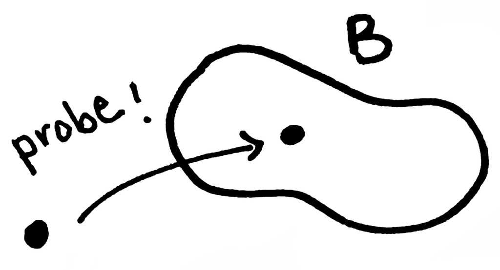

[^18]: 这里的 Frege 指的是 Gottlob Frege（戈特洛布·弗雷格）。

    Frege as in *Gottlob Frege.*
[^19]: 另一个候选刊名是 Applied Category Theory（《应用范畴论》），不过最终 Compositionality（《组合性》）得票最多。

    A [contending title](https://golem.ph.utexas.edu/category/2018/05/compositionality.html#c053932) was *Applied Category Theory*, but in the end *Compositionality* had the most votes.
[^20]: 矩阵分解是数学中组合性的另一个例子。例如，每个 $n\times m$ 矩阵 $M$ 都有奇异值分解，也就是说，它可以写成三个矩阵的乘积 $M=UDV^\dagger$，其中 $U$ 和 $V$ 是酉方阵（这里 $V^\dagger$ 表示 $V$ 的共轭转置），而 $D$ 是一个矩形对角矩阵。直观上，线性变换 $M$ 可以分解为一次旋转，接着一次错切，再接着一次旋转。因此，你可以通过理解组成它的各个部分，也就是各个因子，以及它们怎样复合在一起，来分析这个变换（或者，如果 $M$ 编码的是你的数据集，就分析这个数据集）。更一般地，我喜欢把张量网络看作组合性的一个好例子，不过谈这个可能就离题太远了。也许改天再说！

    Matrix factorization provides another illustration of compositionality in mathematics. As an example, every $n\times m$ matrix $M$ has a *singular value decomposition*, which means it can be written as a product of three matrices $M=UDV^\dagger$ where $U$ and $V$ are unitary square matrices (here $V^\dagger$ denotes the conjugate transpose of $V$) and $D$ is a rectangular diagonal matrix. Intuitively then, the linear transformation $M$ can be broken down into a rotation followed by a shear followed by another rotation. So you can analyze your transformation (or your data set, if that’s what $M$ is encoding) by understanding its constituent pieces—the factors—and how they compose together. More generally, I like to think that tensor networks are a good example of compositionality, but such a discussion might take us too far off course. Perhaps another day!
[^21]: 第 7 页的题外话主要讨论了幺半群和幺半范畴，不过现在我会假定读者还不熟悉它们，从头讲起。

    Monoids and monoidal categories were the main focus in the digression on page 7, but now I’ll proceed as if they are new to the reader.
[^22]: “$X$ 上的二元运算”不过是函数 $X\times X\to X.$ 的一个听起来高级些的名字。所以，$\bullet$ 是一个函数 $\bullet\colon X\times X\to X.$。它把一对元素 $(x,y)\in X\times X$ 指定为一个元素 $x\bullet y\in X$。说元素 $1\in X$ 充当 $\bullet$ 的单位元，就是说它对所有 $x\in X.$ 都满足 $1\bullet x=x\bullet 1=x$。

    A “*binary operation* on $X$” is just the fancy name for a function $X\times X\to X.$ So $\bullet$ is a function $\bullet\colon X\times X\to X.$ It assigns to a pair $(x,y)\in X\times X$ an element $x\bullet y\in X$. To say that an element $1\in X$ serves as an *identity* for $\bullet$ means it satisfies $1\bullet x=x\bullet 1=x$ for all $x\in X.$
[^23]: 这里还有一点需要补充，因为我们希望 $\otimes$ 满足结合律：对于范畴 $\textsf{C}$ 中的任意对象 $A,B,C$，我们希望有 $A\otimes(B\otimes C)=(A\otimes B)\otimes C$。可惜，事物很少会严格相等。作为补偿，我们改为要求存在一个同构 $A\otimes(B\otimes C)\cong (A\otimes B)\otimes C$，而且这个同构应当具有良好的性质。我在这里不展开细节，不过你当然可以到维基百科的幺半范畴词条上了解更多。想读一篇精彩的文章，领略幺半范畴的丰富内涵，我强烈推荐 John Baez 和 Mike Stay 的《罗塞塔石碑》（“A Rosetta Stone”）。它是块瑰宝。

    There’s a little more to the story here since we want $\otimes$ to be associative: for any objects $A,B,C$ in the category $\textsf{C}$, we want $A\otimes(B\otimes C)=(A\otimes B)\otimes C$. Alas, things are rarely equal on the nose. To compensate for this, we ask instead that there exist an *isomorphism* $A\otimes(B\otimes C)\cong (A\otimes B)\otimes C$, which should behave nicely. I won’t go into the details here, but of course you can find more on the Wikipedia page on [monoidal categories](https://en.wikipedia.org/wiki/Monoidal_category). For a delightful exposition on the richness of monoidal categories, I strongly recommend [“A Rosetta Stone”](http://math.ucr.edu/home/baez/rosetta.pdf) by John Baez and Mike Stay. It is a *gem*.
[^24]: 容我解释一下“以及态射”这部分。首先记住，$\otimes$ 是一个函子！这意味着它既对对象作指定，也对态射作指定。例如，考虑 $(\textsf{Set},\times,\{\ast\})$，其中 $\times$ 把一对集合 $(A,B)$ 指定为它们的笛卡尔积 $A\times B$。给定两个函数 $f\colon A\to B$ 和 $g\colon A'\to B'$，它把这一对函数 $(f,g)$ 指定为函数 $f\times g\colon A\times B\to A'\times B'$，定义为：$(f\times g)(a,b):=(fa,gb)$。这就是幺半积作用于态射的一个例子。更一般地，$f\otimes g$ 究竟是什么，取决于 $\otimes$ 的具体定义。

    Allow me to explain the “and morphisms” part. First remember, $\otimes$ is a *functor*! That means it’s an assignment on objects *and* on morphisms. Consider $(\textsf{Set},\times,\{\ast\})$, for example, where $\times$ assigns to a pair of sets $(A,B)$ their Cartesian product $A\times B$. And given two functions $f\colon A\to B$ and $g\colon A'\to B'$, it assigns to the pair $(f,g)$ the function $f\times g\colon A\times B\to A'\times B'$, which is defined by: $(f\times g)(a,b):=(fa,gb)$. This is one example of the action of the monoidal product on morphisms. More generally, what $f\otimes g$ *is* depends on the explicit definition of $\otimes$.

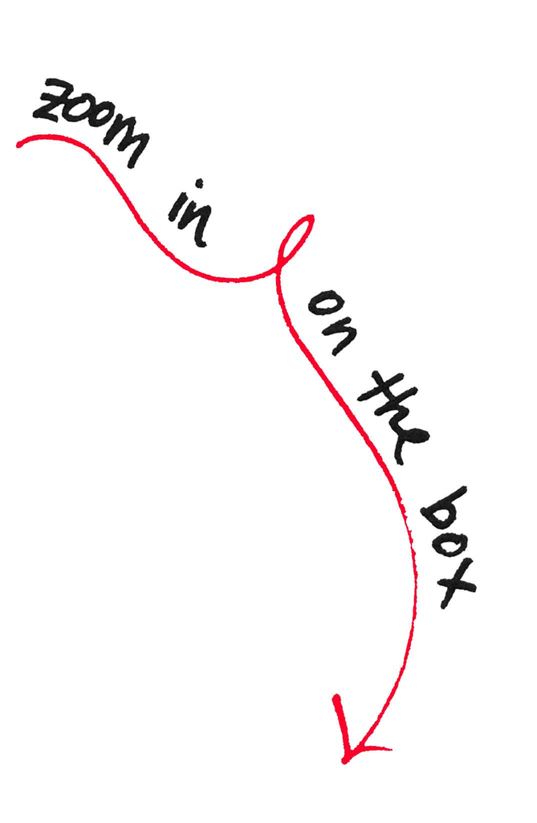

[^26]: 严格地说，每个对象都必须有一个左对偶和一个右对偶。之所以需要区分左右，是因为并非所有幺半范畴都是对称幺半范畴。

    Technically, every object must have a *left* dual and a *right* dual. We need the distinction because not all monoidal categories are *symmetric* monoidal.
[^27]: 第 3.2 节的一次计算会用到 $\eta$ 和 $\epsilon$，所以最好明确地看看它们到底是什么样子。

    We’ll need $\eta$ and $\epsilon$ for a computation in Section 3.2, so it’s good to see what they look like explicitly.
[^28]: 注意：这里的“单位”不要与“幺半单位对象”混淆！

    Note: this unit is not to be confused with “monoidal unit”!
[^29]: 注意：counit（余单位）的读音是“coh-yew-nit”，不是“cow-nit”。这很重要。

    Note: *counit* is [pronounced](https://twitter.com/math3ma/status/965271641847685120) “coh-yew-nit” not “cow-nit.” This is [important](https://twitter.com/math3ma/status/965255364286574594).
[^30]: 这些 $\eta$ 映射称为左单位和右单位，而这些 $\epsilon$ 映射称为左余单位和右余单位。

    The $\eta$ maps are called the left and right **units**, and the $\epsilon$ maps are called the left and right **counits**.
[^31]: 这里，$\operatorname{id}_c$ 表示恒等态射 $\operatorname{id}_c\colon c\to c.$。

    Here $\operatorname{id}_c$ denotes the identity morphism $\operatorname{id}_c\colon c\to c.$
[^32]: $\leftarrow$ 在那句话中，我想表达的是弦图让事情轻松多了，不过你也可以说，应用范畴论学者同样（正在努力）让事情轻松多了。

    $\leftarrow$ In that sentence, I meant to convey that *string diagrams* make life so much easier, but one may argue that *applied category theorists* also (are working to) make life so much easier.
[^33]: 我们在第 15 页看到的柠檬派图，就是一个弦图的例子！

    The lemon pie diagram that we saw on page 15 is an example of a string diagram!

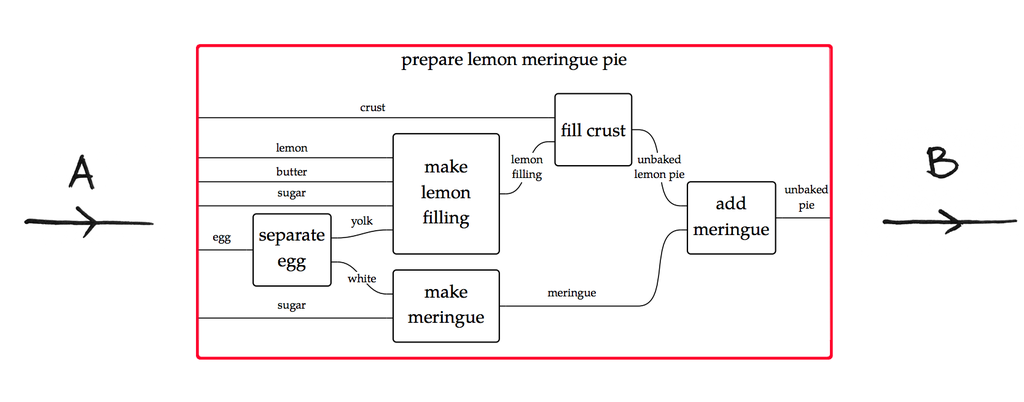

[^34]: 更一般地，幺半范畴 $(\mathsf{C},\otimes,1)$ 中的幺半单位对象 $1$，对 $\mathsf{C}$ 中的所有对象 $c$ 都满足 $1\otimes c\cong c \cong c\otimes 1$。

    More generally, the monoidal unit $1$ in a monoidal category $(\mathsf{C},\otimes,1)$ satisfies $1\otimes c\cong c \cong c\otimes 1$ for all objects $c$ in $\mathsf{C}$.
[^35]: 另一种画法是，有些人把 $\epsilon$ 和 $\eta$ 的图分别顺时针和逆时针旋转 $90^\circ$；因此，它们常被昵称为“杯和帽”。

    Alternatively, some folks will rotate the $\epsilon$ and $\eta$ diagrams by $90^\circ$ clockwise and counterclockwise, respectively, which is the reason for their common nickname of “cups and caps.”
[^36]: 注意：单位对象 $\mathbb{R}$ 所对应的（看不见的）箭头，指向哪边都行。幺半单位对象总是自对偶的！

    Note: the direction of the (invisible) arrow for the unit $\mathbb{R}$ can go either way. The monoidal unit is always self dual!
[^37]: 记住，“$\mathsf{FVect}$ 是对称幺半范畴”这句话的意思是，对于每一对向量空间 $V$ 和 $W.$，都存在一个同构 $V\otimes W\cong W\otimes V$。在弦图演算中，这意味着我们画箭头时的排列顺序无关紧要：

    Remember, the sentence “$\mathsf{FVect}$ is symmetric monoidal” means there is an isomorphism $V\otimes W\cong W\otimes V$ for every pair of vector spaces $V$ and $W.$ In string diagram calculus, this means that the order in which we draw our arrows doesn’t matter:

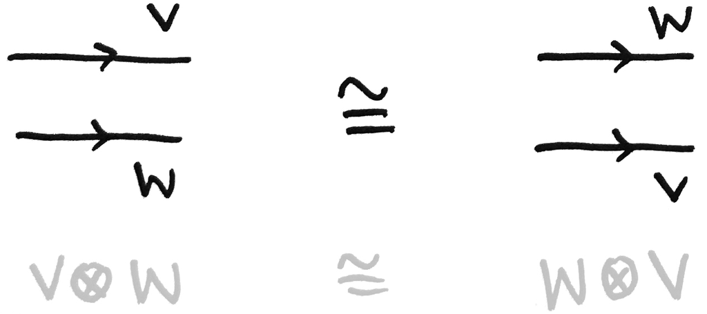

[^38]: 不妨动手玩一玩，验证第 17 页的单位与余单位映射确实满足这两个方程。

    For fun, verify that the unit and counit maps on page 17 do indeed satisfy these two equations.
[^39]: 虽然线性映射 $\mathbb{R}\to V^*\otimes W$ 本身不是 $V^*\otimes W$ 中的向量，但它可以与其中的一个向量等同起来，那就是 $\mathbb{R}$ 中的 1 在这个映射下的像！更一般地，对于 $\mathbb{R}$ 上的任意有限维向量空间 $A$，至少在集合的层面上，你总可以把 $\hom(\mathbb{R},A)$ 看作 $A$ 本身。这是因为遗忘函子 $U\colon \mathsf{FVect}\to \mathsf{Set}$ 是可表函子，其表示对象是 $\mathbb{R}$。换句话说，线性映射 $\mathbb{R}\to A$ 与 $A,$ 中的向量——视为其底层集合中的元素——一一对应：
    $$\hom(\mathbb{R},A)\cong UA$$
    。这与从单点集到集合 $X$ 的函数 $\{\ast\}\to X$ 与 $X,$ 中的元素一一对应完全类似：
    $$\hom(\{\ast\},X)\cong X$$
    。它也是第 9 页页边注中“探测”思想的另一种体现。

    While a linear map $\mathbb{R}\to V^*\otimes W$ is not itself a vector in $V^*\otimes W$, it can be identified with one, namely with the image of 1 in $\mathbb{R}$! More generally, for any finite-dimensional vector space $A$ over $\mathbb{R}$, you can always think of $\hom(\mathbb{R},A)$ as $A$ itself, at least at the set level. That’s because the forgetful functor $U\colon \mathsf{FVect}\to \mathsf{Set}$ is representable with representing object $\mathbb{R}$. In other words, linear maps $\mathbb{R}\to A$ are in one-to-one correspondence with the vectors in $A,$ viewed as elements of its underlying set,
    $$\hom(\mathbb{R},A)\cong UA$$
    This is completely analogous to how functions $\{\ast\}\to X$ from the one-point set to a set $X$ are in one-to-one correspondence with the elements in $X,$
    $$\hom(\{\ast\},X)\cong X$$
    and is another manifestation of the “probing” idea we saw in the margin on page 9.
[^40]: 这里，我们在头脑中作了这样的对应：
    $$\begin{aligned}
    \text{linear map} &\rightsquigarrow \text{process}\\
    \text{vector} &\rightsquigarrow \text{state}
    \end{aligned}$$
    。这与量子物理中的过程—状态对偶性密切相关。不过，两者还不完全相同，我们需要把 $\mathsf{Mat}(\mathbb{R})$ 换成完全正映射范畴，那也是一个紧闭范畴！想了解更多，请参见 Aleks Kissinger 和 Sander Uijlen 的《因果结构的范畴语义》（“A categorical semantics for causal structure”）中的例 2.4，以及 Bob Coecke 和 Aleks Kissinger 的《图解量子过程》（Picturing Quantum Processes）第 4.1.2 节和第 6 章。

    Here we’re making the mental identification
    $$\begin{aligned}
    \text{linear map} &\rightsquigarrow \text{process}\\
    \text{vector} &\rightsquigarrow \text{state}
    \end{aligned}$$
    which is closely related to the process-state duality seen in quantum physics. It’s not quite the same, though—we’d need to replace $\mathsf{Mat}(\mathbb{R})$ by the category of completely positive maps, another compact closed category! For more, see Example 2.4 of [“A categorical semantics for causal structure”](https://arxiv.org/pdf/1701.04732v4.pdf) by Aleks Kissinger and Sander Uijlen, as well as section 4.1.2 and chapter 6 of [*Picturing Quantum Processes*](https://www.amazon.com/Picturing-Quantum-Processes-Diagrammatic-Reasoning/dp/110710422X) by Bob Coecke and Aleks Kissinger.
[^41]: 所以，$\eta_3$ 的各个元素为
    $$\begin{bmatrix}\delta_{11}&\delta_{12}&\delta_{13}&\delta_{21}&\delta_{22}&\delta_{23}&\delta_{31}&\delta_{32}&\delta_{33}\end{bmatrix}.$$
    。

    So the entries of $\eta_3$ are
    $$\begin{bmatrix}\delta_{11}&\delta_{12}&\delta_{13}&\delta_{21}&\delta_{22}&\delta_{23}&\delta_{31}&\delta_{32}&\delta_{33}\end{bmatrix}.$$
[^42]: 它出现在 Kelley 和 LaPlaza 的《紧闭范畴的相干性》（“Coherence for Compact Closed Categories”）的第一页。

    which appears on the first page of [“Coherence for Compact Closed Categories”](https://ac.els-cdn.com/0022404980901012/1-s2.0-0022404980901012-main.pdf?_tid=6c45bfb7-9cd3-42b1-ad62-4726b10f48e8&acdnat=1528395229_68b91be8a4ba1266aee54424771f749e) by Kelley and LaPlaza.
[^43]: 等价地，如果对于所有对象 $c\in \textsf{C}$、$d\in\textsf{D}$，都存在一个对 $c$ 和 $d$ 均自然的同构
    $$\text{hom}_\textsf{D}(Lc,d) \overset{\cong}{\longleftrightarrow} \text{hom}_\textsf{C}(c,Rd)$$
    ，那么 $L$ 与 $R$ 就构成一个伴随。

    Equivalently, $L$ and $R$ form an adjunction if for all objects $c\in \textsf{C}$, $d\in\textsf{D}$ there is an isomorphism
    $$\text{hom}_\textsf{D}(Lc,d) \overset{\cong}{\longleftrightarrow} \text{hom}_\textsf{C}(c,Rd)$$
    that’s natural in both $c$ and $d$.
[^44]: 在那里，$\operatorname{id}_\textsf{C}$ 表示 $C.$ 上的恒等函子。它把 $\textsf{C}$ 中的每个对象和态射都指定为其自身。这里，$L\circ \eta$ 表示分量形如 $L\eta_c\colon c\to LRLc$ 的自然变换，而 $\epsilon \circ L$ 则是分量为 $e_{Lc}\colon LRLc\to Lc.$ 的自然变换。$\eta\circ R$ 和 $R\circ \epsilon.$ 的情形也类似。（正如第 7 页页边注所说，我更愿意省略复合符号 $\circ,$，不过现在特意写出来是有充分理由的，我们马上就会看到！）

    There, $\operatorname{id}_\textsf{C}$ denotes the identity functor on $C.$ It assigns each object and morphism in $\textsf{C}$ to itself.  
    Here, $L\circ \eta$ denotes the natural transformation whose components are of the form $L\eta_c\colon c\to LRLc$, while $\epsilon \circ L$ is the natural transformation with components $e_{Lc}\colon LRLc\to Lc.$ A similar story holds for $\eta\circ R$ and $R\circ \epsilon.$ (As per the margin comment on page 7, I’d prefer to omit the composition symbol $\circ,$ but I’m writing it now for good reason, as we’ll soon see!)
[^45]: 回顾一下：一个伴随的数据包括范畴之间的函子

[figure not shown]

    Recall: The data of an adjunction are functors between categories

[figure not shown]

[figure not shown]

    $\quad \rightsquigarrow \quad$

[figure not shown]

    ，那么纵向复合 $\diamond$ 就给出 2-胞 $\epsilon\diamond \eta$，如上方右图所示。这是沿着一个共同的 1-胞 $\to$ 进行的复合。另一方面，给定如下方左图所示的四个 1-胞：

[figure not shown]

    $\quad \rightsquigarrow \quad$

[figure not shown]

    ，横向复合 $\circ$ 就给出 2-胞 $\epsilon\circ \eta$，如上方右图所示。这是沿着一个共同的 0-胞 $\star$ 进行的复合。此外，三角恒等式同时涉及这两种复合。也就是说，实际的方程是
    $$(\epsilon\circ l)\diamond (l\circ \eta)=\operatorname{id}_l
    \quad\text{and}\quad
    (r\circ \epsilon)\diamond (\eta\circ r)=\operatorname{id}_r$$
    。注意其中的菱形与圆圈之别！

[figure not shown]

    $\quad \rightsquigarrow \quad$

[figure not shown]

    then *vertical* composition $\diamond$ gives a 2-cell $\epsilon\diamond \eta$ as shown above on the right. This is *composition along a common 1-cell* $\to$. On the other hand, given four 1-cells as shown below left,

[figure not shown]

    $\quad \rightsquigarrow \quad$

[figure not shown]

    *horizontal* composition $\circ$ gives a 2-cell $\epsilon\circ \eta$ as shown above right. This is *composition along a common 0-cell* $\star$. Moreover, the triangle identities involve both compositions. That is, the *actual* equations are
    $$(\epsilon\circ l)\diamond (l\circ \eta)=\operatorname{id}_l
    \quad\text{and}\quad
    (r\circ \epsilon)\diamond (\eta\circ r)=\operatorname{id}_r$$
    Take note of the diamonds vs. the circles!
[^48]: 在 2-范畴中，1-胞的复合满足结合律，即对于任意可复合的三个 1-胞 $f,g,h.$，都有 $f(gh)=(fg)h$。不过，在双范畴中，我们会放宽这一要求。不再要求相等，而是要求存在一个可逆的 2-胞 $f(gh)\Longleftrightarrow (fg)h$。正如下面将会看到的，范畴 $\textsf{FVect}$ 产生的是一个双范畴，而不是一个 2-范畴，因为向量空间 $V\otimes (W\otimes U)$ 与 $(V\otimes W)\otimes U$ 并不相等，但它们之间确实存在一个线性同构
    $$V\otimes (W\otimes U)\overset{\cong}{\longleftrightarrow} (V\otimes W)\otimes U!$$
    。

    In a 2-category, the composition of 1-cells is associative, i.e. $f(gh)=(fg)h$ for any composable triple of 1-cells $f,g,h.$ In a *bicategory*, however, we weaken this. Instead of asking for equality, we ask for the existence of an invertible 2-cell $f(gh)\Longleftrightarrow (fg)h$. As we’ll see below, the category $\textsf{FVect}$ gives rise to a bicategory rather than a 2-category because the two vector spaces $V\otimes (W\otimes U)$ and $(V\otimes W)\otimes U$ are not *equal,* but there certainly is a linear isomorphism
    $$V\otimes (W\otimes U)\overset{\cong}{\longleftrightarrow} (V\otimes W)\otimes U!$$
[^49]: 你会注意到，在“拟议定义”中，幺半单位对象 $\mathbb{R}$ 取代了 $\operatorname{id}_\bullet$ 的位置。的确，$\operatorname{id}_\bullet$ 与 $\mathbb{R}$ 是可以类比的，因为两者都是 1-胞，并且对其他 1-胞起着单位元的作用：对于 $\mathcal{C}$ 中的所有 1-胞 $\bullet\overset{f}{\longrightarrow}\circ$，都有
    $$f\circ \operatorname{id}_\bullet=f=\operatorname{id}_\circ\circ f$$
    ；而对于 $\mathcal{F}\mathsf{Vect},$ 中的所有向量空间 $V$，都有
    $$V\otimes \mathbb{R}\cong V\cong \mathbb{R}\otimes V.$$
    。

    You’ll notice that the monoidal unit $\mathbb{R}$ is taking the place of $\operatorname{id}_\bullet$ in the Proposed Definition. Indeed, $\operatorname{id}_\bullet$ and $\mathbb{R}$ are comparable since both are 1-cells that act as an identity on other 1-cells: For all 1-cells $\bullet\overset{f}{\longrightarrow}\circ$ in $\mathcal{C}$
    $$f\circ \operatorname{id}_\bullet=f=\operatorname{id}_\circ\circ f$$
    and for all vector spaces $V$ in $\mathcal{F}\mathsf{Vect},$
    $$V\otimes \mathbb{R}\cong V\cong \mathbb{R}\otimes V.$$
[^50]: 在最左边的三角形中，记号 $V\otimes \eta$ 表示线性映射
    $$\operatorname{id}_V\otimes \eta\colon V\otimes \mathbb{R}\to V\otimes V^*\otimes V$$
    ，

    On the leftmost triangle, the notation $V\otimes \eta$ denotes the linear map
    $$\operatorname{id}_V\otimes \eta\colon V\otimes \mathbb{R}\to V\otimes V^*\otimes V$$

    它就是第一个方程中出现的那个映射。$\epsilon\otimes V$ 等记号的含义也类似。此外，请注意 $\circ$ 与 $\otimes$ 这两个不同的符号，并将它们与上一页页边注中的菱形 $\diamond$ 和圆圈 $\circ$ 比较一下。

    that appears in the first equation. A similar statement holds for $\epsilon\otimes V$, etc. Also, take note of the different symbols $\circ$ and $\otimes$ and compare them with the diamond $\diamond$ and circle $\circ$ in the margin on the previous page.
[^51]: 这一节的要点在于：幺半范畴是把事物叠放在一起的合适框架，而弦图演算让我们能用简洁整齐的图画，取代复杂凌乱的方程。在第 3 节，我们会看到两个将其付诸实践的例子。

    The punchline for this section is that monoidal categories are an appropriate framework for *stacking things together,* and the calculus of string diagrams allows us to replace complicated, messy equations by simple, neat pictures. In Section 3, we’ll see two examples of how this can be put into practice.
[^52]: 这是我在 2018 年 ACT 研讨班上向 Brendan 学到的。谢谢你，Brendan！

    I learned this from Brendan during the 2018 ACT workshop. Thanks, Brendan!
[^53]: 这是一个统称，指能够与环境相互作用、让东西流入或流出的网络。

    This is the catch-all phrase for a network that interacts with its environment so that stuff can either flow in or flow out
[^54]: 从 $X$ 和 $Y$ 出发的箭头之所以指向内部，是因为我们不妨把 $X$ 和 $Y$ 看作“左端口和右端口”，而不是输入和输出。换句话说，我们希望能自由地认为，东西在任一端都可以流入，也可以流出。比如，一根实际的水管并不区分左和右，水可以从任一方向流入或流出。正如 Baez 所说：“采用这些名称，主要是为了记住：把两根水管拧接起来时，要把第一根的输出端接到第二根的输入端。”

    The reason the arrows from $X$ and $Y$ point *in* is that $X$ and $Y$ might be thought of as “leftputs and rightputs” rather than as inputs and outputs. In other words, you’d like the freedom to think of things as flowing either in *or* out of either end. For example, a physical pipe doesn’t know the different between left and right. Water can flow in or out at either direction. As Baez [notes](https://golem.ph.utexas.edu/category/2017/07/a_compositional_framework_for_2.html), “The main reason for these designations is to remember that when we screw together two pipes, we attach the output of the first to the input of the second.”
[^55]: 推出是一种余极限。余极限是范畴论中的一项重要构造，有点像数学胶水。每当你把两个数学对象粘到一起，比如图中的那些图，你很可能就在作一个余极限构造。关于余极限及其对偶构造——极限——的更多直观解释，可以在 Math3ma 上找到。

    A pushout is a type of colimit, a major construction in category theory that‘s a bit like like mathematical glue. Anytime you mush two mathematical objects together—like the graphs in the picture—you’ve probably got a colimit construction. More intuition behind colimits and their dual construction, limits, can be found [on Math3ma](https://www.math3ma.com/blog/limits-and-colimits-part-1).
[^56]: 超图范畴是一个对称幺半范畴，其中每个对象都带有一个特殊交换 Frobenius 结构。这使得态射的复合更加自由（也就是更加错综复杂），反映了大多数网络图的复杂样貌！

    A hypergraph category is a symmetric monoidal category in which every object has a special commutative Frobenius structure. This allows more freedom (i.e. messiness) when composing morphisms, reflecting the messiness of most network diagrams!
[^57]: 确切地说，它是余跨度的一个同构类。此外，你会注意到，在 Baez 和 Pollard 的《组合框架》（“A Compositional Framework”）的定理 12 中，他们的句法范畴是一个叫作 $\textsf{RxNet}$ 的范畴。这表示带速率的开放反应网络所构成的范畴。开放反应网络与开放 Petri网几乎是一回事，不过这里我略过了一些细节。

    *Really,* it’s an isomorphism class of cospans. Also, you’ll notice that in Theorem 12 of Baez and Pollard’s [“A Compositional Framework,”](https://arxiv.org/pdf/1704.02051.pdf) their syntax category is something called $\textsf{RxNet}$. That stands for the category of *open reaction networks with rates*. An open reaction network is very nearly the same as an open Petri net, though I’m glossing over this a bit.
[^58]: 同样，确切地说，它是余跨度的一个同构类。我们同样可以把 $V$ 看作 Petri网中所有库所的集合，其中与之前一样，每个顶点上都可以附带一个随时间变化的实数 $r_i$。描述这些量如何随时间变化的，恰好就是 $\mathbb{R}^V$ 上的一个向量场。

    Again, it’s really an isomorphism class of cospans. And again we can think of $V$ as the set of all places in a Petri net where, as before, there may be a real number $r_i$ attached to each vertex than can vary with time. The description of *how* these things vary in time is precisely a vector field on $\mathbb{R}^V$.
[^59]: 不过，请参见 Baez 和 Pollard 的定理 18；其中用 $\textsf{RxNet}$ 代替了 $\textsf{Petri}$，因此对称幺半函子 $\textsf{RxNet}\to\textsf{Dynam}$ 是一个略有不同的灰箱化函子。

    But see Theorem 18 of Baez and Pollard where, since $\textsf{RxNet}$ is used in lieu of $\textsf{Petri}$, the symmetric monoidal functor $\textsf{RxNet}\to\textsf{Dynam}$ is a slightly different *gray boxing functor*.
[^60]: 在文献中，这类模型通常称为意义的分布模型。

    In the literature, these models are often called *distributional models of meanings.*
[^61]: 这类模型通常称为意义的符号模型或组合模型。

    These are often called *symbolic* or *compositional models of meaning.*
[^62]: 如果你要构建自己的范畴式—组合式—分布式意义模型（通常称为 DisCoCat 模型），也许会想用前群以外的构造。完全可以。不过，前群的好处在于（我们很快就会看到），它与我们的语义范畴具有完全相同的范畴结构，即紧闭结构。这意味着，我们可以考虑一个从前群到语义范畴、保持紧闭结构的函子。因此，更一般地，你可以把 DisCoCat 型语言模型定义为任意一个幺半函子 $\textsf{C}\to\textsf{meanings of words}$，其中 $\textsf{C}$ 是任意一个刻画语法的紧闭范畴。

    If you were to develop your own categorical-compositional-distributional model (often called **DisCoCat** models) of meaning, you might wish to work with a construction *other* than pregroups. And that’s fine. But the nice thing about a pregroup is that (as we’ll soon see) it has the exact same categorical structure as our semantics category, namely compact closure. That means we consider a functor from a pregroup into the semantics category that *preserves* the compact-closed structure. More generally, then, you might define a DisCoCat-type language model to be any monoidal functor $\textsf{C}\to\textsf{meanings of words}$ where $\textsf{C}$ is any compact closed category accounting for grammar.
[^63]: 在第三行的第一个等式中，我们把 $p^r$ 改写为 $1\cdot p^r$，而不是 $p^r\cdot 1$，因为无论 $\eta$ 还是 $\epsilon$ 都不能提供一个映射 $1\to pp^r$。类似地，在最后一行，要写成 $p^l=p^l\cdot 1$ 而不是 $p^l=1\cdot p^l$，因为不存在映射 $1\to p^lp$。

    In first equality of the third line we’re rewriting $p^r$ as $1\cdot p^r$ rather than $p^r\cdot 1$ because neither of the $\eta$s nor $\epsilon$s provide a map $1\to pp^r$. Similarly for the last line, write $p^l=p^l\cdot 1$ rather than $p^l=1\cdot p^l$ since there’s no map $1\to p^lp$.
[^64]: 有趣的小知识：这一对映射 $(f^l,f)$ 构成一种特殊的范畴伴随，叫作伽罗瓦连接，因为它满足
    $$f^ln\leq m \quad \Leftrightarrow \quad n\leq fm.$$
    。的确，如果 $n$ 是偶数，那么 $n/2\leq m \Leftrightarrow n\leq 2m.$。如果 $n$ 是奇数，那么 $(n+1)/2\leq m$ 就意味着 $n+1\leq 2m$，而这当且仅当 $n\leq 2m.$ 成立。类似地，这一对映射 $(f,f^r)$ 也构成伽罗瓦连接，因为
    $$fn\leq m \quad\Leftrightarrow n\leq f^rm.$$
    。的确，如果 $n$ 是偶数，那么 $2n\leq m\Leftrightarrow n\leq m/2.$。如果 $n$ 是奇数，那么 $2n\leq m$ 意味着 $n\leq m/2$，而这当且仅当 $n\leq (m-1)/2.$ 成立。

    **Fun fact**: the pair $(f^l,f)$ forms a special kind of categorical adjunction called a **Galois connection** since it satisfies
    $$f^ln\leq m \quad \Leftrightarrow \quad n\leq fm.$$
    Indeed if $n$ is even, then $n/2\leq m \Leftrightarrow n\leq 2m.$ And if $n$ is odd, then $(n+1)/2\leq m$ which means $n+1\leq 2m$ which is true iff $n\leq 2m.$ Similarly, the pair $(f,f^r)$ forms a Galois connection since
    $$fn\leq m \quad\Leftrightarrow n\leq f^rm.$$
    Indeed, if $n$ is even then $2n\leq m\Leftrightarrow n\leq m/2.$ And if $n$ is odd, then $2n\leq m$ means $n\leq m/2$ which is true iff $n\leq (m-1)/2.$

    想看两份很棒的伽罗瓦连接入门介绍（它们超级酷，而且出现在数学的许多地方！），可以看看 John Baez 的应用范畴论在线课程第 4 讲，以及 Fong 和 Spivak 的《组合性七讲》第 1.5 节。

    For a couple of great introductions to *Galois connections* (They are super cool and appear in lots of places in math!) take a look at [Lecture 4](https://forum.azimuthproject.org/discussion/1828/lecture-4-chapter-1-galois-connections) of John Baez’s [online course on applied category theory](https://forum.azimuthproject.org/categories/applied-category-theory-course) as well as Section 1.5 of [*Seven Sketches*](https://arxiv.org/pdf/1803.05316.pdf) by Fong and Spivak.
[^65]: $1_n\cdot \epsilon^l$ 中的点号 $\cdot$，想表达的是“把 $1_n$ 应用于 $n$，同时把 $\epsilon^l$ 应用于 $n^ln$”。

    The dot $\cdot$ in $1_n\cdot \epsilon^l$ is meant to suggest “apply $1_n$ to $n$ while simultaneously applying $\epsilon^l$ to $n^ln$.”
[^66]: Firth, J. R.《语言学理论概要，1930—1955》（A synopsis of linguistic theory, 1930–1955），载《J. R. Firth 论文选集，1952—1959》（Selected Papers of JR Firth, 1952–59），J. Firth 与 F. Palmer 编，印第安纳大学出版社。

    Firth, J. R. A synopsis of linguistic theory, 1930–1955. In *Selected Papers of JR Firth*, 1952–59 (ed. J. Firth and F. Palmer). Indiana University Press.
[^67]: 你是不是在好奇，我为什么把 Firth 的想法称为米田引理？想知道原因，我推荐读一读“米田视角”（Yoneda Perspective）的相关介绍。

    Are you wondering why I’ve referred to Firth’s idea as the Yoneda Lemma? To find out why, I recommend reading up on the [Yoneda Perspective](http://www.math3ma.com/mathema/2017/8/30/the-yoneda-perspective).
[^68]: James Lardner 与 Thomas Reppetto，《纽约警察局：一座城市与它的警察》（NYPD: A City and Its Police），2000 年。

    James Lardner and Thomas Reppetto, *NYPD: A City and Its Police,* 2000
[^69]: “附近”是什么意思，可以由你自己决定。也就是说，$w$ 的语境是距离 $w$ 不超过 $k$ 个词的所有词组成的集合，其中 $k=1$，也可以取 2、3，或者任何你喜欢的值。

    You can decide what “near” means. That is, the *context of $w$* is the set of words within $k$ words of $w$, where $k=1$ or 2 or 3 or whatever you like.

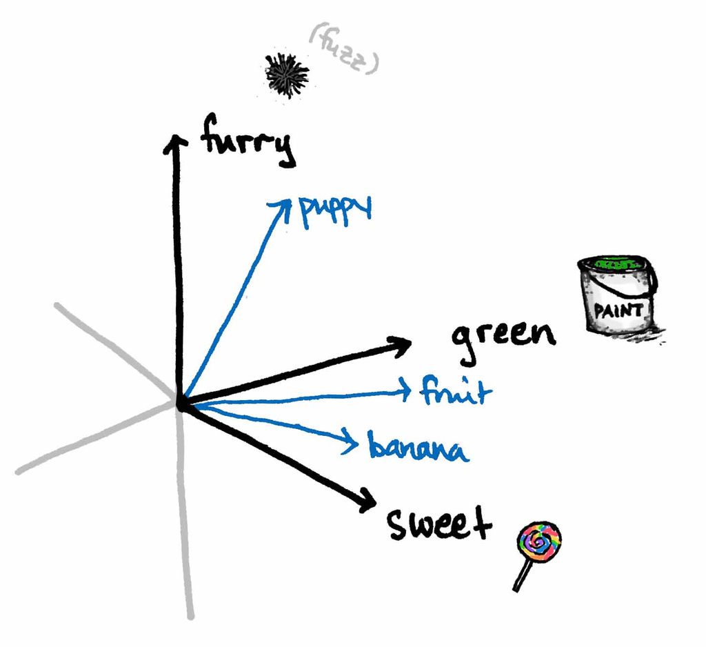

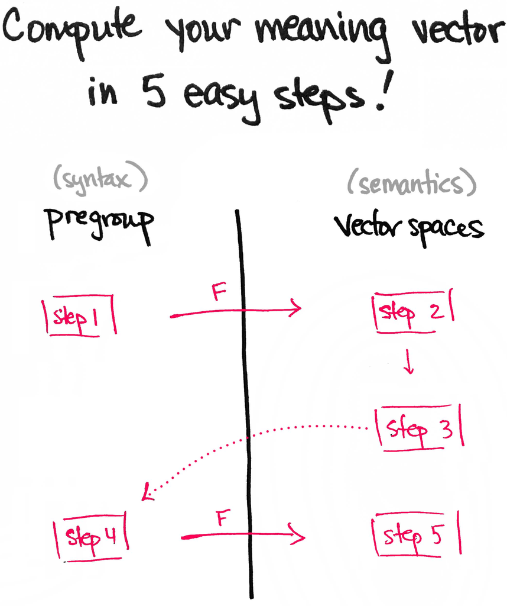

[^72]: 得到恒等矩阵并不奇怪。“是”所关乎的正是同一性。也就是说，动词 are 告诉你，什么时候某个东西就是另一个东西。

    It’s no surprise that we get the identity matrix. *Being* is all about identity. That is, the verb *are* tells you when something IS something else.